*Note: These are notes live-tex’d from a graduate course in 4-Manifolds taught by Philip Engel at the University of Georgia in Spring 2021. As such, any errors or inaccuracies are almost certainly my own.*

# 4-Manifolds

Lectures by Philip Engel. University of Georgia, Spring 2021

D. Zack Garza

University of Georgia  
dzackgarza@gmail.com

Last updated: 2021-04-12

# 1 Tuesday, January 12

## 1.1 Background

From Phil’s email:

There are very few references in the notes, and I’ll try to update them to include more as we go. Personally, I found the following online references particularly useful:

- Dietmar Salamon: Spin Geometry and Seiberg-Witten Invariants [1]
- Richard Mandelbaum: Four-dimensional Topology: An Introduction [2]
  - This book has a nice introduction to surgery aspects of four-manifolds, but as a warning: It was published right before Freedman’s famous theorem. For instance, the existence of an exotic R^4 was not known. This actually makes it quite useful, as a summary of what was known before, and provides the historical context in which Freedman’s theorem was proven.
- Danny Calegari: Notes on 4-Manifolds [3]
- Yuli Rudyak: Piecewise Linear Structures on Topological Manifolds [4]
- Akhil Mathew: The Dirac Operator [5]
- Tom Weston: An Introduction to Cobordism Theory [6]

  A wide variety of lecture notes on the Atiyah-Singer index theorem, which are available online.

## 1.2 Introduction

Recall that a **topological manifold** (or $C^0$ manifold) $X$ is a Hausdorff topological space *locally homeomorphic* to ${\mathbb{R}}^n$ with a countable topological base, so we have charts $\phi_u: U\to {\mathbb{R}}^n$ which are homeomorphisms from open sets covering $X$.

$S^1$ is covered by two charts homeomorphic to intervals:

[figure not shown]

Maps that are merely continuous are poorly behaved, so we may want to impose extra structure. This can be done by imposing restrictions on the transition functions, defined as
$$\begin{align*}
t_{uv} \mathrel{\vcenter{:}}=\varphi_V \to \varphi_U ^{-1} : \varphi_U(U \cap V) \to \varphi_V(U \cap V)
.\end{align*}$$

- We say $X$ is a **PL manifold** if and only if $t_{UV}$ are piecewise-linear. Note that an invertible PL map has a PL inverse.
- We say $X$ is a **$C^k$ manifold** if they are $k$ times continuously differentiable, and **smooth** if infinitely differentiable.
- We say $X$ is **real-analytic** if they are locally given by convergent power series.
- We say $X$ is **complex-analytic** if under the identification ${\mathbb{R}}^n \cong {\mathbb{C}}^{n/2}$ if they are holomorphic, i.e. the differential of $t_{UV}$ is complex linear.
- We say $X$ is a **projective variety** if it is the vanishing locus of homogeneous polynomials on ${\mathbb{CP}}^N$.

Is this a strictly increasing hierarchy? It’s not clear e.g. that every $C^k$ manifold is PL.

Consider ${\mathbb{R}}^n$ as a topological manifold: are any two smooth structures on ${\mathbb{R}}^n$ diffeomorphic?

Fix a copy of ${\mathbb{R}}$ and form a single chart ${\mathbb{R}}\xrightarrow{\operatorname{id}} {\mathbb{R}}$. There is only a single transition function, the identity, which is smooth. But consider
$$\begin{align*}
X &\to {\mathbb{R}}\\
t &\mapsto t^3
.\end{align*}
This is also a smooth structure on \(X\), since the transition function is the identity. This yields a different smooth structure, since these two charts don’t like in the same maximal atlas. Otherwise there would be a transition function of the form \(t_{VU}: t\mapsto t^{1/3}\), which is not smooth at zero. However, the map
\begin{align*}
X &\to X \\
t &\mapsto t^3
.\end{align*}
defines a diffeomorphism between the two smooth structures.$$

${\mathbb{R}}$ admits a unique smooth structure.

Let $\tilde {\mathbb{R}}$ be some exotic ${\mathbb{R}}$, i.e. a smooth manifold homeomorphic to ${\mathbb{R}}$. Cover this by coordinate charts to the standard ${\mathbb{R}}$:

[figure not shown]

There exists a cover which is *locally finite* and supports a *partition of unity*: a collection of smooth functions $f_i: U_i \to {\mathbb{R}}$ with $f_i \geq 0$ and ${\operatorname{supp}}f \subseteq U_i$ such that $\sum f_i = 1$ (*i.e., bump functions*). It is also a purely topological fact that $\tilde {\mathbb{R}}$ is orientable.

So we have bump functions:

[figure not shown]

Take a smooth vector field $V_i$ on $U_i$ everywhere aligning with the orientation. Then $\sum f_i V_i$ is a smooth nowhere vector field on $X$ that is nowhere zero in the direction of the orientation. Taking the associated flow
$$\begin{align*}
{\mathbb{R}}&\to \tilde {\mathbb{R}}\\
t &\mapsto \varphi(t)
.\end{align*}
such that \(\varphi'(t) = V(\varphi(t))\). Then \(\varphi\) is a smooth map that defines a diffeomorphism. This follows from the fact that the vector field is everywhere positive.$$

To understand smooth structures on $X$, we should try to solve differential equations on $X$.

Note that here we used the existence of a global frame, i.e. a trivialization of the tangent bundle, so this doesn’t quite work for e.g. $S^2$.

What is the difference between all of the above structures? Are there obstructions to admitting any particular one?

Kervaire-Milnor: $S^7$ admits 28 smooth structures, which form a group.

# 2 Friday, January 15

Let
$$\begin{align*}
V &\mathrel{\vcenter{:}}=\left\{{a^2 + b^2 + c^2 + d^3 + e^{6k-1} = 0}\right\} \subseteq {\mathbb{C}}^5 \\
S_\varepsilon&\mathrel{\vcenter{:}}=\left\{{ {\left\lvert {a} \right\rvert}^2 + {\left\lvert {b} \right\rvert}^2 + {\left\lvert {c} \right\rvert}^2 + {\left\lvert {d} \right\rvert}^2 + {\left\lvert {e} \right\rvert}^2}\right\}
.\end{align*}
Then \(V_k \cap S_\varepsilon\cong S^7\) is a homeomorphism, and taking \(k=1,2,\cdots, 28\) yields the 28 smooth structures on \(S^7\). Note that \(V_k\) is the cone over \(V_k \cap S_\varepsilon\).$$

[figure not shown]

Is every triangulable manifold PL, i.e. homeomorphic to a simplicial complex?

No! Given a simplicial complex, there is a notion of the **combinatorial link** $L_V$ of a vertex $V$:

[figure not shown]

It turns out that there exist simplicial manifolds such that the link is not homeomorphic to a sphere, whereas every PL manifold admits a “PL triangulation” where the links are spheres.

What’s special in dimension 4? Recall the **Kirby-Siebenmann** invariant $\operatorname{ks}(x) \in H^4(X; {\mathbb{Z}}_2)$ for $X$ a topological manifold where $\operatorname{ks}(X) = 0 \iff X$ admits a PL structure, with the caveat that $\dim X \geq 5$. We can use this to cook up an invariant of 4-manifolds.

Let $X$ be a topological 4-manifold, then
$$\begin{align*}
\operatorname{ks}(X) \mathrel{\vcenter{:}}=\operatorname{ks}(X \times{\mathbb{R}})
.\end{align*}$$

$\operatorname{ks}(X) \neq 0$ implies that $X$ has no smooth structure, since $X \times{\mathbb{R}}$ doesn’t. Note that it was not known if this invariant was nonzero for a while!

Note that $H^2(X; {\mathbb{Z}})$ admits a symmetric bilinear form $Q_X$ defined by
$$\begin{align*}
{\left\langle { \alpha},~{ \beta} \right\rangle} \mapsto \int_X \alpha\wedge \beta = \alpha \smile\beta([X]) \in {\mathbb{Z}}
.\end{align*}
where \([X]\) is the fundamental class.$$

# 3 Main Theorems for the Course

Proving the following theorems is the main goal of this course.

If $X, Y$ are compact oriented topological 4-manifolds, then $X\cong Y$ are homeomorphic if and only if $\operatorname{ks}(X) = \operatorname{ks}(Y)$ and $Q_X \cong Q_Y$ are isometric, i.e. there exists an isometry
$$\begin{align*}
\varphi: H^2(X; {\mathbb{Z}}) \to H^2(Y; {\mathbb{Z}})
.\end{align*}
that preserves the two bilinear forms in the sense that \({\left\langle {\varphi \alpha},~{ \varphi \beta} \right\rangle} = {\left\langle { \alpha},~{ \beta} \right\rangle}\).$$

Conversely, every **unimodular** bilinear form appears as $H^2(X; {\mathbb{Z}})$ for some $X$, i.e. the pairing induces a map
$$\begin{align*}
H^2(X; {\mathbb{Z}}) &\to H^2(X; {\mathbb{Z}})^\vee\\
\alpha \mapsto {\left\langle { \alpha },~{ {\,\cdot\,}} \right\rangle}
.\end{align*}
which is an isomorphism. This is essentially a classification of simply-connected 4-manifolds.$$

Note that preservation of a bilinear form is a stand-in for “being an element of the orthogonal group,” where we only have a lattice instead of a full vector space.

There is a map $H^2(X; {\mathbb{Z}}) \xrightarrow{PD} H_2(X; {\mathbb{Z}})$ from Poincaré , where we can think of elements in the latter as closed surfaces $[\Sigma]$, and \begin{align*} {\left\langle { \Sigma_1 },~{ \Sigma_2 } \right\rangle} = \text{signed number of intersections points of } \Sigma_1 \pitchfork\Sigma_2 .\end{align*} Note that Freedman’s theorem is only about homeomorphism, and is not true smoothly. This gives a way to show that two 4-manifolds are homeomorphic, but this is hard to prove! So we’ll black-box this, and focus on ways to show that two *smooth* 4-manifolds are *not* diffeomorphic, since we want homeomorphic but non-diffeomorphic manifolds.

The **signature** of a topological 4- manifold is the signature of $Q_X$, where we note that $Q_X$ is a symmetric nondegenerate bilinear form on $H^2(X; {\mathbb{R}})$ and for some $a, b$
$$\begin{align*}
(H^2(X; {\mathbb{R}}), Q_x) \xrightarrow{\text{isometric}} {\mathbb{R}}^{a, b}
.\end{align*}
where \(a\) is the number of \(+1\)s appearing in the matrix and \(b\) is the number of \(-1\)s. This is \({\mathbb{R}}^{ab}\) where \(e_i^2 = 1, i=1\cdots a\) and \(e_i^2 = -1, i=a+1, \cdots b\), and is thus equipped with a specific bilinear form corresponding to the Gram matrix of this basis.
\begin{align*}
\begin{bmatrix}
1 & 0 & 0 & 0 & 0
\\
0 & 1 & 0 & 0 & 0
\\
0 & 0 & \ddots & 0 & 0
\\
0 & 0 & 0 & -1 & 0
\\
0 & 0 & 0 & 0 & -1
\end{bmatrix}
= I_{a\times a} \oplus -I_{b \times b}
.\end{align*}
Then the signature is \(a-b\), the dimension of the positive-definite space minus the dimension of the negative-definite space.$$

Suppose ${\left\langle { \alpha},~{\alpha} \right\rangle} \in 2{\mathbb{Z}}$ and $\alpha\in H^2(X; {\mathbb{Z}})$ and $X$ a simply connected **smooth** 4-manifold. Then 16 divides $\operatorname{sig}(X)$.

Note that Freedman’s theorem implies that there exists topological 4-manifolds with no smooth structure.

Let $X$ be a smooth simply-connected 4-manifold. If $a=0$ or $b=0$, then $Q_X$ is diagonalizable and there exists an orthonormal basis of $H^2(X; {\mathbb{Z}})$.

This comes from Gram-Schmidt, and restricts what types of intersection forms can occur.

## 3.1 Warm Up: ${\mathbb{R}}^2$ Has a Unique Smooth Structure

Last time we showed ${\mathbb{R}}^1$ had a unique smooth structure, so now we’ll do this for ${\mathbb{R}}^2$. The strategy of solving a differential equation, we’ll now sketch the proof.

A **Riemannian metric** $g\in \operatorname{Sym}^2 T^*X$ for $X$ a smooth manifold is a metric on every $T_p X$ given by
$$\begin{align*}
g_p: T_pX \times T_p X &\to {\mathbb{R}}\\
g(v, v) \geq 0, g(v,v) = 0 \iff v=0
.\end{align*}$$

An **almost complex structure** is a $J\in \mathop{\mathrm{End}}(TX)$ such that $J^2 = -\operatorname{id}$.

Let $e\in T_p X$ and $e\neq 0$, then if $X$ is a surface then $\left\{{e, Je}\right\}$ is a basis of $T_p X$.

[figure not shown]

This is a basis because if $Je$ and $e$ are parallel, then ??? In particular, $J_p$ is determined by a point in ${\mathbb{R}}^2\setminus\left\{{\text{the }x{\hbox{-}}\text{axis}}\right\}$

### 3.1.1 Sketch of Proof

Let $\tilde {\mathbb{R}}^2$ be an exotic ${\mathbb{R}}^2$.

#### 3.1.1.1 Step 1

Choose a metric on $\tilde {\mathbb{R}}^2$ $g \mathrel{\vcenter{:}}=\sum f_I g_i$ with $g_i$ metrics on coordinate charts $U_i$ and $f_i$ a partition of unity.

#### 3.1.1.2 Step 2

Find an almost complex structure on $\tilde {\mathbb{R}}^2$. Choosing an orientation of $\tilde {\mathbb{R}}^2$, $g$ defines a unique almost complex structure $J_p e \mathrel{\vcenter{:}}= f\in T_p \tilde {\mathbb{R}}^2$ such that

- $g(e, e) = g(f, f)$
- $g(e, f) = 0$.
- $\left\{{e, f}\right\}$ is an oriented basis of $T_p \tilde {\mathbb{R}}^2$

This is because after choosing $e$, there are two orthogonal vectors, but only one choice yields an *oriented* basis.

[figure not shown]

#### 3.1.1.3 Step 3

We then apply a theorem:

Any almost complex structure on a surface comes from a complex structure, in the sense that there exist charts $\varphi_i: U_i \to {\mathbb{C}}$ such that $J$ is multiplication by $i$.

So $d \varphi(J \cdot e) = i \cdot d \varphi_i (e)$, and $(\tilde {\mathbb{R}}^2, J)$ is a complex manifold. Since it’s simply connected, the Riemann Mapping Theorem shows that it’s biholomorphic to ${\mathbb{D}}$ or ${\mathbb{C}}$, both of which are diffeomorphic to ${\mathbb{R}}^2$.

> See the Newlander-Nirenberg theorem, a result in complex geometry.

# 4 Lecture 3 (Wednesday, January 20)

Today: some background material on sheaves, bundles, connections.

## 4.1 Sheaves

Recall that if $X$ is a topological space, a **presheaf** of abelian groups $\mathcal{F}$ is an assignment $U\to \mathcal{F}(U)$ of an abelian group to every open set $U \subseteq X$ together with a restriction map $\rho_{UV}: \mathcal{F}(U) \to \mathcal{F}(V)$ for any inclusion $V \subseteq U$ of open sets. This data has to satisfying certain conditions:

1. $\mathcal{F}(\emptyset) = 0$, the trivial abelian group.
2. $\rho_{UU}: \mathcal{F}(U) \to \mathcal{F}(U) = \operatorname{id}_{\mathcal{F}(U) }$
3. Compatibility if restriction is taken in steps: $U \subseteq V \subseteq W \implies \rho_{VW} \circ \rho_{UV} = \rho_{UW}$.

We say $\mathcal{F}$ is a **sheaf** if additionally:

4. Given $s_i \in \mathcal{F}(U_i)$ such that $\rho_{U_i \cap U_j} (s_i) = \rho_{U_i \cap U_j} (s_j)$ implies that there exists a unique $s\in \mathcal{F}(\bigcup_i U_i)$ such that $\rho_{U_i}(s) = s_i$.

[figure not shown]

Let $X$ be a topological manifold, then $\mathcal{F}\mathrel{\vcenter{:}}= C^0({\,\cdot\,}, {\mathbb{R}})$ the set of continuous functionals form a sheaf. We have a diagram

[figure not shown]

> Link to diagram

Property (d) holds because given sections $s_i \in C^0(U_i; {\mathbb{R}})$ agreeing on overlaps, so ${ \left.{{s_i}} \right|_{{U_i \cap U_j}} } = { \left.{{s_j}} \right|_{{U_i \cap U_j}} }$, there exists a unique $s\in C^0(\bigcup_i U_i; {\mathbb{R}})$ such that ${ \left.{{s}} \right|_{{U_i}} } = s_i$ for all $i$ – continuous functions glue.

Recall that we discussed various structures on manifolds: PL, continuous, smooth, complex-analytic, etc. We can characterize these by their sheaves of functions, which we’ll denote ${\mathcal{O}}$. For example, ${\mathcal{O}}\mathrel{\vcenter{:}}= C^0({\,\cdot\,}; {\mathbb{R}})$ for topological manifolds, and ${\mathcal{O}}\mathrel{\vcenter{:}}= C^ \infty ({\,\cdot\,}; {\mathbb{R}})$ is the sheaf for smooth manifolds. Note that this also works for PL functions, since pullbacks of PL functions are again PL. For complex manifolds, we set ${\mathcal{O}}$ to be the sheaf of holomorphic functions.

Let $A\in {\mathsf{Ab}}$ be an abelian group, then $\underline{A}$ is the sheaf defined by setting $\underline{A}(U)$ to be the locally constant functions $U\to A$. E.g. let $X \in {\mathsf{Mfd}}_{{\mathsf{Top}}}$ be a topological manifold, then $\underline{{\mathbb{R}}}(U) = {\mathbb{R}}$ if $U$ is connected since locally constant $\implies$ globally constant in this case.

Note that the presheaf of constant functions doesn’t satisfy (d)! Take ${\mathbb{R}}$ and a function with two different values on disjoint intervals:

[figure not shown]

Note that ${ \left.{{s_1}} \right|_{{U_1 \cap U_2}} } = { \left.{{s_2}} \right|_{{U_1 \cap U_2}} }$ since the intersection is empty, but there is no constant function that restricts to the two different values.

## 4.2 Bundles

Let $\pi: \mathcal{E}\to X$ be a **vector bundle**, so we have local trivializations $\pi ^{-1} (U) \xrightarrow{h_u} Y^d \times U$ where we take either $Y={\mathbb{R}}, {\mathbb{C}}$, such that $h_v \circ h_u ^{-1}$ preserves the fibers of $\pi$ and acts linearly on each fiber of $Y\times(U \cap V)$. Define
$$\begin{align*}
t_{UV}: U \cap V \to \operatorname{GL}_d(Y)
\end{align*}
where we require that \(t_{UV}\) is continuous, smooth, complex-analytic, etc depending on the context.$$

[figure not shown]

There are two ${\mathbb{R}}^1$ bundles over $S^1$:

[figure not shown]

Note that the Mobius bundle is not trivial, but can be locally trivialized.

We abuse notation: $\mathcal{E}$ is also a sheaf, and we write $\mathcal{E}(U)$ to be the set of sections $s: U\to \mathcal{E}$ where $s$ is continuous, smooth, holomorphic, etc where $\pi \circ s = \operatorname{id}_U$. I.e. a bundle is a sheaf in the sense that its sections *form* a sheaf.

The trivial line bundle gives the sheaf ${\mathcal{O}}$ : maps $U \xrightarrow{s} U\times Y$ for $Y={\mathbb{R}}, {\mathbb{C}}$ such that $\pi \circ s = \operatorname{id}$ are the same as maps $U\to Y$.

An **${\mathcal{O}}{\hbox{-}}$module** is a sheaf $\mathcal{F}$ such that $\mathcal{F}(U)$ has an action of $\mathcal{O}(U)$ compatible with restriction.

If $\mathcal{E}$ is a vector bundle, then $\mathcal{E}(U)$ has a natural action of ${\mathcal{O}}(U)$ given by $f\curvearrowright s \mathrel{\vcenter{:}}= fs$, i.e. just multiplying functions.

The locally constant sheaf $\underline{{\mathbb{R}}}$ is not an ${\mathcal{O}}{\hbox{-}}$module: there isn’t natural action since the sections of ${\mathcal{O}}$ are generally non-constant functions, and multiplying a constant function by a non-constant function doesn’t generally give back a constant function.

We’d like a notion of maps between sheaves:

A **morphism** of sheaves $\mathcal{F} \to \mathcal{G}$ is a group morphism $\varphi(U): \mathcal{F}(U) \to \mathcal{G}(U)$ for all opens $U \subseteq X$ such that the diagram involving restrictions commutes:

[figure not shown]

Let $X = {\mathbb{R}}$ and define the **skyscraper sheaf** at $p \in {\mathbb{R}}$ as
$$\begin{align*}
{\mathbb{R}}_p(U) \mathrel{\vcenter{:}}=
\begin{cases}
{\mathbb{R}}& p\in U
\\
0 & p\not\in U.
\end{cases}
.\end{align*}$$

The ${\mathcal{O}}(U){\hbox{-}}$module structure is given by
$$\begin{align*}
{\mathcal{O}}(U) \times{\mathcal{O}}(U) &\to {\mathbb{R}}_p(U) \\
(f, s) &\mapsto f(p) s
.\end{align*}
This is not a vector bundle since \({\mathbb{R}}_p(U)\) is not an infinite dimensional vector space, whereas the space of sections of a vector bundle is generally infinite dimensional (?). Alternatively, there are arbitrarily small punctured open neighborhoods of \(p\) for which the sheaf makes trivial assignments.$$

Let $X = {\mathbb{R}}\in {\mathsf{Mfd}}_{\operatorname{Sm}}$ viewed as a smooth manifold, then multiplication by $x$ induces a morphism of structure sheaves:
$$\begin{align*}
(x \cdot): {\mathcal{O}}&\to {\mathcal{O}}\\
s & \mapsto x\cdot s
\end{align*}
for any \(x\in {\mathcal{O}}(U)\), noting that \(x\cdot s\in {\mathcal{O}}(U)\) again.$$

Check that $\ker \varphi$ is naturally a sheaf and $\ker(\varphi)(U) = \ker (\varphi(U)): \mathcal{F}(U) \to \mathcal{G}(U)$

Here the kernel is trivial, i.e. on any open $U$ we have $(x\cdot):{\mathcal{O}}(U) \hookrightarrow{\mathcal{O}}(U)$ is injective. Taking the cokernel $\operatorname{coker}(x\cdot)$ as a presheaf, this assigns to $U$ the quotient presheaf ${\mathcal{O}}(U) / x{\mathcal{O}}(U)$, which turns out to be equal to ${\mathbb{R}}_0$. So ${\mathcal{O}}\to {\mathbb{R}}_0$ by restricting to the value at $0$, and there is an exact sequence
$$\begin{align*}
0 \to {\mathcal{O}}\xrightarrow{(x\cdot)} {\mathcal{O}}\to {\mathbb{R}}_0 \to 0
.\end{align*}$$

This is one reason sheaves are better than vector bundles: the category is closed under taking quotients, whereas quotients of vector bundles may not be vector bundles.

# 5 Lecture 4 (Friday, January 22)

## 5.1 The Exponential Exact Sequence

Let $X = {\mathbb{C}}$ and consider ${\mathcal{O}}$ the sheaf of holomorphic functions and ${\mathcal{O}}^{\times}$ the sheaf of *nonvanishing* holomorphic functions. The former is a vector bundle and the latter is a sheaf of abelian groups. There is a map $\exp: {\mathcal{O}}\to {\mathcal{O}}^{\times}$, the **exponential map**, which is the data $\exp(U): {\mathcal{O}}(U) \to {\mathcal{O}}^{\times}(U)$ on every open $U$ given by $f\mapsto e^f$. There is a kernel sheaf $2\pi i \underline{{\mathbb{Z}}}$, and we get an exact sequence
$$\begin{align*}
0 \to 2\pi i \underline{{\mathbb{Z}}} \to {\mathcal{O}}\xrightarrow{\exp} {\mathcal{O}}^{\times}\to \operatorname{coker}(\exp) \to 0
.\end{align*}$$

What is the cokernel sheaf here?

Let $U$ be a contractible open set, then we can identify ${\mathcal{O}}^{\times}(U) / \exp({\mathcal{O}}^{\times}(U)) = 1$.

[figure not shown]

Any $f\in {\mathcal{O}}^{\times}(U)$ has a logarithm, say by taking a branch cut, since $\pi_1(U) =0 \implies \log f$ has an analytic continuation. Consider the annulus $U$ and the function $z\in {\mathcal{O}}^{\times}(U)$, then $z\not\in \exp({\mathcal{O}}(U))$ – if $z=e^f$ then $f=\log(z)$, but $\log(z)$ has monodromy on $U$:

[figure not shown]

Thus on any sufficiently small open set, $\operatorname{coker}(\exp) = 1$. This is only a presheaf: there exists an open cover of the annulus for which ${ \left.{{z}} \right|_{{U_i}} }$, and so the naive cokernel doesn’t define a sheaf. This is because we have a locally trivial section which glues to $z$, which is nontrivial.

Redefine the cokernel so that it is a sheaf. Hint: look at sheafification, which has the defining property ${\operatorname{Hom}}_{{\mathsf{Presh}}}(\mathcal{G}, \mathcal{F}^{\mathsf{Presh}}) ={\operatorname{Hom}}_{{\mathsf{Sh}}}( \mathcal{G}, \mathcal{F}^{{\mathsf{Sh}}})$ for any sheaf $\mathcal{G}$.

The **global sections** sheaf of $\mathcal{F}$ on $X$ is given by $H^0( X; \mathcal{F}) = \mathcal{F}(X)$.

- $C^ \infty (X) = H^0(X, C^ \infty )$ are the smooth functions on $X$
- $VF(X) = H^0(X; T)$ are the smooth vector fields on $X$ for $T$ the tangent bundle
- If $X$ is a complex manifold then ${\mathcal{O}}(X) = H^0(X; {\mathcal{O}})$ are the globally holomorphic functions on $X$.
- $H^0(X; {\mathbb{Z}}) = \underline{{\mathbb{Z}}}(X)$ are ??

Given vector bundles $V, W$, we have constructions $V \oplus W, V \otimes W, V^\vee, {\operatorname{Hom}}(V, W) = V^\vee\otimes W, \operatorname{Sym}^n V, \bigwedge^p V$, and so on. Some of these work directly for sheaves:

- $\mathcal{F} \oplus \mathcal{G}(U) \mathrel{\vcenter{:}}=\mathcal{F}(U) \oplus \mathcal{G}(U)$
- For tensors, duals, and homs $\mathscr{H}\kern-2pt\operatorname{om}(V, W)$ we only get presheaves, so we need to sheafify.

${\operatorname{Hom}}(V, W)$ will denote the *global* homomorphisms $\mathscr{H}\kern-2pt\operatorname{om}(V, W)(X)$, which is a sheaf.

Let $X^n \in {\mathsf{Mfd}}_{{\operatorname{sm}}}$ and let $\Omega^p$ be the sheaf of smooth $p{\hbox{-}}$forms, i.e $\bigwedge^p T^\vee$, i.e. $\Omega^p(U)$ are the smooth $p$ forms on $U$, which are locally of the form $\sum f_{i_1, \cdots, i_p} (x_1, \cdots, x_n) dx_{i_1} \wedge dx_{i_2} \wedge \cdots dx_{i_p}$ where the $f_{i_1, \cdots, i_p}$ are smooth functions.

Take $X= S^1$, writing this as ${\mathbb{R}}/{\mathbb{Z}}$, we have $\Omega^1(X) \ni dx$. There are two coordinate charts which differ by a translation on their overlaps, and $dx(x + c) =dx$ for $c$ a constant:

[figure not shown]

Check that on a torus, $dx_i$ is a well-defined 1-form.

Note that there is a map $d: \Omega^p \to \Omega^{p+1}$ where $\omega\mapsto d \omega$.

$d$ is **not** a map of ${\mathcal{O}}{\hbox{-}}$modules: $d(f\cdot \omega) = f\cdot \omega + {\color{red} df \wedge \omega}$, where the latter is a correction term. In particular, it is not a map of vector bundles, but is a map of sheaves of abelian groups since $d ( \omega_1 + \omega_2) = d( \omega_1 ) + d ( \omega_2)$, making $d$ a sheaf morphism.

Let $X \in {\mathsf{Mfd}}_{\mathbb{C}}$, we’ll use the fact that $TX$ is complex-linear and thus a ${\mathbb{C}}{\hbox{-}}$vector bundle.

[figure not shown]

Note that $\Omega^p$ for complex manifolds is $\bigwedge^p T^\vee$, and so if we want to view $X \in {\mathsf{Mfd}}_{\mathbb{R}}$ we’ll write $X_{{\mathbb{R}}}$. $TX_{\mathbb{R}}$ is then a real vector bundle of rank $2n$.

$\Omega^p$ will denote *holomorphic* $p{\hbox{-}}$forms, i.e. local expressions $\sum f_I(z_1, \cdots, z_n) \bigwedge dz_I$. For example, $e^zdz\in \Omega^1({\mathbb{C}})$ but $z\mkern 1.5mu\overline{\mkern-1.5muz\mkern-1.5mu}\mkern 1.5mu dz$ is not, where $dz = dx + idy$. We’ll use a different notation when we allow the $f_I$ to just be smooth: $A^{p, 0}$, the sheaf of $(p, 0){\hbox{-}}$forms. Then $z\mkern 1.5mu\overline{\mkern-1.5muz\mkern-1.5mu}\mkern 1.5mu dz\in A^{1, 0}$.

Note that $T^\vee X_{\mathbb{R}}\otimes _{\mathbb{C}}= A^{1, 0} \oplus A^{0, 1}$ since there is a unique decomposition $\omega = fdz + gd\mkern 1.5mu\overline{\mkern-1.5muz\mkern-1.5mu}\mkern 1.5mu$ where $f,g$ are smooth. Then $\Omega^d X_{\mathbb{R}}\otimes_{\mathbb{R}}{\mathbb{C}}= \bigoplus _{p+q=d} A^{p, q}$. Note that $\Omega_{\setminus}^p \neq A^{p, q}$ and these are really quite different: the former are more like holomorphic bundles, and the latter smooth. Moreover $\dim \Omega^p(X) < \infty$, whereas $\Omega_{\setminus}^1$ is infinite-dimensional.

# 6 Principal $G{\hbox{-}}$Bundles and Connections (Monday, January 25)

Let $G$ be a (possibly disconnected) Lie group. Then a **principal $G{\hbox{-}}$bundle** $\pi:P\to X$ is a space admitting local trivializations $h_u: \pi ^{-1} (U) \to G \times U$ such that the transition functions are given by left multiplication by a continuous function $t_{UV}: U \cap V \to G$.

[figure not shown]

Setup: we’ll consider $TX$ for $X\in {\mathsf{Mfd}}_{\operatorname{Sm}}$, and let $g$ be a metric on the tangent bundle given by
$$\begin{align*}
g_p: T_pX^{\otimes 2} \to {\mathbb{R}}
,\end{align*}
a symmetric bilinear form with \(g_p(u, v) \geq 0\) with equality if and only if \(v=0\).$$

Define ${\operatorname{Frame}}_p(X) \mathrel{\vcenter{:}}=\left\{{\text{bases of } T_p X}\right\}$, and ${\operatorname{Frame}}X \mathrel{\vcenter{:}}=\bigcup_{p\in X} {\operatorname{Frame}}_p X$.

More generally, ${\operatorname{Frame}}\mathcal{E}$ can be defined for any vector bundle $\mathcal{E}$, so ${\operatorname{Frame}}X \mathrel{\vcenter{:}}={\operatorname{Frame}}TX$. Note that ${\operatorname{Frame}}X$ is a principal $\operatorname{GL}_n({\mathbb{R}}){\hbox{-}}$bundle where $n\mathrel{\vcenter{:}}=\operatorname{rank}(\mathcal{E})$. This follows from the fact that the transition functions are fiberwise in $\operatorname{GL}_n({\mathbb{R}})$, so the transition functions are given by left-multiplication by matrices.

A principal $G{\hbox{-}}$bundle admits a $G{\hbox{-}}$action where $G$ acts by *right* multiplication:
$$\begin{align*}
P \times G \to P \\
( (g, x), h) \mapsto (gh, x)
.\end{align*}
This is necessary for compatibility on overlaps. Key point: the actions of left and right multiplication commute.$$

The **orthogonal frame bundle** of a vector bundle $\mathcal{E}$ equipped with a metric $g$ is defined as ${\operatorname{OFrame}}_p \mathcal{E}\mathrel{\vcenter{:}}=\left\{{\text{orthonormal bases of } \mathcal{E}_p}\right\}$, also written $O_r({\mathbb{R}})$ where $r \mathrel{\vcenter{:}}=\operatorname{rank}( \mathcal{E})$.

The fibers $P_x \to \left\{{x}\right\}$ of a principal $G{\hbox{-}}$bundle are naturally **torsors** over $G$, i.e. a set with a free transitive $G{\hbox{-}}$action.

Let $\mathcal{E}\to X$ be a complex vector bundle. Then a **hermitian metric** is a hermitian form on every fiber, i.e.
$$\begin{align*}
h_p: \mathcal{E}_p \times\overline{\mathcal{E}_p } \to {\mathbb{C}}
.\end{align*}
where \(h_p(v, \mkern 1.5mu\overline{\mkern-1.5muv\mkern-1.5mu}\mkern 1.5mu ) \geq 0\) with equality if and only if \(v=0\). Here we define \(\overline{\mathcal{E}_p}\) as the fiber of the complex vector bundle \(\overline{\mathcal{E}}\) whose transition functions are given by the complex conjugates of those from \(\mathcal{E}\).$$

Note that $\mathcal{E}, \overline{\mathcal{E}}$ are genuinely different as complex bundles. There is a *conjugate-linear* map given by conjugation, i.e. $L(cv) = \mkern 1.5mu\overline{\mkern-1.5muc\mkern-1.5mu}\mkern 1.5mu L(v)$, where the canonical example is
$$\begin{align*}
{\mathbb{C}}^n &\to {\mathbb{C}}^n \\
(z_1, \cdots, z_n) &\mapsto (\mkern 1.5mu\overline{\mkern-1.5muz_1\mkern-1.5mu}\mkern 1.5mu, \cdots, \mkern 1.5mu\overline{\mkern-1.5muz_n\mkern-1.5mu}\mkern 1.5mu)
.\end{align*}$$

We define the **unitary frame bundle** ${\operatorname{UFrame}}(\mathcal{E}) \mathrel{\vcenter{:}}=\bigcup_p {\operatorname{UFrame}}(\mathcal{E})_p$, where at each point this is given by the set of orthogonal frames of $\mathcal{E}_p$ given by $(e_1, \cdots, e_n)$ where $h(e_i , \mkern 1.5mu\overline{\mkern-1.5mue_j\mkern-1.5mu}\mkern 1.5mu ) = \delta_{ij}$.

This is a principal $G{\hbox{-}}$bundle for $G = U_r({\mathbb{C}})$, the invertible matrices $A_{/{\mathbb{C}}}$ satisfy $A \overline{A}^t = \operatorname{id}$.

For $G={\mathbb{Z}}/2{\mathbb{Z}}$ and $X= S^1$, the Möbius band is a principal $G{\hbox{-}}$bundle:

[figure not shown]

For $G={\mathbb{Z}}/2{\mathbb{Z}}$, for any (possibly non-oriented) manifold $X$ there is an **orientation principal bundle** $P$ which is locally a set of orientations on $U$, i.e.
$$\begin{align*}
P\mathrel{\vcenter{:}}=\left\{{(x, O) {~\mathrel{\Big|}~}x\in X,\, O \text{ is an orientation of }T_p X}\right\}
.\end{align*}
Note that \(P\) is an oriented manifold, \(P\to X\) is a local isomorphism, and has a canonical orientation. (?) This can also be written as \(P = {\operatorname{Frame}}X / \operatorname{GL}_n^+({\mathbb{R}})\), since an orientation can be specified by a choice of \(n\) linearly independent vectors where we identify any two sets that differ by a matrix of positive determinant.$$

Let $P\to X$ be a principal $G{\hbox{-}}$bundle and let $G\to \operatorname{GL}(V)$ be a continuous representation. The **associated bundle** is defined as
$$\begin{align*}
P\times_G V = \left\{{(p, v){~\mathrel{\Big|}~}p\in P,\, v\in V}\right\} / \sim && \text{where } (p, v) \sim (pg, g ^{-1} v)
,\end{align*}
which is well-defined since there is a right action on the first component and a left action on the second.$$

Note that ${\operatorname{Frame}}(\mathcal{E})$ is a $\operatorname{GL}_r({\mathbb{R}}){\hbox{-}}$bundle and the map $\operatorname{GL}_r({\mathbb{R}}) \xrightarrow{\operatorname{id}} \operatorname{GL}({\mathbb{R}}^r)$ is a representation. At every fiber, we have $G \times_G V = (p, v)/\sim$ where there is a unique representative of this equivalence class given by $(e, pv)$. So $P\times_G V_p \to \left\{{p}\right\} \cong V_x$.

Show that ${\operatorname{Frame}}( \mathcal{E}) \times_{\operatorname{GL}_r({\mathbb{R}})} {\mathbb{R}}^r \cong \mathcal{E}$. This follows from the fact that the transition functions of $P \times_G V$ are given by left multiplication of $t_{UV}: U \cap V \to G$, and so by the equivalence relation, $\operatorname{im}t_{UV} \in \operatorname{GL}(V)$.

Suppose that $M^3$ is an oriented Riemannian 3-manifold. Them $TM\to {\operatorname{Frame}}(M)$ which is a principal ${\operatorname{SO}}(3){\hbox{-}}$bundle. The universal cover is the double cover ${\operatorname{SU}}(2) \to {\operatorname{SO}}(3)$, so can the transition functions be lifted? This shows up for spin structures, and we can get a ${\mathbb{C}}^2$ bundle out of this.

# 7 Wednesday, January 27

## 7.1 Bundles and Connections

Let $\mathcal{E}\to X$ be a vector bundle, then a **connection** on $\mathcal{E}$ is a map of sheaves of abelian groups \begin{align*} \nabla: \mathcal{E}\to \mathcal{E}\otimes\Omega^1_X \end{align*} satisfying the *Leibniz rule*:
$$\begin{align*}
\nabla (fs) = f \nabla s + s\otimes ds
\end{align*}
for all opens \(U\) with \(f\in {\mathcal{O}}(U)\) and \(s\in \mathcal{E}(U)\). Note that this works in the category of complex manifolds, in which case \(\nabla\) is referred to as a holomorphic connection.$$

A connection $\nabla$ induces a map
$$\begin{align*}
\tilde{\nabla}: \mathcal{E}\otimes\Omega^p &\to \mathcal{E}\otimes\Omega^{p+1} \\
s \otimes \omega &\mapsto \nabla s \wedge w + s\otimes d \omega
.\end{align*}
where \(\wedge: \Omega^p \otimes\Omega^1 \to \Omega^{p+1}\). The standard example is
\begin{align*}
d: {\mathcal{O}}&\to \Omega^1 \\
f &\mapsto df
.\end{align*}
where the induced map is the usual de Rham differential.$$

Prove that the *curvature* of $\nabla$, i.e. the map
$$\begin{align*}
F_{\nabla} \mathrel{\vcenter{:}}=\nabla \circ \nabla: \mathcal{E}\to \mathcal{E}\otimes\Omega^2
\end{align*}
is \({\mathcal{O}}{\hbox{-}}\)linear, so \(F_{\nabla}(fs) = f\nabla \circ \nabla(s)\). Use the fact that \(\nabla s \in \mathcal{E}\otimes\Omega^1\) and \(\omega \in \Omega^p\) and so \(\nabla s \otimes \omega \in \mathcal{E} \Omega^1 \otimes \Omega^p\) and thus reassociating the tensor product yields \(\nabla s \wedge \omega \in \mathcal{E}\otimes\Omega^{p+1}\).$$

Why is this called a connection?

[figure not shown]

This gives us a way to transport $v\in \mathcal{E}_p$ over a path $\gamma$ in the base, and $\nabla$ provides a differential equation (a flow equation) to solve that lifts this path. Solving this is referred to as **parallel transport**. This works by pairing $\gamma'(t) \in T_{ \gamma(t) } X$ with $\Omega^1$, yielding $\nabla s = ( \gamma'(t)) = s( \gamma(t))$ which are sections of $\gamma$.

Note that taking a different path yields an endpoint in the same fiber but potentially at a different point, and $F_\nabla = 0$ if and only if the parallel transport from $p$ to $q$ depends only on the homotopy class of $\gamma$.

> Note: this works for any bundle, so can become confusing in Riemannian geometry when all of the bundles taken are tangent bundles!

The Levi-Cevita connection $\nabla^{LC}$ on $TX$, which depends on a metric $g$. Taking $X=S^2$ and $g$ is the round metric, there is nonzero curvature:

[figure not shown]

In general, every such transport will be rotation by some vector, and the angle is given by the area of the enclosed region.

A connection is **flat** if $F_\nabla = 0$. A section $s \in \mathcal{E}(U)$ is **flat** if it is given by
$$\begin{align*}
L(U) \mathrel{\vcenter{:}}=\left\{{ s\in \mathcal{E}(U) {~\mathrel{\Big|}~}\nabla s = 0}\right\}
.\end{align*}$$

Show that if $\nabla$ is flat then $L$ is a *local system*: a sheaf that assigns to any sufficiently small open set a vector space of fixed dimension. An example is the constant sheaf $\underline{{\mathbb{C}}^d}$. Furthermore ${\operatorname{rank}}(L) = {\operatorname{rank}}(\mathcal{E})$.

Given a local system, we can construct a vector bundle whose transition functions are the same as those of the local system, e.g. for vector bundles this is a fixed matrix, and in general these will be constant transition functions. Equivalently, we can take $L\otimes_{\mathbb{R}}{\mathcal{O}}$, and $L\otimes 1$ form flat sections of a connection.

## 7.2 Sheaf Cohomology

Let $\mathcal{F}$ be a sheaf of abelian groups on a topological space $X$, and let $\mathfrak{U} \mathrel{\vcenter{:}}=\left\{{U_i}\right\} \rightrightarrows X$ be an open cover of $X$. Let $U_{i_1, \cdots, i_p} \mathrel{\vcenter{:}}= U_{i_1} \cap U_{i_2} \cap\cdots \cap U_{i_p}$. Then the **Čech Complex** is defined as
$$\begin{align*}
C_{\mathfrak{U}}^p(X, \mathcal{F}) \mathrel{\vcenter{:}}=\prod_{i_1 < \cdots < i_p} \mathcal{F}(U_{i_1, \cdots, i_p})
\end{align*}
with a differential
\begin{align*}
{{\partial}}^p: C_{\mathfrak{U}}^p(X, \mathcal{F}) &\to C_{\mathfrak{U}}^{p+1}(X \mathcal{F}) \\
\sigma &\mapsto ({{\partial}}\sigma)_{i_0, \cdots, i_p} \mathrel{\vcenter{:}}=\prod_j (-1)^j { \left.{{\sigma_{i_0, \cdots, \widehat{i_j}, \cdots, i_p}}} \right|_{{U_{i_0, \cdots, i_p}}} }
\end{align*}
where we’ve defined this just on one given term in the product, i.e. a \(p{\hbox{-}}\)fold intersection.$$

Check that ${{\partial}}^2 = 0$.

The Čech cohomology $H^p_{\mathfrak{U}}(X, \mathcal{F})$ with respect to the cover $\mathfrak{U}$ is defined as $\ker {{\partial}}^p/\operatorname{im}{{\partial}}^{p-1}$. It is a difficult theorem, but we write $H^p(X, \mathcal{F})$ for the Čech cohomology for any sufficiently refined open cover when $X$ is assumed paracompact.

Consider $S^1$ and the constant sheaf $\underline{{\mathbb{Z}}}$:

[figure not shown]

ere we have
$$\begin{align*}
C^0(S^1, \underline{{\mathbb{Z}}}) = \underline{{\mathbb{Z}}}(U_1) \oplus \underline{{\mathbb{Z}}}(U_2) = \underline{{\mathbb{Z}}} \oplus \underline{{\mathbb{Z}}}
,\end{align*}
and
\begin{align*}
C^1(S^1, {\mathbb{Z}}) = \bigoplus_{\substack{ \text{double} \\ \text{intersections}} } \underline{{\mathbb{Z}}}(U_{ij}) \underline{{\mathbb{Z}}}(U_{12}) = \underline{{\mathbb{Z}}}(U_1 \cap U_{2}) = \underline{{\mathbb{Z}}} \oplus \underline{{\mathbb{Z}}}
.\end{align*}
We then get
\begin{align*}
C^0(S^1, \underline{{\mathbb{Z}}}) &\xrightarrow{{{\partial}}} C^1(S^1, \underline{{\mathbb{Z}}}) \\
{\mathbb{Z}}\oplus {\mathbb{Z}}&\to {\mathbb{Z}}\oplus {\mathbb{Z}}\\
(a, b) &\mapsto (a-b, a-b)
,\end{align*}$$

Which yields $H^*(S^1, \underline{{\mathbb{Z}}}) = [{\mathbb{Z}}, {\mathbb{Z}}, 0, \cdots]$.

# 8 Sheaf Cohomology (Friday, January 29)

Last time: we defined the Čech complex $C_{\mathfrak{U} }^p(X, \mathcal{F} ) \mathrel{\vcenter{:}}=\prod_{i_1, \cdots, i_p} \mathcal{F} (U_{i_1} \cap\cdots \cap U_{i_p})$ for $\mathfrak{U}\mathrel{\vcenter{:}}=\left\{{U_i}\right\}$ is an open cover of $X$ and $F$ is a sheaf of abelian groups.

If $\mathfrak{U}$ is a sufficiently fine cover then $H^p_{\mathfrak{U}}(X, \mathcal{F})$ is independent of $\mathfrak{U}$, and we call this $H^p(X; \mathcal{F})$.

Recall that we computed $H^p(S^1, \underline{{\mathbb{Z}}} = [{\mathbb{Z}}, {\mathbb{Z}}, 0, \cdots]$.

Let $X$ be a paracompact and locally contractible topological space. Then $H^p(X, \underline{{\mathbb{Z}}}) \cong H^p_{{\operatorname{Sing}}}(X, \underline{{\mathbb{Z}}})$. This will also hold more generally with $\underline{{\mathbb{Z}}}$ replaced by $\underline{A}$ for any $A\in {\mathsf{Ab}}$.

We say $\mathcal{F}$ is *acyclic* on $X$ if $H^{> 0 }(X; \mathcal{F}) = 0$.

How to visualize when $H^1(X; \mathcal{F}) = 0$:

[figure not shown]

On the intersections, we have $\operatorname{im}{{\partial}}^0 = \left\{{ (s_{i} - s_{j})_{ij} {~\mathrel{\Big|}~}s_i \in \mathcal{F}(U_i)}\right\}$, which are *cocycles*. We have $C^1(X; \mathcal{F})$ are collections of sections of $\mathcal{F}$ on every double overlap. We can check that $\ker {{\partial}}^1 = \left\{{ (s_{ij}) {~\mathrel{\Big|}~}s_{ij} - s_{ik} + s_{jk} = 0}\right\}$, which is the cocycle condition. From the exercise from last class, ${{\partial}}^2 = 0$.

Let $X$ be a paracompact Hausdorff space and let
$$\begin{align*}
0 \to \mathcal{F}_1 \xrightarrow{\varphi} \mathcal{F}_2 \to \mathcal{F}_3 \to 0
\end{align*}
be a SES of sheaves of abelian groups, i.e. \(\mathcal{F}_3 = \operatorname{coker}(\varphi)\) and \(\varphi\) is injective. Then there is a LES in cohomology:$$

[figure not shown]

For $X$ a manifold, we can define a map and its cokernel sheaf:

$$\begin{align*}
0 \to \underline{{\mathbb{Z}}} \xrightarrow{\cdot 2} \underline{{\mathbb{Z}}} \to \underline{{\mathbb{Z}}/2{\mathbb{Z}}} \to 0
.\end{align*}
Using that cohomology of constant sheaves reduces to singular cohomology, we obtain a LES in homology:$$

[figure not shown]

Suppose $0 \to \mathcal{F}\to I_0 \xrightarrow{d_0} I_1 \xrightarrow{d_1} I_2 \xrightarrow{d_2} \cdots$ is an exact sequence of sheaves, so on any sufficiently small set kernels equal images., and suppose $I_n$ is acyclic for all $n\geq 0$. This is referred to as an **acyclic resolution**. Then the homology can be computed at $H^p(X; \mathcal{F}) = \ker (I_p(X) \to I_{p+1}(X)) / \operatorname{im}(I_{p-1}(X) \to I_p(X) )$.

> Note that locally having kernels equal images is different than satisfying this globally!

This is a formal consequence of the existence of the LES. We can split the LES into a collection of SESs of sheaves:

$$\begin{align*}
0 \to \mathcal{F}\to I_0 \xrightarrow{d_0} \operatorname{im}(d_0) \to 0 && \operatorname{im}(d_0) = \ker(d_1) \\
0 \to \ker(d_1) \hookrightarrow I_1 \to I_1/\ker (d_1) = \operatorname{im}(d_1) && \operatorname{im}(d_1) = \ker(d_2) \\
.\end{align*}
Note that these are all exact sheaves, and thus only true on small sets. So take the associated LESs. For the SES involving \(I_0\), we obtain:$$

[figure not shown]

The middle entries vanish since $I_*$ was assumed acyclic, and so we obtain $H^p(\mathcal{F}) \cong H^{p-1}(\operatorname{im}d_0) \cong H^{p-1}(\ker d_1)$. Now taking the LES associated to $I_1$, we get $H^{p-1}(\ker d_1) \cong H^{p-2}(\operatorname{im}d_1)$. Continuing this inductively, these are all isomorphic to $H^p(\mathcal{F}) \cong H^0(\ker d_p)/ d_{p-1}(H^0(I_{p-1}))$ after the $p$th step.

Suppose $\mathfrak{U}\rightrightarrows X$, then if $\mathcal{F}$ is acyclic on each $U_{i_1, \cdots, i_p}$, then $\mathfrak{U}$ is sufficiently fine to compute Čech cohomology, and $H^p_{\mathfrak{U}}(X; \mathcal{F}) \cong H^p(X; \mathcal{F})$.

See notes.

Let $X \in {\mathsf{Mfd}}_\setminus$, then $H^p(X, \underline{{\mathbb{R}}}) = H^p_{\mathrm{dR}}(X;\ RR)$.

Idea: construct an acyclic resolution of the sheaf $\underline{{\mathbb{R}}}$ on $M$. The following exact sequence works:

$$\begin{align*}
0 \to \underline{{\mathbb{R}}} \to {\mathcal{O}}\xrightarrow{d} \Omega^1 \xrightarrow{d} \Omega^2 \to \cdots
.\end{align*}
So we start with locally constant functions, then smooth functions, then smooth 1-forms, and so on. This is an exact sequence of sheaves, but importantly, not exact on the total space. To check this, it suffices to show that \(\ker d^p = \operatorname{im}d^{p-1}\) on any contractible coordinate chart. In other words, we want to show that if \(d \omega=0\) for \(\omega\in \Omega^p({\mathbb{R}}^n)\) then \(\omega= d \alpha\) for some \(\alpha\in \Omega^{p-1}({\mathbb{R}}^n)\). This is true by integration! Using the previous corollary, \(H^p(X; \underline{{\mathbb{R}}}) = \ker(\Omega^p(X) \xrightarrow{d} \Omega^{p+1}(X) ) / \operatorname{im}(\Omega^{p-1}(X) \xrightarrow{d} \Omega^p(X))\).$$

> Check Hartshorne to see how injective resolutions line up with derived functors!

# 9 Monday, February 01

Last time $\underline{{\mathbb{R}}}$ on a manifold $M$ has a resolution by vector bundles: \begin{align*} 0 \to \underline{{\mathbb{R}}} \hookrightarrow\Omega^1 \xrightarrow{d} \Omega^2 \xrightarrow{d} \cdots .\end{align*} This is an exact sequence of sheaves of any smooth manifold, since locally $d \omega = 0 \implies \omega = d \alpha$ (by the *Poincaré $d {\hbox{-}}$lemma*). We also want to know that $\Omega^k$ is an acyclic sheaf on a smooth manifold.

Let $X\in Top$ and $\mathcal{F}\in {\mathsf{Sh}}({\mathsf{Ab}})_{/X}$. We say $\mathcal{F}$ is **flasque** if and only if for all $U \supseteq V$ the map $\mathcal{F}(U) \xrightarrow{\rho_{UV}} \mathcal{F}(V)$ is surjective. Show that $\mathcal{F}$ is acyclic, i.e. $H^i(X; \mathcal{F}) = 0$. This can also be generalized with a POU.

The function $1/x\in {\mathcal{O}}({\mathbb{R}}\setminus\left\{{0}\right\})$, but doesn’t extend to a continuous map on ${\mathbb{R}}$. So the restriction map is not surjective.

Any vector bundle on a smooth manifold is acyclic. Using the fact that $\Omega^k$ is acyclic and the above resolution of $\underline{{\mathbb{R}}}$, we can write $H^k(X; {\mathbb{R}}) = \ker(d_k) / \operatorname{im}d_{k-1} \mathrel{\vcenter{:}}= H^k_{dR}(X; {\mathbb{R}})$.

Now letting $X \in {\mathsf{Mfd}}_{\mathbb{C}}$, recalling that $\Omega^p$ was the sheaf of holomorphic $p {\hbox{-}}$forms. Locally these are of the form $\sum_{{\left\lvert {I} \right\rvert} = p} f_I(\mathbf{z}) dz^I$ where $f_I(\mathbf{z})$ is holomorphic. There is a resolution \begin{align*} 0 \xrightarrow{} \Omega^p \xrightarrow{} A^{p, 0} ,\end{align*} where in $A^{p, 0}$ we allowed also $f_I$ are *smooth*. These are the same as bundles, but we view sections differently. The first allows only holomorphic sections, whereas the latter allows smooth sections. What can you apply to a smooth $(p, 0)$ form to check if it’s holomorphic?

For $p=0$, we have
$$\begin{align*}
0 \to {\mathcal{O}}\to A^{0, 0}
.\end{align*}
where we have the sheaf of holomorphic functions mapping to the sheaf of smooth functions. We essentially want a version of checking the Cauchy-Riemann equations.$$

Let $\omega\in A^{p, q}(X)$ where
$$\begin{align*}
d \omega = \sum {\frac{\partial f_I}{\partial z_j}\,} dz^j \wedge dz^I \wedge d\mkern 1.5mu\overline{\mkern-1.5muz\mkern-1.5mu}\mkern 1.5mu^J + \sum_j {\frac{\partial f_I}{\partial \mkern 1.5mu\overline{\mkern-1.5muz\mkern-1.5mu}\mkern 1.5mu_j}\,} d\mkern 1.5mu\overline{\mkern-1.5muz\mkern-1.5mu}\mkern 1.5mu^j \wedge dz^I d\mkern 1.5mu\overline{\mkern-1.5muz\mkern-1.5mu}\mkern 1.5mu^J\mathrel{\vcenter{:}}={\partial}+ \mkern 1.5mu\overline{\mkern-1.5mu{\partial}\mkern-1.5mu}\mkern 1.5mu
\end{align*}
with \({\left\lvert {I} \right\rvert} = p, {\left\lvert {J} \right\rvert} = q\).$$

The function $f(z) = z\mkern 1.5mu\overline{\mkern-1.5muz\mkern-1.5mu}\mkern 1.5mu \in A^{0, 0}({\mathbb{C}})$ is smooth, and $df = \mkern 1.5mu\overline{\mkern-1.5muz\mkern-1.5mu}\mkern 1.5mu dz + z d\mkern 1.5mu\overline{\mkern-1.5muz\mkern-1.5mu}\mkern 1.5mu$. This can be checked by writing $z^j = x^j + iy^j$ and $\mkern 1.5mu\overline{\mkern-1.5muz\mkern-1.5mu}\mkern 1.5mu^j = x^j - iy_j$, and ${\frac{\partial }{\partial \mkern 1.5mu\overline{\mkern-1.5muz\mkern-1.5mu}\mkern 1.5mu}\,} g = 0$ if and only if $g$ is holomorphic. Here we get ${\partial}\omega \in A^{p+1, q}(X)$ and $\mkern 1.5mu\overline{\mkern-1.5mu{\partial}\mkern-1.5mu}\mkern 1.5mu \in A^{p, q+1}(X)$, and we can write $d(z \mkern 1.5mu\overline{\mkern-1.5muz\mkern-1.5mu}\mkern 1.5mu) = {\partial}(z\mkern 1.5mu\overline{\mkern-1.5muz\mkern-1.5mu}\mkern 1.5mu) + \mkern 1.5mu\overline{\mkern-1.5mu{\partial}\mkern-1.5mu}\mkern 1.5mu(z\mkern 1.5mu\overline{\mkern-1.5muz\mkern-1.5mu}\mkern 1.5mu)$.

Recall the Cauchy-Riemann equations: $\omega$ is a holomorphic $(p, 0) {\hbox{-}}$form on ${\mathbb{C}}^n$ if and only if $\mkern 1.5mu\overline{\mkern-1.5mu{\partial}\mkern-1.5mu}\mkern 1.5mu\omega = 0$.

Thus to extend the previous resolution, we should take \begin{align*} 0 \to \Omega^p \hookrightarrow A^{p, 0} \xrightarrow{\mkern 1.5mu\overline{\mkern-1.5mu{\partial}\mkern-1.5mu}\mkern 1.5mu} A^{p, 1} \xrightarrow{\mkern 1.5mu\overline{\mkern-1.5mu{\partial}\mkern-1.5mu}\mkern 1.5mu} A^{p, 2} \to \cdots .\end{align*} The fact that this is exact is called the *Poincaré $\mkern 1.5mu\overline{\mkern-1.5mu{\partial}\mkern-1.5mu}\mkern 1.5mu{\hbox{-}}$lemma*.

There are no bump functions in the holomorphic world, and since $\Omega^p$ is a holomorphic bundle, it may not be acyclic. However, the $A^{p, q}$ *are* acyclic (since they are smooth vector bundles and thus admit POUs), and we obtain
$$\begin{align*}
H^q(X; \Omega^p) = \ker( \mkern 1.5mu\overline{\mkern-1.5mu{\partial}\mkern-1.5mu}\mkern 1.5mu_q) / \operatorname{im}(\mkern 1.5mu\overline{\mkern-1.5mu{\partial}\mkern-1.5mu}\mkern 1.5mu_{q-1})
.\end{align*}
Note the similarity to \(H_{\mathrm{dR}}\), using \(\mkern 1.5mu\overline{\mkern-1.5mu{\partial}\mkern-1.5mu}\mkern 1.5mu\) instead of \(d\). This is called Dolbeault cohomology, and yields invariants of complex manifolds: the Hodge numbers \(h^{p, q}(X) \mathrel{\vcenter{:}}=\dim_{\mathbb{C}}H^q(X; \Omega^p)\). These are analogies:$$

| Smooth | Complex |
| --- | --- |
| $\underline{{\mathbb{R}}}$ | $\Omega^p$ |
| $\Omega^k$ | $A^{p, q}$ |
| Betti numbers $\beta_k$ | Hodge numbers $h^{p, q}$ |

Note the slight overloading of terminology here!

Let $X\in {\mathsf{Top}}$, then $H_{{\operatorname{Sing}}}^i(X; {\mathbb{Z}})$ satisfies the following properties:

- Functoriality: given $f\in {\operatorname{Hom}}_{\mathsf{Top}}(X, Y)$, there is a pullback $f^*: H^i(Y; {\mathbb{Z}}) \to H^i(X; {\mathbb{Z}})$.
- The cap product: a pairing
  $$\begin{align*}
  H^i(X; {\mathbb{Z}}) \otimes_{\mathbb{Z}}H_j(X; {\mathbb{Z}}) &\to H_{j-i}(X; {\mathbb{Z}}) \\
  \varphi\otimes\sigma &\mapsto \varphi\qty{{ \left.{{\sigma}} \right|_{{\Delta_{0, \cdots, j}}} }} { \left.{{ \sigma}} \right|_{{\Delta_{i, \cdots, j}}} }
  .\end{align*}
  This makes \(H_*\) a module over \(H^*\).$$
- There is a ring structure induced by the cup product:
  $$\begin{align*}
  H^i(X; {\mathbb{R}}) \times H^j(X; {\mathbb{R}})\to H^{i+j}(X; {\mathbb{R}}) && \alpha\cup \beta &= (-1)^{ij} \beta \cup \alpha
  .\end{align*}$$
- Poincaré Duality: If $X$ is an oriented manifold, there exists a fundamental class $[X] \in H_{n}(X; {\mathbb{Z}}) \cong {\mathbb{Z}}$ and $({\,\cdot\,})\cap X: H^i \to H_{n-i}$ is an isomorphism.

Let $M \subset X$ be a submanifold where $X$ is a smooth oriented $n{\hbox{-}}$manifold. Then $M \hookrightarrow X$ induces a pushforward $H_n(M; {\mathbb{Z}}) \xrightarrow{\iota_*} H_n(X; {\mathbb{Z}})$ where $\sigma \mapsto \iota \circ \sigma$. Using Poincaré duality, we’ll identify $H_{\dim M}(X; {\mathbb{Z}}) \to H^{\operatorname{codim}M}(X; {\mathbb{Z}})$ and identify $[M] = PD( \iota_*( [M]))$. In this case, if $M\pitchfork N$ then $[M] \cap [N] = [M \cap N]$, i.e. the cap product is given by intersecting submanifolds.

This can’t always be done! There are counterexamples where homology classes can’t be represented by submanifolds.

# 10 Wednesday, February 03

Consider an oriented surface, and take two oriented submanifolds

[figure not shown]

We can then take the fundamental classes of the submanifolds, say $[\alpha], [\beta] \in H^1(X; {\mathbb{Z}}) \xrightarrow{PD} H^1(X, {\mathbb{Z}})$. Here $T_p \alpha \oplus T_p \beta = T_p X$, since the intersections are transverse. Since $\alpha, \beta$ are oriented, let $\left\{{ e }\right\}$ be a basis of $T_p \alpha$ (up to ${\mathbb{R}}^+$) and similarly $\left\{{ f }\right\}$ a basis of $T_p \beta$. We can then ask if $\left\{{ e, f }\right\}$ constitutes an *oriented* basis of $T_pX$. If so, we write $\alpha \cdot_p \beta \mathrel{\vcenter{:}}=+1$ and otherwise $\alpha \cdot_p \beta = - 1$. We thus have
$$\begin{align*}
[ \alpha] \smile[ \beta] \in H^2(X; {\mathbb{Z}}) \xrightarrow{PD} H_0(X; {\mathbb{Z}}) = {\mathbb{Z}}
\end{align*}
since \(X\) is connected. We can thus define the intersection form \(\alpha\cdot \beta\mathrel{\vcenter{:}}=[ \alpha] \smile[ \beta]\). In general if \(A, B\) are oriented transverse submanifolds of \(M\) which are themselves oriented, we’ll have \([A] \smile[B] = [A \cap B]\). We need to be careful: how do we orient the intersection? This is given by comparing the orientations on \(A\) and \(B\) as before.$$

If $\dim M = \dim A + \dim B$, then any $p\in A \cap B$ is oriented by comparing $\left\{{ \mathrm{or}_A, \mathrm{or}_B}\right\}$ to $\mathrm{or}_M$.

[figure not shown]

Here it suffices to check that $\left\{{ e, f_1, f_2 }\right\}$ is an oriented basis of $T_p M$.

In this case, $[\alpha] \smile[\beta] = 0$ and so $\alpha\cdot \beta = 0$:

[figure not shown]

Note that cohomology with ${\mathbb{Z}}$ coefficients can be defined for any topological space, and Poincaré duality still holds.

We’ll be considering $M = M^4$, smooth 4-manifolds. How to visualize: take a 3-manifold and cross it with time!

[figure not shown]

Picking one basis element in the time direction

Recall the universal coefficients theorem:
$$\begin{align*}
H^i(X; {\mathbb{Z}})/{\operatorname{tors}}\cong \qty{ H_i(X; {\mathbb{Z}})/{\operatorname{tors}}}^\vee
.\end{align*}
The general theorem shows that \(H^i(X; {\mathbb{Z}})_{\operatorname{tors}}= H_{i-1}(X; {\mathbb{Z}})_{\operatorname{tors}}\).$$

Note that if $M$ is an oriented 4-manifold, then

[figure not shown]

In particular, if $M$ is simply connected, then $H_1(M) = {\mathsf{Ab}}(\pi_1(M)) = 0$, which forces $A = 0$ and $\beta_1 = 0$.

A **lattice** is a finite-dimensional free ${\mathbb{Z}}{\hbox{-}}$module $L$ together with a symmetric bilinear form
$$\begin{align*}
\cdot: L^{\otimes 2} &\to {\mathbb{Z}}\\
\ell \otimes m &\mapsto \ell \cdot m
.\end{align*}
The lattice \((L, \cdot)\) is unimodular if and only if the following map is an isomorphism:
\begin{align*}
L &\to L^\vee\\
\ell &\mapsto \ell \cdot ({\,\cdot\,})
.\end{align*}$$

How to determine if a lattice is unimodular: take a basis $\left\{{ e_1, \cdots, e_n }\right\}$ of $L$ and form the *Gram matrix* $M_{ij} \mathrel{\vcenter{:}}=( e_i \cdot e_j) \in \operatorname{Mat}(n\times n, {\mathbb{Z}})^{\operatorname{Sym}}$. Then $(L, \cdot)$ is unimodular if and only if $\det(M) = \pm 1$ if and only if $M ^{-1}$ is integral. In this case, the rows of $M ^{-1}$ will form a basis of the dual basis.

The **index** of a lattice is ${\left\lvert { \det M} \right\rvert}$.

Prove that ${\left\lvert {\det M} \right\rvert} = {\left\lvert { L^\vee/ L } \right\rvert}$.

In general, for $M^{4k}$, the $H^{2k}/{\operatorname{tors}}$ is unimodular. For $M^{4k+2}$, the $H^{2k+1}/{\operatorname{tors}}$ is a unimodular *symplectic* lattice, which is obtained by replacing the word “symmetric” with “antisymmetric” everywhere above.

For the torus, since the dimension is $2 \pmod 4$, you get the skew-symmetric matrix
$$\begin{align*}
\begin{bmatrix}
0 & 1
\\
-1 & 0
\end{bmatrix}
.\end{align*}$$

A lattice is **nondegenerate** if $\det M \neq 0$.

The tensor product $L \otimes_{\mathbb{Z}}{\mathbb{R}}$ is a vector space with an ${\mathbb{R}}{\hbox{-}}$valued symmetric bilinear form. This allows extending the lattice from ${\mathbb{Z}}^n$ to ${\mathbb{R}}^n$.

If $(L, \cdot)$ is nondegenerate, then Gram-Schmidt will yield an orthonormal basis $\left\{{ v_i }\right\}$. The number of positive norm vectors is an invariant, so we obtain ${\mathbb{R}}^{p, q}$ where $p$ is the number of $+1$s in the Gram matrix and $q$ is the number of $-1$s. The **signature** of $(L, {\,\cdot\,})$ is $(p, q)$, or by abuse of notation $p-q$. This is an invariant of the 4-manifold, as is the lattice itself $H^2(X; {\mathbb{Z}})/{\operatorname{tors}}$ equipped with the intersection form.

There is a perfect pairing called the **linking pairing**:

$$\begin{align*}
H^i(X; {\mathbb{Q}}/{\mathbb{Z}}) \otimes H^{n-i-1}(X; {\mathbb{Q}}/{\mathbb{Z}}) \to {\mathbb{Q}}/{\mathbb{Z}}
.\end{align*}$$

[figure not shown]

$A \cdot B \mathrel{\vcenter{:}}=\sum_{p\in A \cap B} \operatorname{sgn}_p(A, B)$, where $A \pitchfork B$ and this turns out to be equal to the cup product. This works for topological manifolds – but there are no tangent spaces there, so taking oriented bases doesn’t work so well! You can also view
$$\begin{align*}
[A] \smile[\omega] = \int_A \omega
.\end{align*}$$

# 11 Friday, February 05

Recall that a lattice is **unimodular** if the map $L\to L^\vee\mathrel{\vcenter{:}}={\operatorname{Hom}}(L, {\mathbb{Z}})$ is an isomorphism, where $\ell \mapsto \ell \cdot ({\,\cdot\,})$. To check this, it suffices to check if the Gram matrix $M$ of a basis $\left\{{e_i}\right\}$ satisfies ${\left\lvert { \det M } \right\rvert} = 1$.

The matrices $[1]$ and $[-1]$ correspond to the lattice ${\mathbb{Z}}e$ where either $e^2 \mathrel{\vcenter{:}}= e\cdot e = 1$ or $e^2 = -1$. If $M_1, M_2$ both have absolute determinant $1$, then so does
$$\begin{align*}
\begin{bmatrix}
M_1 & 0
\\
0 & M_2
\end{bmatrix}
.\end{align*}$$

So if $L_1, L_2$ are unimodular, then taking an orthogonal sum $L_1 \oplus L_2$ also yields a unimodular lattice. So this yields diagonal matrices with $p$ copies of $+1$ and $q$ copies of $-1$. This is referred to as $rm{1}_{p, q}$, and is an *odd* unimodular lattice of signature $(p, q)$ (after passing to ${\mathbb{R}}$). Here *odd* means that there exists a $v\in L$ such that $v^2$ is odd.

An even lattice must have no vectors of odd norm, so all of the diagonal elements are in $2{\mathbb{Z}}$. This is because $(\sum n_i e_i)^2 = \sum_i n_i^2 e_i^2 + \sum_{i<j} 2 n_i, n_j e_i \cdot e_j$. Note that the matrix must be symmetric, and one example that works is \begin{align*} \begin{bmatrix} 0 & 1 \\ 1 & 0 \end{bmatrix} .\end{align*} We’ll refer to this lattice as $H$, sometimes referred to as the *hyperbolic cell* or *hyperbolic plane*.

This is built from the $E_8$ Dynkin diagram:

[figure not shown]

The rule here is
$$\begin{align*}
e_i \cdot e_j =
\begin{cases}
-2 & i = j
\\
1 & e_i \to e_j \\
0 & \text{if not connected}.
\end{cases}
\end{align*}
So for example, \(e_2 \cdot e_6 = 0, e_1 \cdot e_3 = 1, e_2^2 = -2\). You can check that \(\det(e_i \cdot e_j) = 1\), and this is referred to as the \(E_8\) lattice. This is of signature \((0, 8)\), and it’s negative definite if and only if \(v^2 < 0\) for all \(v\neq 0\). One can also negate the intersection form to define \(-E_8\). Note that any simply-laced Dynkin diagram yields some lattice. For example, \(E_{10}\) is unimodular of signature \((1, 9)\), and it turns out that \(E_{10} \cong E_8 \oplus H\).$$

Take
$$\begin{align*}
\mathbf{II}_{a, a+8b} \mathrel{\vcenter{:}}=\bigoplus_{i=1}^a H \oplus \bigoplus_{j=1}^b E_8
,\end{align*}
which is an even unimodular lattice since the diagonal entries are all \(-2\), and using the fact that the signature is additive, is of signature \((a, a+8b)\). Similarly,
\begin{align*}
\mathbf{II}_{a+8b, a} \mathrel{\vcenter{:}}=\bigoplus_{i=1}^a H \oplus \bigoplus_{j=1}^b (-E_8)
,\end{align*}
which is again even and unimodular.$$

Thus

- $\mathbf{I}_{p, q}$ is odd, unimodular, of signature $(p, q)$.
- $\mathbf{II}_{p, q}$ is even, unimodular, of signature $(p, q)$ only for $p \equiv q \pmod 8$.

Every unimodular lattice which is not positive or negative definite is isomorphic to either $\mathbf{I}_{p, q}$ or $\mathbf{II}_{p, q}$ with $8\mathrel{\Big|}p-q$.

So there are obstructions to the existence of even unimodular lattices. Other than that, the number of (say) positive definite even unimodular lattices is

| Dimension | Number of Lattices |
| --- | --- |
| 8 | 1: $E_8$ |
| 16 | 2: $E_8^{\oplus 2}, D_{16}^+$ |
| 24 | 24: The Neimeir lattices (e.g. the Leech lattice) |
| 32 | >$8\times 10^{16}$!!!! |

Note that the signature of a definite lattice must be divisible by 8.

There is an isometry: $f: E_8 \to E_8$ where $f\in O(E_8)$, the linear maps preserving the intersection form (i.e. the Weyl group $W(E_8)$, given by $v\mapsto v + (v, e_i) e_i$. The Leech lattice also shows up in the sphere packing problems for dimensions $2,4,8,24$. See Hale’s theorem / Kepler conjecture for dimension 3! This uses an identification of $L$ as a subset of ${\mathbb{R}}^n$, namely $L \otimes_{\mathbb{Z}}{\mathbb{R}}\cong {\mathbb{R}}^{24}$ for example, and the map $L \hookrightarrow({\mathbb{R}}^{24}, \cdot)$ is an isometric embedding into ${\mathbb{R}}^n$ with the standard form. Connection to classification of Lie groups: root lattices.

If $M^4$ is a compact oriented 4-manifold and if the intersection form on $H^2(M; {\mathbb{Z}})$ is indefinite, then the only invariants we can extract from that associated lattice are

- Whether it’s even or odd, and
- Its signature

If the lattice is even, then the signature satisfies $8\mathrel{\Big|}p-q$. So Poincaré duality forces unimodularity, and then there are further number-theoretic restrictions. E.g. this prohibits $\beta_2 =7$, since then the signature couldn’t possibly be 8 if the intersection form is even.

## 11.1 Characteristic Classes

Let $G$ be a topological group, then a **classifying space** $EG$ is a contractible topological space admitting a free continuous $G{\hbox{-}}$action with a “nice” quotient.

Thus there is a map $EG \to BG \mathrel{\vcenter{:}}= EG/G$ which has the structure of a principal $G{\hbox{-}}$bundle.

[figure not shown]

Here we use a point $p$ depending on $U$ in an orbit to identify orbits $g\cdot p$ with $g$, and we want to take transverse slices to get local trivializations of $U\in BG$. It suffices to know where $\pi ^{-1} (U) \cong U \times G$, and it suffices to consider $U \times\left\{{e}\right\}$. Moreover, $EG\to BG$ is a universal principal $G{\hbox{-}}$bundle in the sense that if $P\to X$ is a universal $G{\hbox{-}}$bundle, there is an $f:X\to BG$.

[figure not shown]

> [Link to Diagram](https://q.uiver.app/?q=WzAsNCxbMCwyLCJYIl0sWzIsMCwiRUciXSxbMiwyLCJCRyJdLFswLDAsIlAiXSxbMywwXSxbMCwyLCJmIl0sWzEsMl0sWzMsMSwiIiwyLHsic3R5bGUiOnsiYm9keSI6eyJuYW1lIjoiZGFzaGVkIn19fV1d)

Here bundles will be classified by homotopy classes of $f$, so
$$\begin{align*}
\left\{{\text{Principal $G{\hbox{-}}$bundles} {}_{/ X} }\right\} \rightleftharpoons[X, BG]
.\end{align*}$$

This only works for paracompact Hausdorff spaces! The line ${\mathbb{R}}$ with the doubled origin is a counterexample, consider complex line bundles.

# 12 Monday, February 08

Last time: $BG$ and $EG$. See Milnor and Stasheff.

Let $G \mathrel{\vcenter{:}}=\operatorname{GL}_n({\mathbb{R}}) = {\mathbb{R}}^{\times}$, then we can take
$$\begin{align*}
EG = {\mathbb{R}}^{\infty } \mathrel{\vcenter{:}}=\left\{{ (a_1, a_2, \cdots ) {~\mathrel{\Big|}~}a_i \in {\mathbb{R}}, a_{i\gg 0} = 0, a_i \text{ not all zero } }\right\}
.\end{align*}
Then \({\mathbb{R}}^{\times}\) acts on \(EG\) by scaling, and we can take the quotient \({\mathbb{R}}^{\infty } \setminus\left\{{0}\right\}/ {\mathbb{R}}^{\times}\), where \(\mathbf{a} \sim \lambda \mathbf{a}\) for all \(\lambda \in {\mathbb{R}}^{\times}\). This yields \({\mathbb{RP}}^{\infty }\) as the quotient. You can check that \(E_G\) is contractible: it suffices to show that \(S^{\infty } \mathrel{\vcenter{:}}=\left\{{ \sum {\left\lvert {a_i} \right\rvert} = 1 }\right\}\) is contractible. This works by decreasing the last nonzero coordinate and increasing the first coordinate correspondingly. Moreover, local lifts exist, so we can identify \({\mathbb{RP}}^{\infty } \cong B{\mathbb{R}}^{\times}= BG\). Similarly \(BC^{\times}\cong {\mathbb{CP}}^{\infty }\) with \(E{\mathbb{C}}^{\times}\mathrel{\vcenter{:}}={\mathbb{C}}^{\infty } \setminus\left\{{0}\right\}\).$$

Consider $G = \operatorname{GL}_n({\mathbb{R}})$. It turns out that $BG = {\operatorname{Gr}}(d, {\mathbb{R}}^{\infty })$, which is the set of linear subspaces of ${\mathbb{R}}^{\infty }$ of dimension $d$. This is spanned by $d$ vectors $\left\{{e_ i}\right\}$ in some large enough ${\mathbb{R}}^N \subseteq {\mathbb{R}}^{\infty }$, since we can take $N$ to be the largest nonvanishing coordinate and include all of the vectors into ${\mathbb{R}}^{\infty }$ by setting $a_{> N} = 0$. For any $L \in {\operatorname{Gr}}_d({\mathbb{R}}^{\infty })$, since ${\mathbb{R}}^d$ has a standard basis, there is a natural $\operatorname{GL}_d$ torsor: the set of ordered bases of linear subspaces. So define
$$\begin{align*}
EG \mathrel{\vcenter{:}}=\left\{{ \text{bases of linear subspaces } L \in {\operatorname{Gr}}_d({\mathbb{R}}^{\infty }) }\right\}
,\end{align*}
then any \(A\in \operatorname{GL}_d({\mathbb{R}})\) acts on \(EG\) by sending \((L, \left\{{e_i}\right\}) \mapsto (L, \left\{{ Le_i}\right\} )\). We can identify \(EG\) as \(d{\hbox{-}}\)tuples of linearly independent elements of \({\mathbb{R}}^{\infty }\), and there is a map
\begin{align*}
EG &\to BG \\
\left\{{e_i}\right\} &\mapsto {\operatorname{span}}_{\mathbb{R}}\left\{{e_i}\right\}
.\end{align*}
Thus there is a universal vector bundle over \(BGL_d\):$$

[figure not shown]

So $\mathcal{E} \subseteq BGL_d \times{\mathbb{R}}^{\infty }$, where we can define $\mathcal{E} \mathrel{\vcenter{:}}=\left\{{(L, p) {~\mathrel{\Big|}~}p\in L}\right\}$. In this case, $EG = {\operatorname{Frame}}( \mathcal{E})$ is the frame bundle of this universal bundle. The same setup applies for $G \mathrel{\vcenter{:}}=\operatorname{GL}_d({\mathbb{C}})$, except we take ${\operatorname{Gr}}_d({\mathbb{C}}^{\infty })$.

Consider $G = O_d$, the set of orthogonal transformations of ${\mathbb{R}}^d$ with the standard bilinear form, and $U_d$ the set of unitary such transformations. To be explicit:
$$\begin{align*}
U_d \mathrel{\vcenter{:}}=\left\{{ A \in \operatorname{Mat}(d \times d, {\mathbb{C}}) {~\mathrel{\Big|}~}{\left\langle {Av},~{Av} \right\rangle} = {\left\langle {v},~{v} \right\rangle} }\right\}
,\end{align*}
where
\begin{align*}
{\left\langle { {\left[ {v_1, \cdots, v_n} \right]}},~{{\left[ {v_1, \cdots, v_n } \right]} } \right\rangle} = \sum {\left\lvert {v_i} \right\rvert}^2
.\end{align*}
Alternatively, \(A^t A = I\) for \(O_d\) and \({\overline{{A^t}}} A = I\) for \(U_d\). In this case, \(BO_d = {\operatorname{Gr}}_d( {\mathbb{R}}^{\infty } )\) and \(BU_d = {\operatorname{Gr}}_d( {\mathbb{C}}^{ \infty })\), but we’ll make the fibers smaller: set the fiber over \(L\) to be
\begin{align*}
(EO_d)_L \mathrel{\vcenter{:}}=\left\{{ \text{orthogonal frames of } L }\right\}
\end{align*}
and similarly \((EU_d)_L\) the unitary frames of \(L\). That there are related comes from the fact that \(\operatorname{GL}_d\) retracts onto \(O_d\) using the Gram-Schmidt procedure.$$

Recall that there is a bijective correspondence
$$\begin{align*}
\left\{{\substack{
\text{Principal $G{\hbox{-}}$ bundles}
\\ \text{on } X
}}\right\}
&\rightleftharpoons
[X, BG]
\end{align*}
and there is also a correspondence
\begin{align*}
\left\{{\substack{
\text{Principal $\operatorname{GL}_d{\hbox{-}}$bundles }\\
\text{on } X
}}\right\}
&\rightleftharpoons
\left\{{\substack{
\text{Principal ${\mathcal{O}}_d{\hbox{-}}$bundles } \\
\text{on } X
}}\right\}
\end{align*}
Using the associated bundle construction, on the LHS we obtain vector bundles \(\mathcal{E}\to X\) of rank \(d\), and on the RHS we have bundles with a metric. In local trivializations \(U \times{\mathbb{R}}^d \to {\mathbb{R}}^d\), the metric is the standard one on \({\mathbb{R}}^d\). This is referred to as a reduction of structure group, i.e. a principal \(\operatorname{GL}_d\) bundle admits possibly different trivializations for which the transition functions lie in the subgroup \(O_d\).$$

Given any trivial principal $G{\hbox{-}}$bundle, it has a reduction of structure group to the trivial group. But the fact that the bundle is trivial may not be obvious.

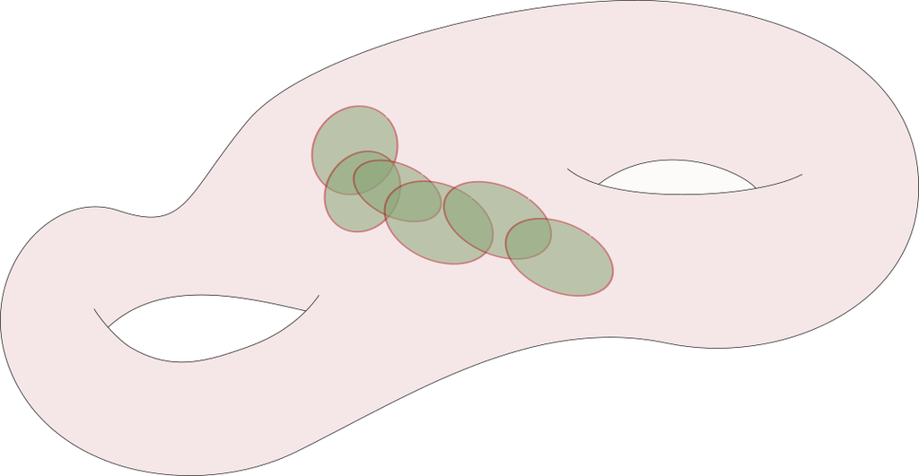

We want to compute $H^*(BU_d; {\mathbb{Z}})$. Why is this important? Given any complex vector bundle $\mathcal{E}\to X$ there is an associated principal $U_d$ bundle by choosing a metric, so we get a homotopy class $[X, BU_d]$. Given any $f\in [X, BU_d]$ and any $\alpha\in H^k(BU_d; {\mathbb{Z}})$, we can take the pullback $f^* \alpha \in H^k(X; {\mathbb{Z}})$, which are **Chern classes**.

Show that $H^*(BU_d; {\mathbb{Z}})$ stabilizes as $d\to \infty$ to an infinitely generated polynomial ring ${\mathbb{Z}}[c_1, c_2, \cdots]$ with each $c_i$ in cohomological degree $2i$, so $c_i \in H^{2i}(BU_d, {\mathbb{Z}})$.

There is a map $BU_{d-1} \to BU_d$, which we can identify as
$$\begin{align*}
{\operatorname{Gr}}_{d-1}(C^{\infty }) &\to {\operatorname{Gr}}_d({\mathbb{C}}^{\infty }) \\
\left\{{v_1, \cdots, v_{d-1}}\right\} &\mapsto {\operatorname{span}}\left\{{ (1, 0, 0, \cdots), sv_1, \cdots, sv_{d-1} }\right\}
.\end{align*}
This is defined by sending a basis where \(s: {\mathbb{C}}^{\infty } \to {\mathbb{C}}^{\infty}\) is the map that shifts every coordinate to the right by one.$$

This will yield a fiber sequence
$$\begin{align*}
S^{2d-1} \to BU_{d-1} \to BU_d
\end{align*}
and using connectedness of the sphere and the LES in homotopy this will identify
\begin{align*}
H^*(BU_d) = H^*(BU_{d-1})[c_d] && \text{where } c_d \in H^{2d}(BU_d)
.\end{align*}
The Chern class of a vector bundle \(\mathcal{E}\) , denoted \(c_k( \mathcal{E} )\), will be defined as the pullback \(f^* c_k\).$$

# 13 Wednesday, February 10

As $n\to \infty$, we have
$$\begin{align*}
H^*(BO_n, {\mathbb{Z}}/2{\mathbb{Z}}) = {\mathbb{Z}}/2{\mathbb{Z}}[w_1, w_2, \cdots]
&& w_i \in H^i
.\end{align*}$$

Given any principal $O_n{\hbox{-}}$bundle $P\to X$, there is an induced map $X \xrightarrow{f} BO_n$, so we can pull back the above generators to define the **Stiefel-Whitney classes** $f^* w_i$.

If $P \mathrel{\vcenter{:}}={\operatorname{OFrame}}TX$, then $f^* w_1$ measures whether $X$ has an orientation, i.e. $f^* w_1 = 0 \iff X$ can be oriented. We also have $f^* w_i(P) = w_i( \mathcal{E} )$ where $P = {\operatorname{OFrame}}( \mathcal{E} )$. In general, we’ll just write $w_i$ for Stiefel-Whitney classes and $c_i$ for Chern classes.

The **Pontryagin classes** of a real vector bundle $\mathcal{E}$ are defined as
$$\begin{align*}
p_i( \mathcal{E} ) = (-1)^i c_{2i}( \mathcal{E} \otimes_{\mathbb{R}}{\mathbb{C}})
.\end{align*}
Note that the complexified bundle above is a complex vector bundle with the same transition functions as \(\mathcal{E}\), but has a reduction of structure group from \(\operatorname{GL}_n({\mathbb{C}})\) to \(\operatorname{GL}_n({\mathbb{R}})\).$$

${\mathbb{RP}}^{\infty }$ and ${\mathbb{CP}}^{\infty }$ are examples of $K(\pi, n)$ spaces, which are the unique-up-to-homotopy spaces defined by
$$\begin{align*}
\pi_k K (\pi, n) =
\begin{cases}
\pi & k=n
\\
0 & \text{else}.
\end{cases}
\end{align*}$$

$$\begin{align*}
H^n(X; \pi) \cong [X, K( \pi, n) ]
.\end{align*}$$

$$\begin{align*}
[X, {\mathbb{RP}}^{\infty } ] &\cong H^1(X; {\mathbb{Z}}/2{\mathbb{Z}}) \\
[X, {\mathbb{CP}}^{\infty } ] &\cong H^2(X; {\mathbb{Z}})
.\end{align*}$$

There is a correspondence \begin{align*} \left\{{\substack{ \text{Complex line bundles} }}\right\} \rightleftharpoons [X, {\mathbb{CP}}^{\infty }] = [X, BC^{\times}] \rightleftharpoons H^2(X; {\mathbb{Z}}) \end{align*} Importantly, note that for $X \in {\mathsf{Mfd}}_{\mathbb{C}}$, $H^2(X; {\mathbb{Z}})$ measures *smooth* complex line bundles and not holomorphic bundles.

We’ll take an alternate direct proof. Consider the exponential exact sequence on $X$:
$$\begin{align*}
0 \to \underline{Z} \to {\mathcal{O}}\xrightarrow{\exp} {\mathcal{O}}^{\times}
.\end{align*}
Note that \(\underline{{\mathbb{Z}}}\) consists of locally constant \({\mathbb{Z}}{\hbox{-}}\)valued functions, \({\mathcal{O}}\) consists of smooth functions, and \({\mathcal{O}}^{\times}\) are ???.$$

This yields a LES in homology:

[figure not shown]

> Link to Diagram

Since ${\mathcal{O}}$ admits a partition of unity, $H^{>0}(X; {\mathcal{O}}) = 0$ and all of the red terms vanish. For complex line bundles $L$, $H^1(X, {\mathcal{O}}^{\times}) \cong H^2(X; {\mathbb{Z}})$. Taking a local trivialization ${ \left.{{L}} \right|_{{U}} } \cong U \times{\mathbb{C}}$, we obtain transition functions
$$\begin{align*}
t_{UV} \in C^{\infty }(U \cap V, \operatorname{GL}_1({\mathbb{C}}) )
\end{align*}
where we can identify \(\operatorname{GL}_1({\mathbb{C}}) \cong {\mathbb{C}}^{\times}\). We then have
\begin{align*}
(t_{U_{ij}}) \in \prod_{i < j} {\mathcal{O}}^{\times}(U_i \cap U_j) = C^1(X; {\mathcal{O}}^{\times})
.\end{align*}
Moreover,
\begin{align*}
\qty{
t_{U_{ij}}
t_{U_{ik}} ^{-1}
t_{U_{jk}}
}_{i,j,k}
= {{\partial}}( t_{U_{ij} } ) _{i, j} = 0
,\end{align*}
since transitions functions satisfy the cocycle condition. So in fact \((t_{U_{ij}}) \in Z^1(X; {\mathcal{O}}^{\times}) = \ker {{\partial}}^1\), and we can take its equivalence class \([ ( t_{U_{ij} } ) ] \in H^1(X; {\mathcal{O}}^{\times}) = \ker {{\partial}}^1 / \operatorname{im}{{\partial}}^0\). Changing trivializations by some \(s_i \in \prod_i {\mathcal{O}}^{\times}(U_i)\) yields a composition which is a different trivialization of the same bundle:$$

[figure not shown]

> [Link to Diagram](https://q.uiver.app/?q=WzAsMyxbMCwwLCJcXHJve0x9e1VfaX0iXSxbMiwwLCJVX2kgXFxjcm9zcyBcXENDIl0sWzUsMCwiVV9pIFxcY3Jvc3MgXFxDQyJdLFswLDEsImhfaSJdLFsxLDIsIlxcY2RvdCBzX2kiXSxbMCwyLCIiLDIseyJjdXJ2ZSI6NX1dXQ==)

So the $(t_{ U_{ij}}$ change *exactly* by an ${{\partial}}^0( s_i)$. Thus the following map is well-defined:
$$\begin{align*}
L \mapsto [ (t_{U_{ij}} ) ] \in H^1(X; {\mathcal{O}}^{\times})
.\end{align*}$$

There is another construction of the map
$$\begin{align*}
\left\{{L}\right\} &\to H^2(X; {\mathbb{Z}}) \\
L &\mapsto c_1(L)
.\end{align*}
Take a smooth section of \(L\) and \(s\in H^0(X; L)\) that intersects an \({\mathcal{O}}{\hbox{-}}\)section of \(L\) transversely. Then
\begin{align*}
V(s) \mathrel{\vcenter{:}}=\left\{{ x\in X {~\mathrel{\Big|}~}s(x) = 0 }\right\}
\end{align*}
is a submanifold of real codimension 2 in \(X\), and \(c_1(L) = [ V(s) ] \in H^2(X; {\mathbb{Z}})\).$$

1. Suppose that $\mathcal{E} = \bigoplus_{i=1}^r L_i$ and let $c(\mathcal{E}) \mathrel{\vcenter{:}}=\sum c_i(\mathcal{E}$. Then
   $$\begin{align*}
   c(\mathcal{E}) = \prod_{i=1}^r \qty{ 1 + c_i (L_i) }
   .\end{align*}$$
2. Given any vector bundle $\mathcal{E} \to X$, there exists some $Y$ and a map $Y\to X$ such that $f^*: H^k(X; {\mathbb{Z}}) \hookrightarrow H^k(Y; {\mathbb{Z}})$ is injective and $f^* \mathcal{E} = \bigoplus_{i=1}^r L_i$.

To verify any identities on characteristic classes, it suffices to prove them in the case where $\mathcal{E}$ splits into a direct sum of line bundles.

$$\begin{align*}
c( \mathcal{E} \oplus \mathcal{F}) = c( \mathcal{E} ) c( \mathcal{F} )
.\end{align*}
To prove this, apply the splitting principle. Choose \(Y, Y'\) splitting \(\mathcal{E}, \mathcal{E}'\) respectively, this produces a space \(Z\) and a map \(f:Z\to X\) where both split. We can write
\begin{align*}
f^* \mathcal{E} &= \bigoplus L_i
&& c(f^* \mathcal{E} ) = \prod \qty{ 1 + c_1(L_i) } \\
f^* \mathcal{F} &= \bigoplus M_j
&& c(f^* \mathcal{E} ) = \prod \qty{ 1 + c_1(M_j) }
.\end{align*}$$

We thus have
$$\begin{align*}
c( f^* \mathcal{E} \oplus f^* \mathcal{F} )
&= \prod \qty{1 + c_1(L_i) } \qty{1 + c_1(M_j)} \\
&= c(f^* \mathcal{E} ) c(f^* \mathcal{F} )
,\end{align*}
and \(f^* (c( \mathcal{E} \oplus \mathcal{F} ) = f^* (c (\mathcal{E}) c( \mathcal{F}))\). Since \(f^*\) is injective, this yields the desired identity.$$

We can compute $c(\operatorname{Sym}^2 \mathcal{E})$, and really any tensorial combination involving $\mathcal{E}$, and it will always yield some formula in the $c_i( \mathcal{E} )$.

# 14 Friday, February 12

Last time: the splitting principle. Suppose we have $\mathcal{E} = L_1 \oplus \cdots \oplus L_r$ and let $x_i \mathrel{\vcenter{:}}= c_i(L_i)$. Then $c_k(\mathcal{E})$ is the degree $2k$ part of $\prod_{i=1}^r (1 + x_i )$ where each $x_i$ is in degree $2$. This is equal to $e_k(x_1, \cdots, x_r)$ where $e_k$ is the $k$th elementary symmetric polynomial.

For example,

- $e_1 = x_1 + \cdots x_r$.
- $e_2 = x_1 x_2 + x_1 x_3 + \cdots = \sum_{i < j} x_i x_j$
- $e_3 = \sum_{i<j<k} x_i x_j x_k$, etc.

The theorem is that any symmetric polynomial is a polynomial in the $e_i$. For example, $p_2 = \sum x_i^2$ can be written as $e_1^2 - 2e_2$. Similarly, $p_3 = \sum x_i^3 = e_1^3 - 3e_1 e_2 -3e_3$ Note that the coefficients of these polynomials are important for representations of $S_n$, see *Schur polynomials*.

Due to the splitting principle, we can pretend that $x_i = c_i(L_i)$ exists even when $\mathcal{E}$ doesn’t split. If $\mathcal{E} \to X$, the individual symbols $x_i$ don’t exist, but we can write ’
$$\begin{align*}
x_1^3 + \cdots + x_r^3 = e_1^3 - 3e_1 e_2 - 3e_3 \mathrel{\vcenter{:}}= c_1(\mathcal{E})^3 + 3c_1(\mathcal{E}) c_2(\mathcal{E}) + \cdots
,\end{align*}
which is a well-defined element of \(H^6(X; {\mathbb{Z}})\). So this polynomial defines a characteristic class of \(\mathcal{E}\), and this can be done for any symmetric polynomial. We can change basis in the space of symmetric polynomials to now define different characteristic classes.$$

The **Chern character** is defined as
$$\begin{align*}
\operatorname{ch}(\mathcal{E})
&\mathrel{\vcenter{:}}=\sum_{i=1}^r e^{x_i}\in H^*(X; {\mathbb{Q}}) \\
&\mathrel{\vcenter{:}}=\sum_{i=1}^r \sum_{k=0}^{\infty } {x_i^k \over k!} \\
&= \sum_{k=0}^{\infty } {p_k(x_1, \cdots, x_r) \over k!} \\
&= \operatorname{rank}(\mathcal{E}) + c_1(\mathcal{E}) + { c_1(\mathcal{E}) - c_2(\mathcal{E}) \over 2!} + { c_1(\mathcal{E})^3 - 3c_1(\mathcal{E}) c_2(\mathcal{E}) - 3 c_3(\mathcal{E}) \over 3!} + \cdots \\
& \qquad \in H^0 + H^2 + H^4 + H^6 \\
&=\operatorname{ch}_0(\mathcal{E}) + \operatorname{ch}_1(\mathcal{E}) + \operatorname{ch}_2( \mathcal{E} ) + \cdots, \\
& \quad \operatorname{ch}_i(\mathcal{E}) \in H^{2i}(X; {\mathbb{Q}})
.\end{align*}$$

The **total Todd class**
$$\begin{align*}
\mathrm{td}(\mathcal{E})
\mathrel{\vcenter{:}}=
\prod_{i=1}^r { x_i \over 1 - e^{-x_i} }
.\end{align*}$$

Note that
$$\begin{align*}
{x_i \over 1 - e^{-x_i} } = 1 + {x_i \over 2} + {x_i^2 \over 12} + {x_i^4 \over 720} + \cdots = 1 + {x_i \over 2} + \sum_{i=1}^{\infty } { (-1)^{i-1} B_i \over (2i)! } x^{2i}
.\end{align*}
where L’Hopital shows that the derivative at \(x_i = 0\) exists, so it’s analytic at zero and the expansion makes sense, and the \(B_i\) are Bernoulli numbers.$$

Let $X \in {\mathsf{Mfd}}_{\mathbb{C}}$, then define the **Todd class** of $X$ as $\mathrm{td}_{\mathbb{C}}(X) \mathrel{\vcenter{:}}=\mathrm{td}(TX)$ where $TX$ is viewed as a complex vector bundle. If $X\in {\mathsf{Mfd}}_{\mathbb{R}}$, define $\mathrm{td}_{\mathbb{R}}= \mathrm{td}(TX \otimes_{\mathbb{R}}{\mathbb{C}})$.

## 14.1 Section 5: Riemann-Roch and Generalizations

Let $X\in {\mathsf{Top}}$ and let $\operatorname{\mathcal{F}}$ be a sheaf of vector spaces. Suppose $h^i(X; \operatorname{\mathcal{F}}) \mathrel{\vcenter{:}}=\dim H^i(X; \operatorname{\mathcal{F}}) < \infty$ for all $i$ and is equal to 0 for $i \gg 0$.

The **Euler characteristic** of $\operatorname{\mathcal{F}}$ is defined as
$$\begin{align*}
\chi(X; \operatorname{\mathcal{F}}) \mathrel{\vcenter{:}}=\chi(\operatorname{\mathcal{F}}) \mathrel{\vcenter{:}}=\sum_{i=0}^{\infty } (-1)^i h_i(X; \operatorname{\mathcal{F}} )
.\end{align*}$$

This is not always well-defined!

Let $X\in {\mathsf{Mfd}}_{\text{cpt}}$ and take $\operatorname{\mathcal{F}} \mathrel{\vcenter{:}}=\underline{{\mathbb{R}}}$, we then have
$$\begin{align*}
\chi(X; \underline{{\mathbb{R}}}) = h^0(X; {\mathbb{R}}) - h^1(X; {\mathbb{R}}) + \cdots = b_0 - b_1 + b_2 - \cdots \mathrel{\vcenter{:}}=\chi_{{\mathsf{Top}}}(X)
.\end{align*}$$

Let $X = {\mathbb{C}}$ and take $\operatorname{\mathcal{F}} \mathrel{\vcenter{:}}={\mathcal{O}}\mathrel{\vcenter{:}}={\mathcal{O}}^{\text{holo}}$ the sheaf of holomorphic functions. We then have $h^{> 0}(X; {\mathcal{O}}) = 0$, but $H^0(X; {\mathcal{O}})$ is the space of all holomorphic functions on ${\mathbb{C}}$, making $\dim_{\mathbb{C}}h^0(X; {\mathcal{O}})$ infinite.

Take $X = {\mathbb{P}}^1$ with ${\mathcal{O}}$ as above, $h^0({\mathbb{P}}^1; {\mathcal{O}}) = 1$ since ${\mathbb{P}}^1$ is compact and the maximum modulus principle applies, so the only global holomorphic functions are constant. We can write ${\mathbb{P}}^1 = {\mathbb{C}}_1 \cup{\mathbb{C}}_2$ as a cover and $h^i({\mathbb{C}}, {\mathcal{O}}) = 0$, so this is an acyclic cover and we can use it to compute $h^1({\mathbb{P}}^1; {\mathcal{O}})$ using Čech cohomology. We have

- $C^0({\mathbb{P}}^1; {\mathcal{O}}) = {\mathcal{O}}({\mathbb{C}}_1) \oplus {\mathcal{O}}({\mathbb{C}}_2)$
- $C^1({\mathbb{P}}^1; {\mathcal{O}}) = {\mathcal{O}}({\mathbb{C}}_1 \cap{\mathbb{C}}_2) = {\mathcal{O}}({\mathbb{C}}^{\times})$.
- The boundary map is given by
  $$\begin{align*}
  {\partial}_0: C^0 &\to C^1 \\
  ( f(z), g(z) ) &\mapsto g(1/z) - f(z)
  \end{align*}
  and there are no triple intersections.$$

Is every holomorphic function on ${\mathbb{C}}^{\times}$ of the form $g(1/z) - f(z)$ with $f,g$ holomorphic on ${\mathbb{C}}$. The answer is yes, by Laurent expansion, and thus $h^1 = 0$. We can thus compute $\chi({\mathbb{P}}^1; {\mathcal{O}}) = 1-0 = 1$.

# 15 Monday, February 15

Last time: we saw that $\chi({\mathbb{P}}^1, {\mathcal{O}}) = 1$, and we’d like to generalize to holomorphic line bundles on a Riemann surface. This will be the main ingredient for Riemann-Roch.

Let $X \in {\mathsf{Mfd}}_{\mathbb{C}}$ be compact and let $\mathcal{F}$ be a holomorphic vector bundle on $X$[^3] Then $\chi$ is well-defined and
$$\begin{align*} h^{> \dim_{\mathbb{C}}X}(X; \mathcal{F} ) = 0.\end{align*}$$

The locally constant sheaf $\underline{{\mathbb{C}}}$ is not an ${\mathcal{O}}{\hbox{-}}$module, i.e. $\underline{{\mathbb{C}}}(U) \not\in {\mathsf{{\mathcal{O}}(U)}{\hbox{-}}\mathsf{Mod}}$. In fact, $h^{2i}(X, \underline{{\mathbb{C}}}) = {\mathbb{C}}$ for all $i$.

We’ll can resolve $\mathcal{F}$ as a sheaf by first mapping to its smooth sections and continuing in the following way:
$$\begin{align*}
0 \to \mathcal{F} \to C^{\infty } \mathcal{F} \xrightarrow{\mkern 1.5mu\overline{\mkern-1.5mu{\partial}\mkern-1.5mu}\mkern 1.5mu} F \otimes A^{0, 1} \to \cdots
,\end{align*}
where \(\mkern 1.5mu\overline{\mkern-1.5mu{\partial}\mkern-1.5mu}\mkern 1.5muf = \sum_i {\frac{\partial f}{\partial {\overline{{z}}}_i}\,} \, d{\overline{{z}}}_i\). Suppose we have a holomorphic trivialization of \({ \left.{{\mathcal{F} }} \right|_{{U}} } \cong {\mathcal{O}}_{U}^{\oplus r}\) and we have sections \((s_1, \cdots, s_r) \in C^{\infty } \mathcal{F}(U)\), which are smooth functions on \(U\). In local coordinates we have
\begin{align*}
\mkern 1.5mu\overline{\mkern-1.5mu{\partial}\mkern-1.5mu}\mkern 1.5mus \mathrel{\vcenter{:}}=(\mkern 1.5mu\overline{\mkern-1.5mu{\partial}\mkern-1.5mu}\mkern 1.5mus_1, \cdots, \mkern 1.5mu\overline{\mkern-1.5mu{\partial}\mkern-1.5mu}\mkern 1.5mus_r)
,\end{align*}
but is this well-defined globally? Given a different trivialization over \(V \subseteq X\), the \(s_i\) are related by transition functions, so the new sections are \(t_{UV}(s_1, \cdots, s_r)\) where \(t_{UV}: U \cap V \to \operatorname{GL}_r({\mathbb{C}})\). Since \(t_{UV}\) are holomorphic, we have
\begin{align*}
\mkern 1.5mu\overline{\mkern-1.5mu{\partial}\mkern-1.5mu}\mkern 1.5mu( t_{UV} (s_1, \cdots, s_r)) = t_{UV} \mkern 1.5mu\overline{\mkern-1.5mu{\partial}\mkern-1.5mu}\mkern 1.5mu(s_1, \cdots, s_r)
.\end{align*}
This makes \(\mkern 1.5mu\overline{\mkern-1.5mu{\partial}\mkern-1.5mu}\mkern 1.5mu: C^{\infty } \mathcal{F} \to F\otimes A^{0, 1}\) a well-defined (but not \({\mathcal{O}}{\hbox{-}}\)linear) map. We can thus continue this resolution using the Leibniz rule:$$

$$\begin{align*}
0 \to \mathcal{F} \to C^{\infty } \mathcal{F} \xrightarrow{\mkern 1.5mu\overline{\mkern-1.5mu{\partial}\mkern-1.5mu}\mkern 1.5mu} F \otimes A^{0, 1} \xrightarrow{\mkern 1.5mu\overline{\mkern-1.5mu{\partial}\mkern-1.5mu}\mkern 1.5mu} \cdots F \otimes A^{0, 2} \xrightarrow{\mkern 1.5mu\overline{\mkern-1.5mu{\partial}\mkern-1.5mu}\mkern 1.5mu} \cdots
,\end{align*}
which is an exact sequence of sheaves since \((A^{0, {\,\cdot\,}}, \mkern 1.5mu\overline{\mkern-1.5mu{\partial}\mkern-1.5mu}\mkern 1.5mu)\) is exact.$$

We can identify $C^{\infty }\operatorname{\mathcal{F}} = \operatorname{\mathcal{F}} \otimes A^{0, 0}$, and $\operatorname{\mathcal{F}} \otimes A^{0, q}$ is a smooth vector bundle on $X$. Using partitions of unity, we have that $\operatorname{\mathcal{F}} \otimes A^{0, q}$ is acyclic, so its higher cohomology vanishes, and
$$\begin{align*}
H^i(X; \operatorname{\mathcal{F}} ) \cong
\frac
{ \ker ( \mkern 1.5mu\overline{\mkern-1.5mu{\partial}\mkern-1.5mu}\mkern 1.5mu: \operatorname{\mathcal{F}}\otimes A^{0, i} \to \operatorname{\mathcal{F}} \otimes A^{0, i+1} }
{ \operatorname{im}( \mkern 1.5mu\overline{\mkern-1.5mu{\partial}\mkern-1.5mu}\mkern 1.5mu: \operatorname{\mathcal{F}}\otimes A^{0, i-1} \to \operatorname{\mathcal{F}} \otimes A^{0, i} }
.\end{align*}
However, we know that \(A^{0, p} = 0\) for all \(p> n \mathrel{\vcenter{:}}=\dim_{\mathbb{C}}X\), since any wedge of \(p>n\) forms necessarily vanishes since there are only \(n\) complex coordinates.$$

This only applies to holomorphic vector bundles or ${\mathcal{O}}{\hbox{-}}$modules!

## 15.1 Riemann-Roch

Let $C$ be a compact connected Riemann surface, i.e. $X\in {\mathsf{Mfd}}_{\mathbb{C}}$ with $\dim_{\mathbb{C}}(X) = 1$, and let $\mathcal{L}\to C$ be a holomorphic line bundle. Then
$$\begin{align*}
\chi(C, \mathcal{L}) = \deg(L) + (1-g) && \text{where } \int_C c_1(\mathcal{L})
\end{align*}
and \(g\) is the genus of \(C\).$$

We’ll introduce the notion of a “point bundle,” which are particularly nice line bundles, denoted ${\mathcal{O}}(p)$ for $p\in {\mathbb{C}}$.

[figure not shown]

Taking ${\mathbb{D}}$ to be a disc of radius $1/2$ and $V$ to be its complement, we have $t_{uv}(z) = z^{-1}\in {\mathcal{O}}^*(U \cap V)$. We can take a holomorphic section $s_p \in H^0( C, {\mathcal{O}}(p) )$, where ${ \left.{{s_p}} \right|_{{U}} } = z$ and ${ \left.{{s_p}} \right|_{{V}} } = 1$. Then $t_{uv}( { \left.{{s_p}} \right|_{{U}} } ) = { \left.{{s_p}} \right|_{{V}} }$ on the overlaps. We have a function which precisely vanishes to first order at $p$. Recall that $c_1( {\mathcal{O}}(p) )$ is represented by $[ V(s) ] = [p]$, and moreover $\int_C c_1 ( {\mathcal{O}}(p) ) = 1$. We now want to generalize this to a **divisor**: a formal ${\mathbb{Z}}{\hbox{-}}$linear combination of points.

Take $p, q,r\in C$, then a divisor can be defined as something like $D \mathrel{\vcenter{:}}= 2[p] - [q] + 3[r]$.

Define ${\mathcal{O}}(D) \mathrel{\vcenter{:}}=\bigotimes_{i} {\mathcal{O}}(p_i)^{\otimes n_i}$ for any $D = \sum n_i [p_i]$. Here tensoring by negatives means taking duals, i.e. ${\mathcal{O}}( -[p] ) \mathrel{\vcenter{:}}={\mathcal{O}}^{\otimes_{-1}} \mathrel{\vcenter{:}}={\mathcal{O}}(p)^\vee$, the line bundle with inverted transition functions. ${\mathcal{O}}(D)$ has a meromorphic section given by
$$\begin{align*}
s_D \mathrel{\vcenter{:}}=\prod s_{p_i}^{n_i} \in \operatorname{Mero}(C, {\mathcal{O}}(D) )
\end{align*}
where we take the sections coming from point bundles. We can compute
\begin{align*}
\int_C c_1 ( {\mathcal{O}}(D) ) = \sum n_i \mathrel{\vcenter{:}}=\deg(D)
.\end{align*}
.$$

$$\begin{align*}
\deg( 2[p] -[q] + 3[r]) = 4
.\end{align*}$$

Assume our line bundle $L$ is ${\mathcal{O}}(D)$, we’ll prove Riemann-Roch in this case by induction on $\sum {\left\lvert {n_i} \right\rvert}$. The base case is ${\mathcal{O}}$, which corresponds to taking an empty divisor. Then either

- Take $D = D_0 + [p]$ with $\deg(D_0) < \sum {\left\lvert {n_i} \right\rvert}$ (for which we need some positive coefficient), or
- Take $D_0 = D + [p]$.

There is an exact sequence
$$\begin{align*}
0 \to {\mathcal{O}}(D_0) &\to {\mathcal{O}}(D) \to {\mathbb{C}}_p \to 0\\
s\in {\mathcal{O}}(D_0)(U) &\mapsto s \cdot s_p \in {\mathcal{O}}( D_0 + [p] ) (U)
,\end{align*}
where the last term is the skyscraper sheaf at \(p\).$$

The given map is ${\mathcal{O}}{\hbox{-}}$linear and injective, since $s_p\neq 0$ and $s s_p=0$ forces $s=0$. Recall that we looked at ${\mathcal{O}}\xrightarrow{\cdot z} {\mathcal{O}}$ on ${\mathbb{C}}$, and this section only vanishes at $p$ (and to first order). The same situation is happening here.

Thus there is a LES

[figure not shown]

> Link to Diagram

We also have $h^1({\mathbb{C}}_p) = 0$ by taking a sufficiently fine open cover where $p$ is only in one open set. So just checking Čech cocycles yields $C_U^1(C, {\mathbb{C}}_p) \mathrel{\vcenter{:}}=\prod_{i<j} {\mathbb{C}}_p(U_i \cap U_j) = 0$ since $p$ is in no intersection.

[figure not shown]

We obtain $\chi( {\mathcal{O}}(D) = \chi( {\mathcal{O}}(D_0) ) + 1$, using that it is additive in SESs
$$\begin{align*}
0 \to
\operatorname{\mathcal{E}}_1 \to
\operatorname{\mathcal{E}}_2 \to
\operatorname{\mathcal{E}}_3 \to
0
\implies &&
\chi(\operatorname{\mathcal{E}}_2) = \chi( \operatorname{\mathcal{E_1}}) + \chi( \operatorname{\mathcal{E}}_3 )
\end{align*}
and thus
\begin{align*}
\int_C c_1 ({\mathcal{O}}(D) ) = \sum n_i = \deg(D) = \deg D_0 + 1
.\end{align*}
The last step is to show that \(\chi(C, {\mathcal{O}}) = 1-g\), so just define \(g\) so that this is true!$$

Why is every $L \cong {\mathcal{O}}(D)$ for some $D$? Easy to see if $L$ has meromorphic sections: if $s$ is a meromorphic section of $L$, then the following works:
$$\begin{align*}
D = \operatorname{Div}(s) = \sum_p {\operatorname{Ord}}_p(s) [p]
.\end{align*}
Then \({\mathcal{O}}\cong L\otimes{\mathcal{O}}(-D)\) has a meromorphic section \(s s_{-D}\), a global nonvanishing section with \(\operatorname{Div}(s s_{-D} ) = \emptyset\). Proving that every holomorphic line bundle has a meromorphic section is hard!$$

# 16 Friday, February 19

## 16.1 Applications of Riemann-Roch

A **curve** is a compact complex manifold of complex dimension 1.

Let $C$ be a curve, then $\Omega_C^1$ is the sheaf of holomorphic 1-forms, and $\Omega_C^{>1} = 0$. We also have the sheaves $A^{1, 0}, A^{0, 1}, A^{1, 1},$ the sheaves of smooth $(p, q){\hbox{-}}$forms. Here the only nonzero combinations are $(0, 0), (0, 1), (1, 0), (1, 1)$ by dimensional considerations. Let $L$ be a holomorphic line bundle on $C$, then
$$\begin{align*} \chi(C, L) = h^0(L) - h^1(L) = \deg(L) + 1 - g .\end{align*}$$

In general it can be hard to compute $h^1(L)$, since this is sheaf cohomology (sections over double overlaps, cocycle conditions, etc). On the other hand, $h^0$ is easy to understand, since $h^0( \Omega^1_C)$ is the dimension of the global holomorphic sections $H^0(C, L) = L(C)$. A key tool here is the following:

$$\begin{align*}
H^1(C, L) \cong H^0(C, L ^{-1} \otimes\Omega_C^1)^\vee
,\end{align*}
noting that these are both global sections of a line bundle.$$

Recall that we had a resolution of the sheaf $L$ given by by smooth vector bundles:
$$\begin{align*}
0 \to L \hookrightarrow L\otimes A^{0, 0} \xrightarrow{\mkern 1.5mu\overline{\mkern-1.5mu{\partial}\mkern-1.5mu}\mkern 1.5mu} L \otimes A^{0, 1} \xrightarrow{\mkern 1.5mu\overline{\mkern-1.5mu{\partial}\mkern-1.5mu}\mkern 1.5mu} 0
.\end{align*}
So we know that
\begin{align*}
H^1(C, L) = H^0(L\otimes A^{0, 1}) / \mkern 1.5mu\overline{\mkern-1.5mu{\partial}\mkern-1.5mu}\mkern 1.5muH^0(L\otimes A^{0, 0})
.\end{align*}
Choose a Hermitian metric \(h\) on \(L\), i.e. a map \(h: L\otimes{\overline{{L}}} \to {\mathcal{O}}\). On fibers, we have \(h_p: L_p \otimes\mkern 1.5mu\overline{\mkern-1.5mu L_p \mkern-1.5mu}\mkern 1.5mu \to {\mathbb{C}}\). We’ll also choose a metric on \(C\), say \(g\). Since \(C\) is a Riemann surface, we have an associated volume form \(\nu\) on \(C\) (essentially the determinant), so we can define a pairing between sections of \(L\otimes A^{0, 0}\):
\begin{align*}
{\left\langle {s},~{t} \right\rangle} \mathrel{\vcenter{:}}=\int_C h(s, {\overline{{t}}} ) \,d\nu
.\end{align*}
Note that
\begin{align*}
{\left\langle {s},~{s} \right\rangle} = \int_C h(s, {\overline{{s}}}) \,d\nu \geq 0
&& \text{since }
h(s, {\overline{{s}}})(p) = 0 \iff s_p = 0
,\end{align*}
and moreover this integral is zero if and only if \(s=0\). So we have an inner product on \(H^0(L\otimes A^{0, 0})\). We can also define a pairing on sections of \(L\otimes A^{0, 1}\), say
\begin{align*}
{\left\langle { s \otimes \alpha},~{ t \otimes \beta} \right\rangle} = \int_C h(s, {\overline{{t}}}) \alpha\wedge {\overline{{\beta}}}
.\end{align*}
Note that \(h\) is a smooth function and \(\alpha\wedge {\overline{{\beta}}}\) is a \((1, 1){\hbox{-}}\)form. Moreover, this is positive and nondegenerate. We want to understand the cokernel of the linear map
\begin{align*}
H^0(L \otimes A^{0, 0}) \xrightarrow{\mkern 1.5mu\overline{\mkern-1.5mu{\partial}\mkern-1.5mu}\mkern 1.5mu} H^0( L \otimes A^{0, 1})
.\end{align*}
To compute \(\operatorname{coker}(\mkern 1.5mu\overline{\mkern-1.5mu{\partial}\mkern-1.5mu}\mkern 1.5mu)\), we can look at the kernel of the adjoint, and it suffices to find the orthogonal complement of \(\operatorname{im}( \mkern 1.5mu\overline{\mkern-1.5mu{\partial}\mkern-1.5mu}\mkern 1.5mu)\), i.e.
\begin{align*}
\operatorname{coker}(\mkern 1.5mu\overline{\mkern-1.5mu{\partial}\mkern-1.5mu}\mkern 1.5mu) = \left\{{ t\in H^0(L\otimes A^{0, 1}) {~\mathrel{\Big|}~}{\left\langle {\mkern 1.5mu\overline{\mkern-1.5mu{\partial}\mkern-1.5mu}\mkern 1.5mus},~{t} \right\rangle} = 0 \, \forall s}\right\}
.\end{align*}$$

[figure not shown]

So we want to understand sections $t\in H^0(L\otimes A^{0, 1})$ such that
$$\begin{align*}
\int_C (\mkern 1.5mu\overline{\mkern-1.5mu{\partial}\mkern-1.5mu}\mkern 1.5mus){\overline{{t}}} = 0 && \forall s\in H^0(L\otimes A^{0, 0})
,\end{align*}
where \({{\partial}}C = \emptyset\). We’ll basically want to do integration by parts on this. Note that \(h(s, t) = hst\) here where we view \(h\) as a certain section. Note that \({\overline{{t}}} \in H^0({\overline{{L}}} \otimes A^{1, 0})\), so we can replace \({\partial}\) with \(d = \mkern 1.5mu\overline{\mkern-1.5mu{\partial}\mkern-1.5mu}\mkern 1.5mu+ {\partial}\) and apply Stokes’ theorem:
\begin{align*}
\int_C s d(h {\overline{{t}}}) &= 0 && \forall s\in H^0(L\otimes A^{0, 0}) \\
0
&= \int_C s\mkern 1.5mu\overline{\mkern-1.5mu{\partial}\mkern-1.5mu}\mkern 1.5mu(h {\overline{{t}}}) \\
&= \int_C s {\mkern 1.5mu\overline{\mkern-1.5mu{\partial}\mkern-1.5mu}\mkern 1.5mu(h {\overline{{t}}}) \over d\nu}d\nu\\
&= {\left\langle {s},~{{\overline{{\mkern 1.5mu\overline{\mkern-1.5mu{\partial}\mkern-1.5mu}\mkern 1.5mu(h {\overline{{t}}}) \over d\nu }}}} \right\rangle}
\end{align*}
where \(h \in C^{\infty }(L ^{-1} \otimes{\overline{{L}}}^{-1})\) and \(h{\overline{{t}}} \in C^{\infty }(L^{-1}\otimes A^{1, 0})\). But the right-hand side is in \(H^0(L \otimes A^{0, 0} )\) and by nondegeneracy we can conclude
\begin{align*}
{\overline{{\mkern 1.5mu\overline{\mkern-1.5mu{\partial}\mkern-1.5mu}\mkern 1.5mu(h {\overline{{t}}}) \over d\nu }}} = 0
\iff \mkern 1.5mu\overline{\mkern-1.5mu{\partial}\mkern-1.5mu}\mkern 1.5mu(h{\overline{{t}}}) = 0
.\end{align*}
We thus have \(h{\overline{{t}}} \in H^0( L ^{-1}\otimes A^{1, 0}\) which is a holomorphic line bundle tensored with \(A^{0, 0}\). Thus \(\operatorname{coker}(\mkern 1.5mu\overline{\mkern-1.5mu{\partial}\mkern-1.5mu}\mkern 1.5mu) \cong_h H^0( L ^{-1} \otimes\Omega^1)\).$$

We showed ${\left\langle {\mkern 1.5mu\overline{\mkern-1.5mu{\partial}\mkern-1.5mu}\mkern 1.5mus},~{t} \right\rangle} = {\left\langle {s},~{Y (t)} \right\rangle}$ where $Y$ is the adjoint given above. Then the kernel of $Y$ wound up being where $\mkern 1.5mu\overline{\mkern-1.5mu{\partial}\mkern-1.5mu}\mkern 1.5mu$ vanishes, i.e. holomorphic sections of a separate bundle. Here we had

- $t \in H^0(L\otimes A^{0, 1})$
- ${\overline{{t}}} \in H^0({\overline{{L}}}\otimes A^{1,0})$
- $h\in H^0( L ^{-1} \otimes{\overline{{ L ^{-1} }}})$

# 17 Monday, February 22

Last time: Serre duality, and we’ll review Riemann-Roch. Recall that this depended on the statement that every holomorphic line bundle $L\to C$ for $C$ a complex curve is of the form $L = {\mathcal{O}}(D)$ for some divisor $D$. Then
$$\begin{align*}
\chi(C, L) = h^0(L) - h^1(L) = \deg L + 1 - g, && \deg L = \int_C c_1(L)
,\end{align*}
Serre duality said that the space of sections \(H^1(C; L)\) is naturally isomorphic to \(H^0(C, L ^{-1} \otimes\Omega_C^1)^\vee\). Notation: given \(X \in {\mathsf{Mfd}}_{\mathbb{C}}^n\) of complex, dimension \(n\), the canonical bundle is written \(K_X \mathrel{\vcenter{:}}=\Omega_X^n\) and is the sheaf of holomorphic \(n{\hbox{-}}\)forms. Serre duality will generalize: if \(\mathcal{E}\to X\) is a holomorphic vector bundle, then \(H^i(X; \mathcal{E}) \cong H^{n-i}(X; \mathcal{E}^\vee\otimes K_X)^\vee\). Note that only \(H^0, H^1\) are the only nontrivial degrees for a curve. For 4-manifolds, we’ll have an \(H^2\) as well.$$

## 17.1 Applications of Riemann-Roch

There is a unique complex $X\in {\mathsf{Mfd}}_{\mathbb{C}}$ diffeomorphic to $S^2$.

Note existence is clear, since we can take ${\mathbb{CP}}^1 \mathrel{\vcenter{:}}=({\mathbb{C}}^2 \setminus\left\{{0}\right\}) / \mathbf{x} \sim \lambda\mathbf{x}$ for $\lambda\in {\mathbb{C}}^{\times}$, which is identified as the set of complex lines through $0$ in ${\mathbb{C}}^2$. This decomposes as ${\mathbb{C}}\cup{\mathbb{C}}= \left\{{ [1, *] }\right\} \cup\left\{{ [*, 1] }\right\}$. We now want to show that any two such complex manifolds are biholomorphic. Let $X \in {\mathsf{Mfd}}_{\mathbb{C}}^1$ with $X\cong_{C^{\infty }} S^2$, and consider for $p\in X$ the point bundle ${\mathcal{O}}(p) \to X$. The defining property was that there exists a section $s_p \in H^0(X; {\mathcal{O}}(p) )$ which vanishes at first order at $p$:

[figure not shown]

We have
$$\begin{align*}
\chi(X; {\mathcal{O}}(p))
= \deg {\mathcal{O}}(p) + 1 - g(x) = 1 + 1 - 0 = 2
.\end{align*}$$

Check that $\deg {\mathcal{O}}(p) = 1$.

On the other hand we have
$$\begin{align*}
\chi(X; {\mathcal{O}}(p))
=
h^0({\mathcal{O}}(p)) - h^1( {\mathcal{O}}(p) )
.\end{align*}$$

We have $h^1( {\mathcal{O}}(p) ) = H60( K \otimes{\mathcal{O}}(-p)$, and $K_X = \Omega_X^1 = T^\vee X$, so the question is: what is the degree of $TX$ for $X\cong S^2$? We need to compute $\int_X c_1(TX)$. How many zeros does a vector field on the sphere have? You can take the gradient vector field for a height function to get $2$, noting that the two zeros come in with a positive orientation

[figure not shown]

In coordinates on ${\mathbb{CP}}^1$, the coordinate is given by $z$ and $z {\frac{\partial }{\partial z}\,} \mapsto -2 {\frac{\partial }{\partial w}\,}$ for the coordinate $w = 1/z$. We get $\int_X c_1(TX) = 2$ and thus $\deg K_X = -2$ by dualizing.

$\deg K_X = 2g-2$. Use the existence of a smooth vector field on $X$.

If $\deg L < 0$ on $C$< the $h^0(C, L) = 0$.

If $s\in H^0(C, L)$ is nonzero, then since $s$ is a holomorphic section,
$$\begin{align*}
0 \leq \sum_{p\in C} {\operatorname{Ord}}_P (s) = \deg L
.\end{align*}$$

By this lemma, $h^1({\mathcal{O}}(p)) = 0$. We have $H^0(X; {\mathcal{O}}(p)) = {\mathbb{C}}s_p \oplus {\mathbb{C}}s$ for our specific section $s_p$ and some other section $s \neq \lambda s_p$. Note that $s/s_p$ is a meromorphic section of ${\mathcal{O}}(p) \times{\mathcal{O}}(-p) = {\mathcal{O}}$, so we have a map
$$\begin{align*}
\varphi: {s \over s_p} : X\to {\mathbb{P}}^1
.\end{align*}
Note that \(P\mapsto \infty \in {\mathbb{P}}^1\) under this \(\varphi\), and it’s only the ratio that is well-defined. We have \(\varphi ^{-1} (u) = \left\{{ s/s_p = u }\right\} = \left\{{ s - us_p =0 }\right\}\) which is a single point. So \(\varphi\) is a degree 1 map, and \(X\) is biholomorphic to \({\mathbb{P}}^1\) via \(\varphi\).$$

So there is only one genus 0 Riemann surface. What about genus 1?

[figure not shown]

By Riemann-Roch we know
$$\begin{align*}
\chi(C; {\mathcal{O}}) = \deg {\mathcal{O}}+ l - 1 = 0 = h^0({\mathcal{O}}) - h^1({\mathcal{O}})
.\end{align*}
We know \(h^0({\mathcal{O}}) = 1\) by the maximum modulus principle and \(h^1(C; {\mathcal{O}}) = 1\). By Serre duality, \(h^0(C, K) = 1\), and since \(\deg K = 2g-2 = 0\). So let \(s\in H^0(C, K)\) by a nonzero section, which we know exists. We then get \({\operatorname{Ord}}_p s = 0\) for all \(p\), so \(s\) vanishes nowhere. But then we get an isomorphism of sheaves, since \(s\) everywhere nonvanishing implies trivial cokernel:
\begin{align*}
{\mathcal{O}}\xrightarrow{\cdot s} K
.\end{align*}
So \(K_C = {\mathcal{O}}_C\) if \(g(C) = 1\), and such a Riemann surface is an elliptic curve.$$

Let $C \mathrel{\vcenter{:}}={\mathbb{C}}/ \Lambda$ for $\Lambda$ some lattice.

[figure not shown]

All transition functions are of the form $z \mapsto z + \lambda$ for some $\lambda\in \Lambda$. What is a nonvanishing section of $K_C$, i.e. a holomorphic one form $\omega \mathrel{\vcenter{:}}= f(z) dz$ on ${\mathbb{C}}$ that descends to ${\mathbb{C}}/\Lambda$. We would need $f(z)dz = f(z + \lambda)d(z+ \lambda)$ for all $\lambda$. Something like $f=1$ works, so $\omega= dz$ descends. In fact, $f$ must be constant, since $H^0( {\mathbb{C}}/ \Lambda, {\mathcal{O}}) = {\mathbb{C}}\,dz$ by the maximum modulus principle. Now let $p, q\in C$ and apply Riemann-Roch to the line bundle ${\mathcal{O}}(p+q)$ yields
$$\begin{align*}
\chi( {\mathcal{O}}(p+q) ) &=
h^0( {\mathcal{O}}(p+q) )-
h^1( {\mathcal{O}}(-p-q) ) \\
&=
h^0( {\mathcal{O}}(p+q) )-0\\
&=
\deg {\mathcal{O}}(p+q)+1-1 \\
&=2
.\end{align*}
Thus there is a section \(s_{p+q} \in H^0( {\mathcal{O}}(p+q)) \ni s\) that vanishes at \(p+q\), and similarly a map
\begin{align*}
{s\over s_{p+q}}: C \xrightarrow{\varphi} {\mathbb{P}}^1
.\end{align*}
We can check \(\varphi ^{-1} ( \infty ) = p+q\) and \(\deg \varphi = 2\). Thus genus 1 surfaces have a generically 2-to-1 map to \({\mathbb{P}}^1\).$$

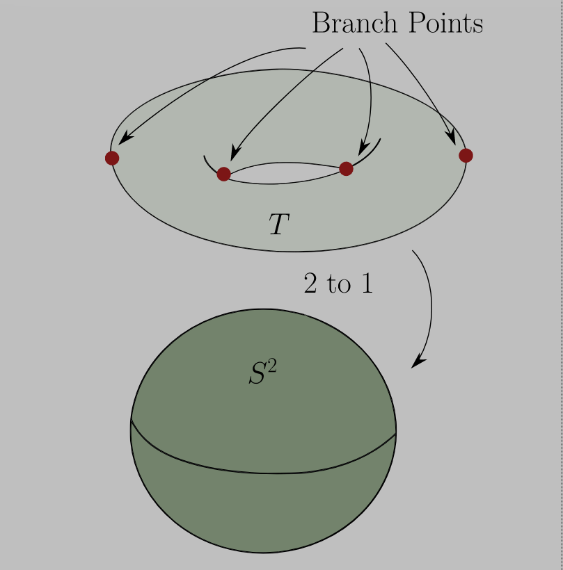

image_2021-02-25-20-41-53

Note that homothetic lattices define an isomorphism between the elliptic curves, and lattices mod homothety are in correspondence of elliptic curves. By acting $\operatorname{PGL}_2(C) \curvearrowright{\mathbb{P}}^1$ since $\operatorname{GL}_2$ acts on lines since scaling an element fixes a line. This is dimension 3. So elliptic curves are also in correspondence with $\left\{{ 4 \text{ points on } {\mathbb{P}}^1}\right\} / \operatorname{PGL}_2({\mathbb{C}})$ since this is now dimension 1. Note that by applying homothety, the two basis vectors for a lattice can be rescaled so one is length 1 and the other is a complex number $\tau$, and we can identify this space with ${\mathbb{H}}/ {\operatorname{SL}}_2({\mathbb{Z}})$.

Show that any $g(C) = 2$ curve has a degree 2 map to ${\mathbb{P}}^1$.

Similarly $g(C) = 3$ are usually a curve of degree $4$ in ${\mathbb{CP}}^2$. Severi proof in the 50s: false! issues with building moduli space for $g\geq 23$. Need to use orbifold structure to take into account automorphisms.

# 18 Wednesday, February 24

Last time:
$$\begin{align*}
\chi(C, L)
&= h^0(C, L) - h^1(C, L) \\
&= h^0(C, L) - h^0(C, L ^{-1} \otimes K_C) \\
&= \deg L + 1 -g
,\end{align*}
which is determined by purely topological information. We can generalize this to arbitrary ranks of the bundle and arbitrary dimensions of manifold:$$

Let $X$ be a compact complex manifold and let $\mathcal{E} \to X$ be a holomorphic vector bundle. Then
$$\begin{align*}
\chi( \mathcal{E} ) = \int_C \operatorname{ch}( \mathcal{E} ) \mathrm{td}(X)
.\end{align*}
The constituents here:$$

- The **Chern character**, summed over $R$ the *Chern roots*, which is in mixed cohomological degree.
  $$\begin{align*}
  \operatorname{ch}( \mathcal{E} ) \mathrel{\vcenter{:}}=\sum_{x_i \in R} e^{x_i} = \operatorname{ch}_0( \mathcal{E} ) + \operatorname{ch}_1( \mathcal{E} ) + \cdots + \operatorname{ch}_i( \mathcal{E} ) \in H^{2i}(X; {\mathbb{Q}})
  .\end{align*}$$
- The **Todd class**, defined as
  $$\begin{align*}
  \mathrm{td}( F) \mathrel{\vcenter{:}}=\prod_{x_i \in R} {x_i \over 1 - e^{-x_i} }
  \end{align*}
  where \(\mathrm{td}(X) \mathrel{\vcenter{:}}=\mathrm{td}(TX)\) is viewed as a complex vector bundle, which is again in mixed cohomological degree.$$

Note that integrating over cohomology classes in mixed degree is just equal to the integral over the top degree terms. Applying this to $X = C$ a curve and $\mathcal{E} \mathrel{\vcenter{:}}={\mathcal{O}}$, we obtain
$$\begin{align*}
\chi(C, {\mathcal{O}})
= \int_C \operatorname{ch}( {\mathcal{O}}) \mathrm{td}(C)
.\end{align*}$$

We have

- $\operatorname{ch}({\mathcal{O}}) = e^{c_1({\mathcal{O}})} = e^0 = 1$
- $\mathrm{td}(C) \mathrel{\vcenter{:}}=\mathrm{td}(TC) = c_1(TC) / (1- e^{ - c_1(TC) } )$, whose Taylor coefficients are the Bernoulli numbers. We can expand $x/(1 -e^{-x}) = 1 + (x/2) + (x^2/12) - x^4(720) + \cdots$, and since terms above degree 2 vanish, we have
  $$\begin{align*}
  \cdots
  &= \int_C 1 + \qty{ 1 + {c_1(TC) \over 2} } \\
  &= \int_C \qty{c_1(TC) \over 2 }\\
  &= {1\over 2} \chi_{\mathsf{Top}}(C) && \text{Chern-Gauss-Bonnet} \\
  &= {2-2g \over 2} \\
  &= 1-g
  .\end{align*}$$

We thus obtain
$$\begin{align*}
\chi(C, L)
&= \int_C \operatorname{ch}(L) \mathrm{td}(C) \\
&= \int_C (1 + c_1(L) ) \qty {1 + {c_1(L) \over 2} }\\
&= \int_C c_1(L) + {c_1(TC) \over 2} \\
&= \deg L + 1-g
.\end{align*}$$

Note that this is a better definition of genus than the previous one, which was just the correction term in Riemann-Roch. Here we can define it as $g \mathrel{\vcenter{:}}= h^1/2$.

Try to state and prove a Riemann-Roch formula for vector bundles on curves.

Let $S$ be a compact complex surface, i.e. $S\in {\mathsf{Mfd}}_{\mathbb{C}}^2$. An example might be $C\times D$ for $C,D$ two complex curves, or ${\mathbb{CP}}^2$. Let $L\to S$ be a holomorphic vector bundle. Then
$$\begin{align*}
\chi(L) = \chi({\mathcal{O}}_S) + {1\over 2} \qty{ L^2 - L \cdot K}
.\end{align*}
Note that \(L^2 \mathrel{\vcenter{:}}=\int_S c_1(L) c_1(L)\) is just shorthand for taking the intersection of \(L\) with itself. Recall that \(K \mathrel{\vcenter{:}}=\Omega_S^2\) is the space of holomorphic top forms.$$

Let $x_1, x_2$ be the Chern roots of $TS$. By HRR, we have
$$\begin{align*}
\chi(L)
&= \int_S \operatorname{ch}(L) \mathrm{td}(S) \\
&= \int_S \qty{ 1 + c_1(L) + {c_1(L)^2 \over 2!} } \qty{ {x_1 \over 1 - e^{-x_1} } {x_2 \over 1-e^{-x_2}} }\\
&= \int_S \qty{ 1 + c_1(L) + {c_1(L)^2 \over 2!} } \qty{1 + {x_1 \over 2} + {x_1^2 \over 12} }\qty{ 1 + {x_2 \over 2} + {x_2^2\over 12}} \\
&= \int_S \qty{ 1 + c_1(L) + {c_1(L)^2 \over 2!} } \qty{1 + {x_1 + x_2 \over 2} + {x_1^2 + x_2^2 + 3x_1 x_2 \over 12} } \\
&= \int_S \qty{ 1 + c_1(L) + {c_1(L)^2 \over 2!} } \qty{1 + {c_1(x_1, x_2) \over 2} + {c_1(x_1, x_2)^2 + c_2(x_1, x_2) \over 12 } } \\
&= \int_S \qty{ 1 + c_1(L) + {c_1(L)^2 \over 2!} } \qty{1 + { c_1(T) \over 2} + {c_1(T)^2 + c_2(T) \over 2 } } \\
&= \int_S {c_1(L)^2 \over 2} + {c_1(L) c_1(T) \over 2} + {c_1(T)^2 \over 2} + {c_2(T) \over 12} \quad \text{Take deg 4} \\
&= \int_S \qty{ c_1(L)^2 + c_1(L) c_1(T) \over 2} + \chi({\mathcal{O}}_S) \quad \text{HRR on last two terms}
.\end{align*}
where we’ve applied HRR to \({\mathcal{O}}_S\). It remains to show that \(c_1(T) = -c_1(K)\). We have
\begin{align*}
K = \Omega_S^2 = \bigwedge\nolimits^2 T^\vee
.\end{align*}
Note that \(\bigwedge\nolimits^{\text{top}} \mathcal{E} \mathrel{\vcenter{:}}=\det( \mathcal{E} )\) for any bundle \(\mathcal{E}\) since this is a 1-dimensional bundle. We have \(c_1(T) = -c_1(T^\vee)\) since the Chern roots of \(T^\vee\) are \(-x_1, -x_2\). So it suffices to show \(c_1(T^\vee) = c_1(K)\), but there is a general result that \(c_1(\mathcal{E}) = c_1( \det \mathcal{E} )\). This uses the splitting principle \(\mathcal{E} = \bigoplus_{i=1}^r L_i\) with \(x_i = c_1(L_i)\). We have \(c_1(\mathcal{E}) = \sum x_i\) and \(\det\mathcal{E} = \bigotimes_{i=1}^r L_i\), so \(\sum x_i = c_1(L_1\otimes\cdots \otimes L_r)\).$$

We want to use the following formula:
$$\begin{align*}
\chi(S, L) = \chi({\mathcal{O}}_S) = {1\over 2}(L^2 - L\cdot K)
.\end{align*}
This requires knowing \(\chi({\mathcal{O}}_S)\). Applying HRR yields
\begin{align*}
\chi({\mathcal{O}}_S)
&= \int_S {c_1(T)^2 + c_2(T) \over 12}\\
&= \int_S { (-c_1(K))^2 + c_2(T) \over 12}\\
&= {K^2 + \displaystyle\int_S c_2(T) \over 12}
,\end{align*}
so we just need to understand \(\int_S c_2(T)\). But for \(n=\operatorname{rank}\mathcal{E}\), \(c_n( \mathcal{E} )\) (the top Chern class) is the fundamental class of a zero locus of a section of \(\mathcal{E}\). Note that \(S \in {\mathsf{Mfd}}_{\mathbb{R}}^4\) is oriented, so \(\int_S c_2(T)\) is the signed number of zeros of a smooth vector field.$$

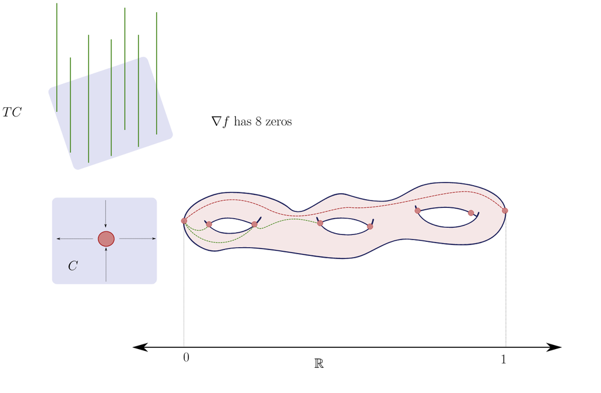

image_2021-02-25-20-42-49

Looking at the tangent bundle of the surface, the local sign of an intersection will be the number of incoming directions $\pmod 2$, i.e. the index of the critical point. Then the signed number of zeros here yields $1-6+1 = -4 = \chi_{{\mathsf{Top}}}(C)$. More generally, we have
$$\begin{align*}
\chi_{{\mathsf{Top}}}(M^n) = \int_C c_{n}(TM)
,\end{align*}
the Chern-Gauss-Bonnet formula. We can thus write
\begin{align*}
\chi({\mathcal{O}}_S) = {K^2 + \chi_{\mathsf{Top}}(S) \over 12 }
.\end{align*}$$

# 19 Friday, February 26

Last time: Riemann-Roch for surfaces, today we’ll discuss some examples. Recall that if $S \in {\mathsf{Mfd}}_{\mathbb{C}}^2$ is closed and compact (noting that $S\in {\mathsf{Mfd}}_{\mathbb{R}}^4$) and $L\to S$ is a holomorphic line bundle then
$$\begin{align*}
\chi(S, L) = \chi({\mathcal{O}}_S) + {1\over 2}(L^2 - L \cdot K)
\end{align*}
where \(K = c_1(K_S)\) for \(K_S \mathrel{\vcenter{:}}=\Omega_S^2\) the canonical bundle and \(L = c_1(L)\). We also saw
\begin{align*}
\chi({\mathcal{O}}_S) = {1\over 12}(K^2 + \chi_{{\mathsf{Top}}}(S))
,\end{align*}
where \(\chi_{\mathsf{Top}}\) is the Euler characteristic and is given by
\begin{align*}
\chi_{\mathsf{Top}}(S) = 2 h^0(S; {\mathbb{C}}) - 2 h^1(S, {\mathbb{C}}) + h^2(S; {\mathbb{C}})
.\end{align*}$$

Let $S = {\mathbb{CP}}^2$, which can be given in local coordinates by
$$\begin{align*}
\left\{{ [x_0: x_1: x_2 ] {~\mathrel{\Big|}~}(x_0, x_1, x_2) \in {\mathbb{C}}^3\setminus\left\{{0}\right\}}\right\}
\end{align*}
where we only take equivalence classes of ratios \([x,y,z] = [\lambda x, \lambda y, \lambda z]\) for any \(\lambda\in {\mathbb{C}}^{\times}\). This decomposes as
\begin{align*}
{\mathbb{CP}}^2 \cup{\mathbb{C}}\cup\left\{{ {\{\operatorname{pt}\}}}\right\} = \left\{{ [1: x_1: x_2] }\right\} \cup\left\{{ [0 : x_1: x_2] }\right\} \cup\left\{{ [0:0:1] }\right\}
,\end{align*}
i.e. we take \(x_0 \neq 0\), then \(x_0 = 0, x_1\neq 0\), then \(x_0 = x_1 = 0\). Note that
\begin{align*}
h^i({\mathbb{CP}}^n; {\mathbb{Z}}) =
\begin{cases}
{\mathbb{Z}}& 0 \leq i \leq 2n \text{ even}
\\
0 & \text{else}.
\end{cases}
\end{align*}$$

We can use this to conclude that $\chi_{\mathsf{Top}}({\mathbb{CP}}^n) = n+1$ and $\chi_{\mathsf{Top}}({\mathbb{CP}}^2) = 3$. Over ${\mathbb{CP}}^n$ we have a **tautological line bundle** ${\mathcal{O}}(-1)$ given by sending each point to the corresponding line in ${\mathbb{C}}^{n+1}$, i.e. ${\mathcal{O}}(-1) \to {\mathbb{CP}}^n$ given by
$$\begin{align*}
\lambda (x_0, \cdots, x_n) \mapsto [x_0: \cdots: x_n]
.\end{align*}
Note that the total space is \(\operatorname{Bl}_0({\mathbb{C}}^{n+1})\) is the blowup at zero, which separates the tangents at 0.$$

Let $X$ be an algebraic variety, i.e. spaces cut out by polynomial equations, for example $\left\{{ xy = 0 }\right\} \subseteq {\mathbb{C}}^2$ which has a singularity at the origin. A **divisor** is a ${\mathbb{Z}}{\hbox{-}}$linear subvariety of codimension 1. Note that for a curve $X$, this gives back the definition in terms of points. For $D$ a divisor on $X$, we associated a bundle ${\mathcal{O}}_X(D)$ which had a meromorphic section with a zero/pole locus whose divisor was precisely $D$.

Recall the construction: we chose a point, then a trivializing neighborhood where the transition functions where $V$.

[figure not shown]

For a higher dimensional algebraic variety or complex manifold, for $D$ a complex submanifold, pick a chart around a point that the nearby portion of $D$ to a coordinate axis in ${\mathbb{C}}^n$, which e.g. can be given by $\left\{{ z_1 = 0 }\right\}$.

[figure not shown]

As before there’s a distinguished section $s_D \in H^0(X; {\mathcal{O}}_X(D) )$ vanishing along $D$. Note that a line bundle is a free rank 1 ${\mathcal{O}}{\hbox{-}}$module, and analogously here the functions vanishing along $D$ are ${\mathcal{O}}{\hbox{-}}$modules generated by (here) $z_1$.

A **hyperplane** in ${\mathbb{CP}}^n$ is any set of the form
$$\begin{align*}
H = \left\{{ [x_0: \cdots : x_1 ] {~\mathrel{\Big|}~}\sum a_i x_i = 0 }\right\} \cong {\mathbb{CP}}^{n-1}
.\end{align*}$$

Take ${\mathbb{CP}}^{n-1} \subseteq {\mathbb{CP}}^n$, e.g. $\left\{{ x_0 = 0 }\right\}$. This is an example of a **divisor** on ${\mathbb{CP}}^n$, i.e. a complex codimension 1 “submanifold.” We can take the line bundle constructed above to get ${\mathcal{O}}_{{\mathbb{CP}}^n}({\mathbb{CP}}^{n-1})$ which vanishes along ${\mathbb{CP}}^{n-1}$. More generally, for any hyperplane $H$ we can take ${\mathcal{O}}_{{\mathbb{CP}}^n}(H)$, and these are all isomorphic, so we’ll denote them all by ${\mathcal{O}}_{{\mathbb{CP}}^n}(1)$. The implicit claim is that is the inverse line bundle of the tautological bundle, so ${\mathcal{O}}(1) \otimes{\mathcal{O}}(-1)$ is the trivial bundle since the transition functions are given by reciprocals and multiplying them yields 1. We can classify complex line bundles on ${\mathbb{CP}}^n$ using the SES
$$\begin{align*}
0 \to \underline{{\mathbb{Z}}} \to {\mathcal{O}}\xrightarrow{\exp} {\mathcal{O}}^{\times}\to 1
.\end{align*}$$

We know that $H^1(X; {\mathcal{O}}^{\times})$ were precisely holomorphic line bundles, since they were functions agreeing on double overlaps with a cocycle condition. We have a LES coming from sheaf cohomology:

[figure not shown]

> Link to Diagram

Applying this to $X\mathrel{\vcenter{:}}={\mathbb{CP}}^n$, we have $H^1({\mathcal{O}}) = H^2({\mathcal{O}}) = 0$. This can be computed directly using that ${\mathbb{CP}}^n = \cup_{n\geq 1} {\mathbb{C}}^n$ by taking charts $x_i\neq 0$, and this yields an acyclic cover. Thus $c_1$ is an isomorphism above, and ${\operatorname{Pic}}({\mathbb{CP}}^n) \cong {\mathbb{Z}}$, where ${\operatorname{Pic}}$ denotes isomorphism classes of line bundles. We can identify ${\operatorname{Pic}}({\mathbb{CP}}^n) = \left\{{ {\mathcal{O}}_{{\mathbb{CP}}^n}(k) {~\mathrel{\Big|}~}k\in {\mathbb{Z}}}\right\}$.

# 20 Monday, March 01

Last time: we defined ${\operatorname{Pic}}({\mathbb{CP}}^n)$ as the set of line bundles on ${\mathbb{CP}}^n$.

Given any $X\in {\mathsf{Mfd}}_{\mathbb{C}}$, define ${\operatorname{Pic}}(X)$ as the set of isomorphism classes of holomorphic line bundles on $X$. This is an abelian group given by $L \otimes L'$ and inversion $L\to L^{-1}$.

We saw that ${\operatorname{Pic}}(X) \cong H^1(X; {\mathcal{O}}^{\times})$ as groups, noting that $H^1$ has a natural group structure here. We defined a **tautological bundle** on ${\mathbb{CP}}^n$ and saw it was isomorphic to ${\mathcal{O}}(-1)$, and moreover ${\mathcal{O}}(H) \cong {\mathcal{O}}(1)$ for $H$ a hyperplane. The fiber was given by
$$\begin{align*}
\mathrm{Taut} &\to {\mathbb{CP}}^n \\
\left\{{ \lambda (x_0, \cdots, x_n) {~\mathrel{\Big|}~}\lambda\in {\mathbb{C}}}\right\} &\mapsto [x_0: \cdots : x_n]
,\end{align*}
i.e. the entire line corresponding to the given projective point. We also have \({\mathcal{O}}(H)(U)\) is the sect of rational homogeneous functions \(\phi\) on \(U\) of degree 1 such that \(\operatorname{Div}\phi + H \geq 0\) where \(H \mathrel{\vcenter{:}}=\left\{{x_0 = 0}\right\}\). We want \(\phi/x_0\) to be a well-defined function, so \(\phi\) should scale like \(x_0\) in the sense that
\begin{align*}
\phi( \lambda x_0, \cdots, \lambda x_n) = \lambda\phi( x_0, \cdots, x_n)
.\end{align*}
Note that there is a natural map
\begin{align*}
{\operatorname{Taut}}\otimes{\mathcal{O}}(H) \xrightarrow{} {\mathcal{O}}
,\end{align*}
given by taking the line over a point and evaluating the homogeneous function on that line. Thus \({\operatorname{Taut}}\) is the inverse of \({\mathcal{O}}(H)\).$$

We want to understand what Noether’s formula says for ${\mathbb{CP}}^2$, which requires understanding the canonical bundle $K_{{\mathbb{CP}}^n}$. We’ll do this by writing down a meromorphic section $\omega$ (since it’s a meromorphic volume form) which will yield $K_{{\mathbb{CP}}^n} = {\mathcal{O}}(\operatorname{Div}\omega)$. So take
$$\begin{align*}
\omega \mathrel{\vcenter{:}}= x_1^{-1}dx_1 \wedge \cdots \wedge x_n^{-1}dx_n
,\end{align*}
noting that we leave out the first coordinate \(x_0\) and divide by coordinates to make this scale-invariant. Here we work in a \({\mathbb{C}}^n\) chart of points of the form \([1: x_1 : \cdots : x_n]\). Where does \(\omega\) have poles? Along \(x_i = 0\) for any \(1\leq i \leq n\), and similarly in any other coordinate chart. We also have a 1st order pole along \(x_0 = 0\). We then get
\begin{align*}
K_{{\mathbb{CP}}^n} = {\mathcal{O}}(\operatorname{Div}\omega) = {\mathcal{O}}( -H_0 -H_1 - \cdots - H_n) = {\mathcal{O}}(-n-1)
,\end{align*}
where \(H_i = \left\{{x_i = 0}\right\}\).$$

Note that ${\mathbb{CP}}^n$ is like a simplex:

[figure not shown]

Applying this to ${\mathbb{CP}}^2$, we obtain
$$\begin{align*}
K_{{\mathbb{CP}}^2} = {\mathcal{O}}(-3)
.\end{align*}
What is the intersection form? We know \(H^2({\mathbb{CP}}^2; {\mathbb{Z}}) \cong {\mathbb{Z}}\) and the intersection form is unimodular. So write \({\mathbb{Z}}\mathrel{\vcenter{:}}={\mathbb{Z}}\alpha\) for \(\alpha\) some generator. Then \(\alpha \cdot \alpha = \pm 1\) since \(\det G = \pm 1\) for the Gram matrix for this to be unimodular. Note that \((- \alpha) \cdot (- \alpha) = \pm 1\) with the same sign.$$

${\mathcal{O}}(1) = {\mathcal{O}}(H)$ generates ${\operatorname{Pic}}({\mathbb{CP}}^2) = H^2({\mathbb{CP}}^2; {\mathbb{Z}})$.

This is because $c_1 {\mathcal{O}}(H) \cdot c_1 {\mathcal{O}}(H) = H\cdot H = \left\{{ x_0 = 0 }\right\} \pitchfork\left\{{ x_1 = 0 }\right\} = \left\{{ [0:0:1] }\right\}$ here we note that the two hyperplanes can be oriented transversely and intersected. This is an oriented intersection.

$S^4$ has no complex structure.

We know that $\chi_{\mathsf{Top}}(S^4) = 2$. If $S^4$ had a complex structure, then $c_1(K_{S^4}) \in H^2(S^4; {\mathbb{Z}}) = 0$. Thus would make $K_{S^4}^2 = 0$, and so
$$\begin{align*}
\chi( {\mathcal{O}}_{S^4} ) = {1\over 12}( 0 + 2) = {1\over 6} \not\in {\mathbb{Z}}
,\end{align*}$$

which is a contradiction. $\contradiction$

Consider $\mkern 1.5mu\overline{\mkern-1.5mu{\mathbb{CP}}\mkern-1.5mu}\mkern 1.5mu^2$, a 4-manifold diffeomorphic to ${\mathbb{CP}}^2$ with the opposite orientation. What is the intersection form? Taking $H\cdot H = -1$ since the orientations aren’t compatible, and more generally the Gram matrix is negated when the orientation is reversed.

$\mkern 1.5mu\overline{\mkern-1.5mu{\mathbb{CP}}\mkern-1.5mu}\mkern 1.5mu^2$ is not diffeomorphic to a complex surface by an orientation-preserving diffeomorphism (or any homeomorphism).

We have $\chi_{\mathsf{Top}}= 3$, and $K_{\mkern 1.5mu\overline{\mkern-1.5mu{\mathbb{CP}}\mkern-1.5mu}\mkern 1.5mu^2} = -c_1(T \mkern 1.5mu\overline{\mkern-1.5mu{\mathbb{CP}}\mkern-1.5mu}\mkern 1.5mu^2) = \pm 3H$. Then
$$\begin{align*}
\chi({\mathcal{O}}) = {1\over 12}\qty{ K_{\mkern 1.5mu\overline{\mkern-1.5mu{\mathbb{CP}}\mkern-1.5mu}\mkern 1.5mu^2}^2 + \chi_{\mathsf{Top}}} = {1\over 12}(-9+3) \not\in {\mathbb{Z}}
.\end{align*}$$

Consider ${\mathcal{O}}_{{\mathbb{CP}}^n}(d)$, what are its global sections $H^0({\mathbb{CP}}^n, {\mathcal{O}}_{{\mathbb{CP}}^n}(d))$. Locally we have ${\mathcal{O}}_{{\mathbb{CP}}^n}(d)(U)$ given by holomorphic functions in $(x_0, \cdots, x_n) \in \pi^{-1}(U)$ where $\pi: {\mathbb{C}}^{n+1} \to {\mathbb{CP}}^n$ and the functions satisfy $f(\lambda \mathbf{x}) = \lambda^d f(\mathbf{x})$. The global sections will be the homogeneous degree $d$ polynomials in the coordinates of $\mathbf{x}$.

Why does a holomorphic function $f: {\mathbb{C}}^{n+1} \to {\mathbb{C}}$ such that $f(\lambda \mathbf{x}) = \lambda^d f(\mathbf{x})$ necessarily a polynomial? Use the result that any such function with at most polynomial growth is itself a polynomial. If ${ \left.{{f}} \right|_{{S^{2d+1}}} }$ is bounded by $C$, we have ${\left\lVert {f} \right\rVert}_{L^2} \leq C {\left\lvert {x} \right\rvert}^{2d}$. Since $({{\partial}}_{x_1} \cdots {{\partial}}_{x_k})^d f$ is globally bounded $k\geq 2d$, applying Liouville’s theorem makes it constant, and so a finite number of derivatives kill $f$ and this forces it to be polynomial.

So how many homogeneous degree $d$ functions are there? Here $h^0({\mathbb{CP}}^n, {\mathcal{O}}(d)) =$ will be the number of linearly independent degree $d$ polynomials in the variables $x_0, \cdots, x_n$, which is ${\left(\kern-.3em\left(\genfrac{}{}{0pt}{}{n+1}{d}\right)\kern-.3em\right)} = {n + d\choose n}$, using the fact that monomials span this space.

Using that $h^0({\mathbb{CP}}^2; {\mathcal{O}}(k))= h^2({\mathbb{CP}}^2; {\mathcal{O}}(-3-k) )$ by Serre duality and Riemann-Roch, compute $h^i({\mathbb{CP}}^2; {\mathcal{O}}(k))$ for all $i, k$.

$h^i({\mathbb{CP}}^n; {\mathcal{O}}(k)) = 0$ unless $i=0, n$.

# 21 Wednesday, March 03

Find first 5m.

When we considered $\mkern 1.5mu\overline{\mkern-1.5mu{\mathbb{CP}}\mkern-1.5mu}\mkern 1.5mu^2$, we implicitly assumed $T\mkern 1.5mu\overline{\mkern-1.5mu{\mathbb{CP}}\mkern-1.5mu}\mkern 1.5mu^2$ was a complex rank 2 vector bundle with some purported complex structure.

$$\begin{align*}
c_1( T\mkern 1.5mu\overline{\mkern-1.5mu{\mathbb{CP}}\mkern-1.5mu}\mkern 1.5mu^2) = \pm 3H
,\end{align*}
although it’s not clear that \(c_1(K) \in H^2( \mkern 1.5mu\overline{\mkern-1.5mu{\mathbb{CP}}\mkern-1.5mu}\mkern 1.5mu^2; {\mathbb{Z}}) \cong ({\mathbb{Z}}, [-1] )\).$$

We had $\chi({\mathcal{O}}) = {1\over 12} \qty{ K^2 + \chi_{\mathsf{Top}}} = {1\over 12}(3-n^2)$, and since $3-n^2 \in 12{\mathbb{Z}}$, we have $n^2 \in 3 + 12{\mathbb{Z}}\subset 3 + 4{\mathbb{Z}}$ and this forces $n^2 \equiv 3 \pmod 4$.

Let
$$\begin{align*}
0 \to \mathcal{E}^0 \xrightarrow{d_0} \mathcal{E}^1 \xrightarrow{d_1} \cdots \to \mathcal{E}^n \to 0
\end{align*}
be a complex (so \(d^2 = 0\)) of smooth vector bundles on a smooth manifold \(X\operatorname{im}{\mathsf{Mfd}}_{\mathbb{R}}^{C^\infty}\). Suppose that the \(d_i\) are differential operators, i.e. in local trivializing charts over \(U\) we have$$

$$\begin{align*}
\mathcal{E}^i \cong {\mathcal{O}}^{\oplus r_i} {\mathcal{O}}^{\oplus r_{i+1}} \cong \mathcal{E}^{i+1}
\end{align*}
where in every matrix coordinate, \(d_i\) is of the form \(\sum_{{\left\lvert {I} \right\rvert} < N} g_I {{\partial}}_I\) where \({{\partial}}_I \mathrel{\vcenter{:}}={{\partial}}_{i_1} \cdots {{\partial}}_{i_N}\) is a partial derived and the \(g_I\) are smooth functions.$$

For $X\in {\mathsf{Mfd}}_{\mathbb{R}}^{C^ \infty }$, we can take
$$\begin{align*}
0 \to {\mathcal{O}}\xrightarrow{d} \Omega^1 \xrightarrow{d} \Omega^2 \xrightarrow{d} \cdots
.\end{align*}
In local coordinates,$$

- $\Omega^1$ is spanned over ${\mathcal{O}}$ by $dx_1, \cdots, dx_n$ where $n = \dim_{\mathbb{R}}(X)$
- $\Omega^2$ is spanned over ${\mathcal{O}}$ by $dx_i \wedge dx_j$ for $1\leq i, j \leq n$.

Then the component of $d$ sending $dx_i \to dx_i \wedge dx_j$ is of the form
$$\begin{align*}
fdx_i &\mapsto -{\frac{\partial f}{\partial x_j}\,} dx_i \wedge dx_j
.\end{align*}$$

For $X\in {\mathsf{Mfd}}_{\mathbb{C}}$ and $\mathcal{E} \to X$ a holomorphic vector bundle, take
$$\begin{align*}
\mathcal{E} \otimes A^{0,0} \xrightarrow{\mkern 1.5mu\overline{\mkern-1.5mu{\partial}\mkern-1.5mu}\mkern 1.5mu} \mathcal{E} \otimes A^{0, 1} \xrightarrow{\mkern 1.5mu\overline{\mkern-1.5mu{\partial}\mkern-1.5mu}\mkern 1.5mu} \mathcal{E} \otimes A^{0, 2} \to \cdots
.\end{align*}
This is because for \(s_i\) local holomorphic sections and \(\omega\) a smooth form we have
\begin{align*}
\mkern 1.5mu\overline{\mkern-1.5mu{\partial}\mkern-1.5mu}\mkern 1.5mu\qty{ (s_1, \cdots, s_r) \otimes\omega } = \qty{s_1, \cdots, s_r} \otimes\mkern 1.5mu\overline{\mkern-1.5mu{\partial}\mkern-1.5mu}\mkern 1.5mu\omega
.\end{align*}$$

The maximal $N$ that appears in $\sum_{ {\left\lvert {I} \right\rvert} \leq N} g_I {{\partial}}_I$ is the **order**.

The **symbol complex** is a sequence of vector bundles on $T^\vee X$. Noting that we have $\pi: T^\vee X\to X$, and using pullbacks we can obtain bundles over the cotangent bundle:
$$\begin{align*}
0 \to \pi^* \mathcal{E}_0 \xrightarrow{\sigma(d_0)} \pi^* \mathcal{E}_1 \xrightarrow{\sigma(d_1)} \cdots \to \pi^* \mathcal{E}_n \to 0
.\end{align*}
The symbol of the differential operator \(d_i\) is \(\sigma(d_i)\). It is defined by replacing \({\partial}_i\) in \(\sum_{{\left\lvert {I} \right\rvert} {\color{red} =} N } g_I {\partial}_I\) with \(y_i\) where
\begin{align*}
y_i: T^\vee U \to {\mathbb{R}}
\end{align*}
is the coordinate function on the second factor of \(T^\vee U = U \times{\mathbb{R}}^n\) associated to the local coordinate \(i\). Using that \(TU = (T^\vee)^\vee U\), we can view \({\partial}_i\) as functions on the cotangent bundle, \(\sigma(d_i)\) is given in local trivializations by multiplication by a smooth function \(\sum_{{\left\lvert {I} \right\rvert} = N} g_I y^I\).$$

Consider ${\mathcal{O}}\xrightarrow{d} \Omega^1$. In local coordinates, this is given by $d = \qty{{\partial}_1, \cdots, {\partial}_n}$, i.e. coordinate-wise differentiation, since we can write a local trivialization $\Omega^1 = {\mathcal{O}}dz_1 \oplus \cdots \oplus {\mathcal{O}}dz_n$. Then the symbol of $d$ is given by
$$\begin{align*}
\sigma(d): \pi^* {\mathcal{O}}&\to \pi^* \Omega^1 \\
1 &\mapsto (y_1, \cdots, y_n)
,\end{align*}
thought of as vector bundles over \(T^\vee X\), and this is projection onto to cotangent factor. Locally, the image of 1 is given by \(y_1 dx_1 + \cdots y_n dx_n\), which is a point in \(T_p^\vee X\) for all \((p, \alpha) \in T^\vee X\) which is an assignment to every point \((p, \alpha) \in T_p^\vee X\) a point in \((\pi^* \Omega^1)_{p, \alpha} \cong T_p^\vee X\). There is a tautological section \((p, \alpha) \to \alpha\in T_p^\vee X\in (\pi^* \Omega^1)_{p, \alpha}\), or really \((p, \alpha) \mapsto ( (p, \alpha), \alpha)\).$$

See similarly to the canonical symplectic structure of the cotangent bundle.

More generally, for $d: \Omega^p \to \Omega^{p+1}$, $\sigma(d)$ acts on the frame $dx_{i_1} \wedge \cdots dx_{i_p}$ in the following way:
$$\begin{align*}
\sigma(d)(dx_{i_1} \wedge \cdots \wedge dx_{i_p}) = \sum_y y_y dx_j \wedge dx_{i_1} \wedge \cdots dx_{i_p}
\end{align*}
where
\begin{align*}
d: fdx_{i_1} \wedge \cdots \wedge dx_{i_p} \mapsto \sum_j {\frac{\partial f}{\partial x_j}\,} dx_j \wedge \qty{dx_{i_1} \wedge \cdots \wedge dx_{i_p}}
.\end{align*}
The symbol complex is
\begin{align*}
\pi^* {\mathcal{O}}\xrightarrow{\sigma(d)} \pi^* \Omega^1 \xrightarrow{\sigma(d)} \pi^* \Omega^2 \to \cdots \to \pi^* \Omega^n \to 0
\end{align*}
for \(n\) the dimension. In this case, \(\sigma(d)\) has the same formula everywhere, since it’s \(C^ \infty {\hbox{-}}\)linear:
\begin{align*}
\sigma(d) = \sum_j y_j dx_j \wedge \qty{\cdots}
.\end{align*}$$

A differential complex $({\mathcal{E}}_{*}, d)$ is **elliptic** if the symbol complex $(\pi^* {\mathcal{E}}_{*}, \sigma(d))$ is an exact sequence of sheaves (importantly) on $T^\vee X \setminus\left\{{s_z}\right\}$ for $s_z$ the zero section.

$({\Omega}_{*}, d)$ is elliptic. To check exactness of a sequence of vector bundles, it suffices to check exactness on every fiber. Fix $(p, \alpha) \in T^\vee X \setminus\left\{{ s_z }\right\}$, then
$$\begin{align*}
0 \to {\mathbb{C}}\xrightarrow{\wedge \alpha} T^\vee_p X \xrightarrow{\wedge \alpha} \bigwedge^2 T_p^\vee X \xrightarrow{\wedge \alpha} \bigwedge^3 T_p^\vee X \to \cdots
.\end{align*}
Moreover, if \(\alpha\wedge \beta = 0\) implies that \(\beta = \alpha\wedge \gamma\) for some \(\gamma\), which implies that this sequence is exact.$$

# 22 Friday, March 05

Recall that we set up a differential complex, whose objects were vector bundles and differentials were differential operators (i.e. linear combinations of partial derivatives) in local trivializations. We pulled back to tangent bundles (?) and defined the *symbol* of an operator, and saw that when taking the symbol complex of the deRham complex. the sequence of maps was given by wedging against a tautological one-form. This was an *elliptic complex* because the maps became wedging with a covector.

Let $X\in {\mathsf{Mfd}}_{\mathbb{C}}$ and $\mathcal{E}\to X \in {\mathsf{VectBundle}}_{\mathbb{C}}$ be holomorphic. There is a resolution
$$\begin{align*}
0 \to \mathcal{E} \xrightarrow{i} \mathcal{E} \otimes A^{0, 0} \xrightarrow{\mkern 1.5mu\overline{\mkern-1.5mu{\partial}\mkern-1.5mu}\mkern 1.5mu} \mathcal{E} \otimes A^{0, 1} \xrightarrow{\mkern 1.5mu\overline{\mkern-1.5mu{\partial}\mkern-1.5mu}\mkern 1.5mu} \cdots
.\end{align*}
What is the symbol complex? Consider the projection \(\pi: T^\vee X\to X\), and use pullbacks to get a sequence
\begin{align*}
0 \to \pi^* \mathcal{E} \otimes A^{0, 0} \xrightarrow{\sigma( \mkern 1.5mu\overline{\mkern-1.5mu{\partial}\mkern-1.5mu}\mkern 1.5mu)} \pi^* \mathcal{E} \otimes A^{0, 1} \xrightarrow{\sigma( \mkern 1.5mu\overline{\mkern-1.5mu{\partial}\mkern-1.5mu}\mkern 1.5mu)} \cdots
.\end{align*}
Here the symbol \(\sigma(\mkern 1.5mu\overline{\mkern-1.5mu{\partial}\mkern-1.5mu}\mkern 1.5mu)\) replace \({\frac{\partial }{\partial t {\overline{{z}}}_i}\,}\) with the corresponding function on \(T^\vee X\), say \({\overline{{y}}}_i\). Then \(\sigma( \mkern 1.5mu\overline{\mkern-1.5mu{\partial}\mkern-1.5mu}\mkern 1.5mu) = \sum_i {\overline{{y}}}_i \, d{\overline{{z}}}_i \wedge ({\,\cdot\,}) = {\overline{{ \alpha }}} \wedge ({\,\cdot\,})\). As before, at a point \((p, \alpha)\) where \(\alpha\neq 0\) in \(T^\vee X\), we get
\begin{align*}
0 \to \mathcal{E}_p \xrightarrow{{\overline{{ \alpha}}} \wedge ({\,\cdot\,})} \mathcal{E}_p \otimes\bigwedge^{0, 1}_p X \xrightarrow{{\overline{{ \alpha }}} \wedge ({\,\cdot\,})} \mathcal{E}_p \otimes\bigwedge^{0, 2} X \to \cdots
,\end{align*}
which is an exact sequence of vector spaces. So \(( \mathcal{E} \otimes A^{0, p}, \mkern 1.5mu\overline{\mkern-1.5mu{\partial}\mkern-1.5mu}\mkern 1.5mu)\) is an elliptic complex.$$

The symbol being exact is approximately the top-order part being nowhere-vanishing.

The next theorem computes the cohomology of an elliptic complex using Chern and Todd classes.

If $( {\mathcal{E}}_{*}, d)$ is an elliptic complex of smooth vector bundles on a compact oriented $X\in {\mathsf{Mfd}}^n_{\mathbb{R}}$, then
$$\begin{align*}
\chi({ \mathcal{E} }_{*}, d) = \sum (-1)^i \dim \qty{\ker d^i \over \operatorname{im}d^{i-1} } =
(-1)^{\dim(X) \choose 2}
\int_X {\operatorname{ch}\over {\operatorname{eul}}}( {\mathcal{E}}_{*} ) \mathrm{td}(TX \otimes_{\mathbb{R}}{\mathbb{C}})
.\end{align*}$$

Here we define $\operatorname{ch}( {\mathcal{E}}_{*} \mathrel{\vcenter{:}}=\sum_i (-1)^i \operatorname{ch}( \mathcal{E}^i )$. What does it mean to divide by the Euler class? Let $\left\{{ x_i, -x_i }\right\}$ be the Chern roots of the complexified tangent bundle $TX\otimes{\mathbb{C}}$, then ${\operatorname{eul}}(X) \mathrel{\vcenter{:}}=\prod x_i$ is the product where we pick one of each of the Chern roots from each of the pairs. The preferred sign to choose is the one for which $\int_X \prod x_i = \chi_{\mathsf{Top}}(X)$. Dividing just means to take the Chern character, then if it’s divisible by $\prod x_i$, we do so. We have
$$\begin{align*}
\mathrm{td}(TX\otimes{\mathbb{C}}) = \prod_i
\qty{x_i \over 1 - e^{-x_i}}
\qty{-x_i \over 1 - e^{-x_i}}
.\end{align*}$$

Thus
$$\begin{align*}
{\mathrm{td}(TX\otimes{\mathbb{C}}) \over {\operatorname{eul}}(X) } =
\prod_i {1\over x_i}
\qty{x_i \over 1 - e^{-x_i}}
\qty{-x_i \over 1 - e^{-x_i}}
,\end{align*}
but note that this doesn’t necessarily make sense. However, all all computations we’ll see, there will be enough cancellation to make this well-defined.$$

$\operatorname{ch}( {\Omega}_{*}X \otimes{\mathbb{C}}) = \prod_i (1-e^{x_i}) (1 - e^{-x_i})$ for $X\in {\mathsf{Mfd}}_{\mathbb{R}}^{2n}$ even dimensional.

Supposing $X\in {\mathsf{Mfd}}_{\mathbb{R}}^2$ is a genus $g$ surface, we have
$$\begin{align*}
{\mathcal{O}}\to \Omega^1\otimes{\mathbb{C}}\to \Omega^2 \otimes{\mathbb{C}}
,\end{align*}
and \(\operatorname{ch}({ \Omega }_{*}) = \operatorname{ch}( {\mathcal{O}}) - \operatorname{ch}( \Omega^1 \otimes{\mathbb{C}}) + \operatorname{ch}(\Omega^2\otimes{\mathbb{C}})\). The Chern roots of \(TX \otimes{\mathbb{C}}\) are \(\left\{{ x_i, -x_i }\right\}\), which come in pairs. So
\begin{align*}
\operatorname{ch}( {\Omega}_{*} )
= 1 - e^{x_i} - e^{x_i} + e^{-x_i + x_i}
= (1 - e^{-x_i})( 1 - e^{x_i} )
.\end{align*}
From the theorem, we’re supposed to have
\begin{align*}
\chi( {\Omega}_{*}, d)
&=
(-1)^{n(n-1) \over 2}
\int_X
{\prod_i (1 - e^{-x_i})( 1 - e^{x_i} ) \over \prod_{i=1}^n x_i }
\prod_i
\qty{x_i \over 1 - e^{-x_i}}
\qty{-x_i \over 1 - e^{-x_i}} \\
&=
(-1)^{n(n-1) \over 2}
\int_X
\prod_{i=1}^n (-x_i)\\
& = \int_X
\prod_i x_i \\
&=
\chi_{\mathsf{Top}}(X) && \text{C-G-B}
.\end{align*}
Letting \(d=\dim X = 2n\), we have
\begin{align*}
(-1)^n (-1)^{d(d-1) \over 2} = (-1)^n (-1)^{n(2n-1)} = (-1)^2n = 1 .
\end{align*}$$

We have prove HRR using this theorem: we have
$$\begin{align*}
\chi(X, \mathcal{E} ) = \chi( \mathcal{E} \otimes A^{0, {\,\cdot\,}}, \mkern 1.5mu\overline{\mkern-1.5mu{\partial}\mkern-1.5mu}\mkern 1.5mu) \overset{\text{ASIT}}{=} \int_X { \operatorname{ch}(\mathcal{E} \otimes A^{0, {\,\cdot\,}} ) \over {\operatorname{eul}}(X) } \mathrm{td}(TX \otimes_R {\mathbb{C}})
.\end{align*}
We have \(\operatorname{ch}( \mathcal{E} \otimes A^{0, {\,\cdot\,}} ) = \operatorname{ch}(\mathcal{E}) \operatorname{ch}( A^{0, {\,\cdot\,}} )\) where \(\operatorname{ch}(A^{0, 1}) = \sum_I (-1)^i \operatorname{ch}(\bigwedge^i A^{0, 1} )\). The Chern roots of$$

- $TX$ are $\left\{{ x_i }\right\}$
- $A^{1, 0} = T^\vee X$ are $\left\{{ -x_i }\right\}$
- $A^{0, 1}$ are $\left\{{ -x_i }\right\}$

So we obtain
$$\begin{align*}
\chi( \mathcal{E} )
&= (-1)^n \int_X {\prod ( 1- e^{x_i}) \over \prod x_i}
\prod_i
\qty{x_i \over 1 - e^{-x_i}}
\qty{-x_i \over 1 - e^{-x_i}} \\
&= \int_X \operatorname{ch}( \mathcal{E} ) \prod_i {x_i \over 1-e^{-x_i} } \\
&= \int_X \operatorname{ch}( \mathcal{E} ) \mathrm{td}(TX)
,\end{align*}
which is HRR.$$

# 23 Monday, March 08

Recall that given a differential complex $({ \mathcal{E} }_{*}, d)$ we had a symbol complex $( \pi^* {\mathcal{E}}_{*}, \sigma(d) )$ where $\pi: T^\vee X\to X$ and
$$\begin{align*} \sigma\qty{ \sum_{{\left\lvert {I} \right\rvert} \leq N} f_I {{\partial}}_I } \mathrel{\vcenter{:}}=\sum_{{\left\lvert {I} \right\rvert} = N} f_I y^I
,\end{align*}
where we take the top-order differentials, \({\frac{\partial }{\partial x_j}\,} \mapsto y_j\) and
\begin{align*}
T^\vee X &\to {\mathbb{R}}\\
\alpha &\mapsto \alpha\qty{{\frac{\partial }{\partial x_j}\,} }
.\end{align*}
We say that \(( {\mathcal{E} }_{*}, d )\) is elliptic if the symbol complex is exact on \(T^\vee X \setminus\left\{{0}\right\}\) where we delete the zero section. The Atiyah-Singer index theorem stated
\begin{align*}
\chi( {\mathcal{E}}_{*}, d) = \int_X { \operatorname{ch}( { \mathcal{E} }_{*}) \over {\operatorname{eul}}(X) } \mathrm{td}( TX\otimes_{\mathbb{R}}{\mathbb{C}})
.\end{align*}
What’s the connection to elliptic operators? Given a 2-term complex
\begin{align*}
0 \to \mathcal{E}^0 \xrightarrow{D} \mathcal{E}^1 \to 0
,\end{align*}
then \(D\) is an elliptic operator if this is an elliptic complex. This means the symbol complex is an isomorphism, i.e.
\begin{align*}
0 \to \pi^* \mathcal{E}^0 \xrightarrow{\sigma(D)} \pi^* \mathcal{E}^1 \to 0
\end{align*}
where \(\sigma(D)\) is an isomorphism away from the zero section.$$

Every elliptic complex can be converted into a 2-term complex using a hermitian metric. Given
$$\begin{align*}
\mathcal{E}^0 \xrightarrow{d^0} \mathcal{E}^1 \xrightarrow{d^1} \mathcal{E}^2 \to \cdots
,\end{align*}
we map this to
\begin{align*}
0 \to \mathcal{E}^{\text{even}} \mathrel{\vcenter{:}}=\bigoplus_{i \text{ even} } \mathcal{E}^i
\mathrel{\operatorname*{\rightleftharpoons}_{D^{\text{odd} }}^{D^\text{even}}}
\mathcal{E}^{\text{odd}} \mathrel{\vcenter{:}}=\bigoplus_{i \text{ odd}} \to 0
\end{align*}
where
\begin{align*}
D \mathrel{\vcenter{:}}=((d^{2i-1})^{\dagger} , d^{2i} ) : \mathcal{E}^{2i} \to \mathcal{E}^{2i-1} \oplus \mathcal{E}^{2i+2} \\
\end{align*}
and \((d^{2i-1})^{\dagger}\) is defined by the following property: for \(\alpha\in \mathcal{E}^{2i-1}\) and \(\beta \in \mathcal{E}^{2i}(X)\),
\begin{align*}
{\left\langle { d^{2i-1} \alpha},~{\beta} \right\rangle}_h = {\left\langle { \alpha },~{ ( (d^{2i-1})^{\dagger} \beta} \right\rangle}_h
.\end{align*}
Here this pairing depends on a hermitian metric \(h\), which is a hermitian form on each fiber:
\begin{align*}
h_i: \mathcal{E}^i \otimes{\overline{{ \mathcal{E}^i}}} \to {\mathbb{C}}
.\end{align*}
Using this, we can fix a volume form \(dV\) on \(X\) and define
\begin{align*}
{\left\langle {u},~{v} \right\rangle}_h \mathrel{\vcenter{:}}=\int_X h_i(u, {\overline{{v}}}) \, dV && u, v\in \mathcal{E}^i(X)
.\end{align*}
This yields the desired two-term complex, and \(( {\mathcal{E}}_{*}, d)\) is elliptic if and only if \(D^e \circ D^o: \mathcal{E}^o {\circlearrowleft}\) and \(D^o \circ D^e: \mathcal{E}^e {\circlearrowleft}\) are elliptic operators.$$

Taking the de Rham complex
$$\begin{align*}
0 \to {\mathcal{O}}\xrightarrow{d} \Omega^1 \xrightarrow{d} \Omega^2 \to \cdots
,\end{align*}
one can define
\begin{align*}
\Omega^{\text{even}} \mathrel{\operatorname*{\rightleftharpoons}_{ d + d^{\dagger}}^{d + d^\dagger}} \Omega^{\text{odd}}
.\end{align*}
Then using adjoint properties, we have
\begin{align*}
{\left\langle {\alpha},~{ d^\dagger d^\dagger \beta} \right\rangle} =
{\left\langle { d \alpha},~{ d^\dagger \beta} \right\rangle} =
{\left\langle { d^2 \alpha},~{ \beta } \right\rangle} =
0
,\end{align*}
using that \(d^2 = 0\), and since this is true for all \(\alpha, \beta\) we have \((d^\dagger)^2 \beta = 0\) for all \(\beta\). Noting that \(d d^\dagger + d^\dagger d: \Omega^i(X) {\circlearrowleft}\), and this operator is the Laplacian. Moreover \(\ker (d d^\dagger + d^\dagger d )\) is the space of harmonic \(i{\hbox{-}}\)forms.$$

Note that this space of harmonic forms depended on the Hermitian metrics on $\mathcal{E}^i$ and the volume form $dV$. In the case $\mathcal{E}^i \mathrel{\vcenter{:}}=\Omega^i$, there is a natural metric determined by any Riemannian metric on $X$. Recall that this is given by a metric
$$\begin{align*}
g: TX \otimes TX \to {\mathbb{R}}
.\end{align*}
This determines an isomorphism
\begin{align*}
T_p X &\xrightarrow{\sim} T_p^\vee X\\
v &\mapsto g(v, {\,\cdot\,})
,\end{align*}
which we can invert to get a metric on the cotangent bundle \(T^\vee X\). This induces a metric on \(i{\hbox{-}}\)forms using the identification \(\Omega^i \mathrel{\vcenter{:}}=\bigwedge^i T^\vee X\) and induces a volume form
\begin{align*}
dV \mathrel{\vcenter{:}}=\sqrt{ \det g}: \bigwedge^{\text{top}} TX \to {\mathbb{R}}
.\end{align*}$$

In this case, $d d^\dagger + d^\dagger d$ on $\Omega^i(X)$ is called the **metric Laplacian**.

Let $(X, g)$ be a Riemannian manifold. We thus have a symmetric bilinear form on $\Omega^p(X)$ given by pairing sections:
$$\begin{align*}
{\left\langle { \alpha},~{ \beta} \right\rangle} \mathrel{\vcenter{:}}=\int_X g( \alpha, \beta)
.\end{align*}
Note that we have orthonormal frames on \(\Omega^p(X)\) of the form \(e_{i_1} \wedge \cdots \wedge e_{i_p}\) where the \(\left\{{ e_i }\right\}\) are orthonormal frames on \(T^\vee X\).$$

Let $n\mathrel{\vcenter{:}}=\dim(X)$. The **Hodge star** operator is a map
$$\begin{align*}
\star: \Omega^p \to \Omega^{n-p}
.\end{align*}
defined by the property
\begin{align*}
\alpha\wedge \star\beta= g( \alpha, \beta) dV
.\end{align*}
Concretely, we have
\begin{align*}
\star\qty{ \sum f_I dx_{i_1} \wedge \cdots \wedge dx_{i_p} }
&= \star\qty{ \sum f_I e_{i_1} \wedge \cdots \wedge e_{i_p} } \\
&= (-1)^\ell \sum_{j_k \in \left\{{ 1, \cdots, n }\right\} \setminus I} f_I e_{j_1} \wedge \cdots \wedge e_{j_{n-p}}
\end{align*}
for some sign \(\ell\).$$

Let $X\mathrel{\vcenter{:}}={\mathbb{R}}^4$ and $g$ the standard metric, i.e. $d = dx_1^2 + \cdots + dx_4^2$. Take an orthonormal basis of $T^\vee{\mathbb{R}}^4$, say $\left\{{ e_1, e_2, e_3, e_4 }\right\}$ where $e_i \mathrel{\vcenter{:}}= dx_i$. Then the induced volume form is $dV \mathrel{\vcenter{:}}= e_1 \wedge e_2 \wedge e_3 \wedge e_4$. We can then compute $\star(e_1 \wedge e_2)$ which is defined by the property
$$\begin{align*}
\alpha\wedge \star( e_1 \wedge e_2) = g( \alpha, e_1 \wedge e_2) dV
.\end{align*}
On the right-hand side, \(g( \alpha, e_1 \wedge e_2) = c_{12}(\alpha) e_1 \wedge e_2 \wedge e_3 \wedge e_4\) where \(c_{12}\) is the coefficient of \(e_1 \wedge e_2\). To extract that coefficient, we can take \(\alpha( e_3 \wedge e_4\), writing \(\alpha = \sum c_{ij} e_i \wedge e_j\). Similarly, \(\star)e_1 \wedge e_3) = -e_2 \wedge e_4\). This follows from writing
\begin{align*}
\alpha \wedge \star(e_1 \wedge e_3) =
c_{13}(\alpha) {\color{blue} e_1} \wedge e_2 \wedge {\color{blue} e_3 } \wedge e_4 =
(-1) c_{13}(\alpha) e_1 \wedge {\color{blue} e_3 \wedge e_2} \wedge e_4
.\end{align*}$$

From this, $\star: \Omega^p \to \Omega^{n-p}$ is defined fiber-wise as
$$\begin{align*}
{\left\langle { \alpha},~{ \beta} \right\rangle} = \int_X \alpha\wedge \star\beta
.\end{align*}$$

Show that $\star^2 = (-1)^{p(n-p)}$.

Let $d^\dagger \mathrel{\vcenter{:}}=(-1)^{n(p-1) +1} \star d \star$. Then
$$\begin{align*}
{\left\langle {\alpha},~{ d \beta} \right\rangle} = {\left\langle {d^\dagger \alpha},~{ \beta} \right\rangle} && \alpha\in \Omega^p(X), \beta\in \Omega^{p-1}(X)
.\end{align*}$$

A slick application of Stokes’ theorem! Using that $\star$ is an isometry, we have
$$\begin{align*}
{\left\langle { \alpha},~{ d \beta} \right\rangle}
&= \int_X \alpha\wedge \star d \beta \\
&= \int_X \star\alpha \wedge d \beta
(-1)^{p(n-p)}
&& \text{applying $\star$ to both} \\
&= -\int_X d( \star\alpha) \wedge \beta (-1)^{p(n-p)}
&& \text{Stokes/IBP} \\
&= (-1)^{p(n-p)+1} \int_X \star d \star\alpha \wedge \star\beta
&& \text{isometry}\\
&= (-1)^{p(n-p)+1} {\left\langle {\star d \star\alpha},~{ \beta} \right\rangle}
,\end{align*}
which shows that the term in the left-hand side of the inner product above is the adjoint of \(d^\dagger\).$$

# 24 Wednesday, March 10

Missing some stuff from the first few minutes here!

Can we always get a Hermitian metric? Let $X \in {\mathsf{Mfd}}_{C^{\infty }({\mathbb{R}})}$ and $\mathcal{E} \to X \in {\mathsf{VectBundle}}_{{\mathbb{C}}}$ a smooth complex vector bundle. Then any section $h\in \mathcal{E}^\vee\otimes{\overline{{\mathcal{E}}}}^\vee(X)$, we have
$$\begin{align*}
h: \mathcal{E} \otimes{\overline{{\mathcal{E}}}} \to {\mathcal{O}}\\
h( e\otimes f)
.\end{align*}
for \(e, f \in \mathcal{E}_p\) is a Hermitian form for all \(p\). In local trivializations, \({ \left.{{\mathcal{E}}} \right|_{{U}} } \cong {\mathcal{O}}_U^{\oplus r}\), and one can take the standard Hermitian form here. Then for \((f_1, \cdots, f_r) \in {\mathcal{O}}^{\oplus r}(U)\), we have \(\sum f_i \mkern 1.5mu\overline{\mkern-1.5muf\mkern-1.5mu}\mkern 1.5mu_i\in {\mathcal{O}}(U)\). This can be extended to all of \(X\) using a partition of unity subordinate to the coordinate charts.$$

The thing to check here is that on ${\mathbb{C}}^r$, for any collection $h_1, \cdots, h_n$, any positive linear combination $\sum a_i h_i$ is again a Hermitian metric for any $a_i \in {\mathbb{R}}^+$. One can regard these as skew-symmetric matrices, which are closed under addition, and the positive-definite property ensures it’s still a metric since $h(v, v) = \sum a_i h_i(v, v) > 0$ for $v\neq 0$.

Recall that we start with a Riemannian manifold $(X, g)$ where $g: TX^{\otimes 2} \to {\mathcal{O}}$ is a metric on the tangent bundle. Locally choose $f_1,\cdots, f_n$ an orthogonal frame of $TX$, then setting $e_i \mathrel{\vcenter{:}}= f_i^\vee$ yields an orthogonal frame of $T^\vee X$ and thus an orthogonal frame $e_{i_1} \wedge \cdots e_{i_p}$ of $\bigwedge^p T^\vee X \mathrel{\vcenter{:}}=\Omega^p X$. So we get a metric on the smooth $p{\hbox{-}}$forms $\Omega^p X$. We defined the Hodge star operator
$$\begin{align*}
\star: \Omega^p &\to \Omega^{n-p} \\
e_{i_1} \wedge \cdots e_{i_p} &\mapsto \pm e_{j_1} \wedge \cdots \wedge e_{j_{n-p}}
.\end{align*}
where \(\left\{{ i_1, \cdots, i_p, j_1, \cdots, j_{n-p} }\right\} = \left\{{ e_1, \cdots, e_n }\right\}\). We saw that
\begin{align*}
e_{i_1} \wedge \cdots \wedge e_{i_p} \star\qty{ e_1 \wedge \cdots e_{i_p}} &= e_1 \wedge \cdots \wedge e_n \\
\star\qty{ \sum_{{\left\lvert {I} \right\rvert} = p } f_I e_I} &= \sum_{ {\left\lvert {I} \right\rvert} = p} e_{I^c} (-1)^{\operatorname{sign}(I)}
.\end{align*}$$

Moreover,
$$\begin{align*}
{\left\langle { \alpha},~{ \beta} \right\rangle} = \int_X g( \alpha, \beta) dV = \int_X \alpha\wedge \qty{\star\beta}
,\end{align*}
and we showed that
\begin{align*}
{\left\langle { \alpha},~{ d \beta} \right\rangle} = \pm {\left\langle { d^\dagger \alpha},~{ \beta} \right\rangle}
&&
d^\dagger \mathrel{\vcenter{:}}=\star d \star, \beta\in \Omega^{p-1}(X), \alpha\in \Omega^p(X)
,\end{align*}
yielding an adjoint operator
\begin{align*}
d^\dagger: \Omega^p(X) \to \Omega^{p-1}(X)
.\end{align*}$$

The **Laplacian** is the differential operator
$$\begin{align*}
\Delta \mathrel{\vcenter{:}}= dd^\dagger + d^\dagger d: \Omega^p(X) \to \Omega^p(X)
.\end{align*}$$

A $p{\hbox{-}}$form $\omega$ is **harmonic** if and only if $\Delta \omega = 0$. We define $\mathcal{H}^p(X)$ as the space of harmonic $p{\hbox{-}}$forms.

This operator is ${\mathbb{R}}{\hbox{-}}$linear, so $\mathcal{H}^p(X) \in {\mathsf{Vect}}_{\mathbb{R}}$. Note that this whole construction can be made to work over ${\mathbb{C}}$ by adding conjugates in appropriate places.

A smooth $p{\hbox{-}}$form $\omega$ is harmonic if and only if $d \omega = d^\dagger \omega = 0$.

$\impliedby$: This direct is easy, since $\Delta \omega \mathrel{\vcenter{:}}=(dd^\dagger + d^\dagger d) \omega = d(0) + d^\dagger 0 = 0$.

$\implies$: A nice trick! Using the adjunction $d, d^\dagger$ we have
$$\begin{align*}
{\left\langle { \Delta \omega},~{ \omega} \right\rangle}
&=
{\left\langle { d d^\dagger \omega},~{ \omega} \right\rangle} +
{\left\langle {d^\dagger \omega},~{ \omega} \right\rangle}
\\
&=
{\left\langle { d^\dagger \omega},~{ d^\dagger \omega} \right\rangle} +
{\left\langle {d \omega},~{ d \omega} \right\rangle}
.\end{align*}
We now use that since \(g\) is positive definite, it is a non-negative smooth function, and
\begin{align*}
{\left\langle { \alpha},~{ \alpha} \right\rangle} \mathrel{\vcenter{:}}=\int_X g( \alpha, \alpha) \, dV \geq 0 \text{ with equality } \iff \alpha \equiv 0 \text{ on } X
.\end{align*}
So we can conclude that \(d^\dagger \omega = d \omega = 0\).$$

Note that we’ve used that the inner product is symmetric over ${\mathbb{R}}$. Over ${\mathbb{C}}$, there are bars introduced from conjugation when swapping the variables.

The following three subspaces of $\Omega^p(X)$ are mutually orthogonal:
$$\begin{align*}
d \Omega^{p-1}(X), \mathcal{H}^p(X), d^\dagger \Omega^{p+1}(X)
.\end{align*}$$

We can write
$$\begin{align*}
{\left\langle { d \alpha},~{ d^\dagger } \right\rangle} =
{\left\langle { d^2 \alpha},~{ \beta} \right\rangle} =
{\left\langle {0},~{ \beta} \right\rangle}
,\end{align*}
showing that the 1st and 3rd spaces are orthogonal. If \(\alpha\in \mathcal{H}^p(X)\) then by the above proposition, \(d \alpha = d^\dagger \alpha = 0\), and so
\begin{align*}
{\left\langle { \alpha },~{ d \beta} \right\rangle} = {\left\langle {d^\dagger \alpha},~{ \beta} \right\rangle} = 0 \\
{\left\langle { \alpha },~{ d^\dagger \beta} \right\rangle} = {\left\langle {d \alpha},~{ \beta} \right\rangle} = 0
.\end{align*}
Thus the 2nd space is orthogonal to the 1st and 3rd.$$

Suppose something false ($\danger$): that $\Omega^p(X)$ is a *complete* vector space with respect to the inner product. Remember that it is **not**! But if it were, there would be a decomposition
$$\begin{align*}
\Omega^p(X) = d \Omega^{p-1}(X) \oplus \mathcal{H}^p(X) \oplus d^\dagger \Omega^{p+1}(X)
.\end{align*}
Let \(\alpha\in \qty{ d \Omega^{p-1}(X) \oplus d^\dagger \Omega^{p+1}(X)}^\perp\) where we take the orthogonal complement with respect to the inner product. Then
\begin{align*}
{\left\langle { \alpha },~{ d \beta } \right\rangle} &= 0 \forall \beta \\
{\left\langle { \alpha },~{ d^\dagger \gamma } \right\rangle} &= 0 \forall \gamma\\ \\
\implies {\left\langle { d^\dagger \alpha},~{ \beta} \right\rangle} = 0 \forall \beta \\
\implies d^\dagger \alpha \equiv 0 && \text{setting} \beta\mathrel{\vcenter{:}}= d^\dagger \alpha
.\end{align*}
Similarly, \(d \alpha = 0\) and so \(\alpha\in \mathcal{H}^p(X)\).$$

The conclusion (which is true *without* the false assumption) is that
$$\begin{align*}
\qty{ d \Omega^{p-1}(X) \oplus d^\dagger \Omega^{p+1}(X)}^\perp = \mathcal{H}^p
.\end{align*}
However, this doesn’t yield the full direct sum decomposition: if \(W \subseteq V\), then it’s not necessarily true that \(V \cong W \oplus W^\perp\), which only holds if$$

- $V$ is complete,
- $W$ is closed.

For smooth $p{\hbox{-}}$forms, this decomposition **does** hold despite the false assumption:
$$\begin{align*}
\Omega^p(X) = d \Omega^{p-1}(X) \oplus \mathcal{H}^p(X) \oplus d^\dagger \Omega^{p+1}(X)
.\end{align*}$$

Thus $\mathcal{H}^p(X)$ represents $H^p(X; {\mathbb{R}})$.

We have
$$\begin{align*}
H^p(X; {\mathbb{R}})
&= {\ker d \over \operatorname{im}d} \\
&= { d \Omega^{p-1}(X) \oplus \mathcal{H}^p(X) \over d \Omega^{p-1}(X) } \\
&= \mathcal{H}^p(X)
.\end{align*}
Note that there is a map
\begin{align*}
\mathcal{H}^p(X) \to H^p(X; {\mathbb{R}})
\end{align*}
since \(\alpha\in \mathcal{H}^p(X)\) satisfies \(d \alpha = 0\) in addition to \(d^\dagger \alpha = 0\).$$

Note that one can complete these spaces using Sobolev spaces, but there are issues. Take $S^1$, then
$$\begin{align*}
L_2(S^1) \mathrel{\vcenter{:}}=\left\{{ \sum a_n e^{2\pi i n z} {~\mathrel{\Big|}~}\sum {\left\lvert {a} \right\rvert}_i < \infty }\right\}
,\end{align*}
but for \(f\in L_2(S^1)\) we have \(df = \sum 2\pi i n a_n e^{2\pi i n z}\) which may not converge.$$

# 25 Review (Monday, March 15)

Recall that a *sheaf of rings* $\operatorname{\mathcal{F}}$ on $X\in {\mathsf{Top}}$ is an assignment of a ring $\operatorname{\mathcal{F}}(U)$ to each open set $U\subseteq X$ and restriction maps $\operatorname{\mathcal{F}}(U) \xrightarrow{\rho_{UV}} \operatorname{\mathcal{F}}(V)$ for $V \subseteq U$ that is a presheaf, so

1. This diagram commutes:

[figure not shown]

> [Link to Diagram](https://q.uiver.app/?q=WzAsMyxbMCwwLCJVIl0sWzIsMCwiViJdLFs0LDAsIlciXSxbMCwxLCJcXHJob197VVZ9Il0sWzEsMiwiXFxyaG9fe1ZXfSJdLFswLDIsIlxccmhvX3tVV30iLDIseyJjdXJ2ZSI6NX1dXQ==)
2. $\phi_{UU} = \one_{\operatorname{\mathcal{F}}(U)}$ and $\operatorname{\mathcal{F}}(\emptyset) = 0$.

That additionally satisfies unique gluing on double overlaps.

Any reasonable class of functions whose behavior is only locally restricted. Examples are being smooth or continuous, but e.g. being constant is a global condition. Other examples include $X\in {\mathsf{Mfd}}^n(C^\infty({\,\cdot\,}, {\mathbb{R}}))$, denoting ${\mathcal{O}}$ the sheaf of smooth functions. This also carries a sheaf of *abelian groups* $\Omega^p$. In the special case where $U$ is a coordinate chart, we have functions $\varphi_U: U\to {\mathbb{R}}^n$. Writing $S \mathrel{\vcenter{:}}=\varphi_U(U)$, we can define
$$\begin{align*}
\Omega^p(U) \cong \Omega^p(S) \mathrel{\vcenter{:}}=\left\{{ \sum f_I(\mathbf{x}) dx_I {~\mathrel{\Big|}~}f_I \in C^\infty({\mathbb{R}}^n, {\mathbb{R}})}\right\}
.\end{align*}$$

:::{.remark} More generally, for an arbitrary open $U$, cover it by coordinate charts $\left\{{ U_i }\right\} \rightrightarrows U$. Then we want $\omega_i \in \Omega^p(U_i)$ which are compatible on double overlaps, so such a collection defines a section $\left\{{ \omega_i {~\mathrel{\Big|}~}i\in I }\right\} \in \Gamma( \Omega^p(U) )$. The compatibility is given by taking coordinate charts $\varphi_i: U_i \to {\mathbb{R}}^n$ with $\omega_i \in \Omega^p(U_i)$, we consider
$$\begin{align*}
t_{ij}: \varphi_i \circ \varphi_2 ^{-1} : \varphi_j(U_i \cap U_j) \to \varphi_i( U_i \cap U_j)
,\end{align*}
and we require that the pullback satisfies \(t_{ij}^*(\omega_1) = \omega_2\) This pullback can be thought of as a coordinate change for the forms. Writing \(x_I\) as coordinates on \(U_i\) and \(y_J\) on \(U_j\), we can write
\begin{align*}
x_1 &= h_1(y_J) \\
x_2 &= h_2(y_J) \\
\vdots& \\
x_n &= h_n(y_J) \\
\end{align*}
which expresses \(t_{ij}\) in coordinates. This allows us to give meaning to the formal symbols \(dx_I\):
\begin{align*}
dx_1 &\mathrel{\vcenter{:}}=\sum_{i=1}^n {\frac{\partial h_1}{\partial y_i}\,} dy_i \\
dx_2 &\mathrel{\vcenter{:}}=\sum_{i=1}^n {\frac{\partial h_2}{\partial y_i}\,} dy_i \\
\vdots& \\
dx_k &\mathrel{\vcenter{:}}=\sum_{i=1}^n {\frac{\partial h_k}{\partial y_i}\,} dy_i \\
,\end{align*}
and under these substitutions in the original expression we obtain
\begin{align*}
\omega_1 = \sum_{{\left\lvert {I} \right\rvert} = p} f_I(\mathbf{x}) dx_I \mapsto \omega_2
.\end{align*}$$

For $X \in {\mathsf{Mfd}}(\mathop{\mathrm{Hol}}({\,\cdot\,}, {\mathbb{C}}))$ such that $\varphi_V \circ \varphi_U ^{-1} : \varphi_U( U \cap V) \to \varphi_V(U \cap V)$ is holomorphic, so $\mkern 1.5mu\overline{\mkern-1.5mu{\partial}\mkern-1.5mu}\mkern 1.5muz_i = 0$. Then $\Omega^p(U) = \left\{{ \sum_{{\left\lvert {I} \right\rvert} = p} f_I( \mathbf{z}) dz_I }\right\}$, and the *key difference* is that the $f_I$ be holomorphic. This matters since POUs exist in the smooth setting but not the complex setting. Note that ${\mathcal{O}}, \Omega^p$ denote smooth/holomorphic functions and smooth/holomorphic $p{\hbox{-}}$forms in the smooth/complex settings. So we need a new notation for *smooth holomorphic* $p{\hbox{-}}$forms in the complex setting. We defined $A^{p, 0}$ to be the smooth $p{\hbox{-}}$forms, and $A^{p, q}$ the smooth $(p, q){\hbox{-}}$forms. In local coordinates, these look like
$$\begin{align*}
A^{p, q}(U) = \left\{{ \sum_{{\left\lvert {I} \right\rvert} = p, {\left\lvert {J} \right\rvert} = q} f_{I, J} (\mathbf{z}) dz_I \wedge d\mkern 1.5mu\overline{\mkern-1.5muz\mkern-1.5mu}\mkern 1.5mu_J }\right\}
.\end{align*}$$

- $\Re(z) \,dz\in A^{1, 0}({\mathbb{C}})$ is a smooth $(1, 0){\hbox{-}}$form.
- $z\,dw- w\,dz\in \Omega^1({\mathbb{C}}^2)$ is a holomorphic 1-form.
- On ${\mathbb{C}}^3$, $z_1 dz_2 \wedge d\mkern 1.5mu\overline{\mkern-1.5muz\mkern-1.5mu}\mkern 1.5mu_3 - \Re(z_3) dz_1 d\mkern 1.5mu\overline{\mkern-1.5muz\mkern-1.5mu}\mkern 1.5mu_1 \in A^{1, 1}({\mathbb{C}}^3)$.

Why are these $A^{p, q}$ useful? They give a resolution of $\Omega^p$ on a complex manifold. There are maps of sheaves
$$\begin{align*}
0 \to \Omega^p \xrightarrow{i} A^{p, 0}
,\end{align*}
where being a map of sheaves means there are maps \(\Omega^p(U) \to A^{p, 0}(U)\) for all opens \(U\) which are compatible with restriction:$$

[figure not shown]

> Link to Diagram

It’s clear that this works for $i$, since any holomorphic function simply *is* smooth. We could continue this resolution:

$$\begin{align*}
0 \to \Omega^p \xrightarrow{i} A^{p, 0} \xrightarrow{\mkern 1.5mu\overline{\mkern-1.5mu{\partial}\mkern-1.5mu}\mkern 1.5mu} A^{p, 1}
\end{align*}
where
\begin{align*}
\mkern 1.5mu\overline{\mkern-1.5mu{\partial}\mkern-1.5mu}\mkern 1.5mu\qty{ \sum_{I, J} f_{I, J} dz_I \wedge d\mkern 1.5mu\overline{\mkern-1.5muz\mkern-1.5mu}\mkern 1.5mu_J }
\mathrel{\vcenter{:}}=
\sum_{I, J, K} {\frac{\partial f_{I, J}}{\partial z_k}\,} d \mkern 1.5mu\overline{\mkern-1.5muz\mkern-1.5mu}\mkern 1.5mu_k \wedge dz_I \wedge d\mkern 1.5mu\overline{\mkern-1.5muz\mkern-1.5mu}\mkern 1.5mu_J
.\end{align*}
We then defined Dolbeaut cohomology, \(H^q(X, \Omega^p) = \ker \mkern 1.5mu\overline{\mkern-1.5mu{\partial}\mkern-1.5mu}\mkern 1.5mu_{p, q} / \operatorname{im}\mkern 1.5mu\overline{\mkern-1.5mu{\partial}\mkern-1.5mu}\mkern 1.5mu_{p, q-1}\).$$

# 26 Wednesday, March 17

## 26.1 Inverting Bundles

Continuing review: let $\mathcal{E} \to X \in \mathop{\mathrm{Bun}}({\mathbb{R}}^n)$. A **metric** on $\mathcal{E}$ is a smoothly varying positive definite inner product on the fibers.

[figure not shown]

For $v, w\in \mathcal{E}_p$, we want a pairing $g_p(v, w): \mathcal{E}_p^{\otimes 2} \to {\mathbb{R}}$. To think about this globally, this should be a map
$$\begin{align*}
g: \mathcal{E}^{\otimes 2} \to {\mathcal{O}}
.\end{align*}
where \(g_p: \mathcal{E}_p^{\otimes 2} \to {\mathbb{R}}\). Note that this map is \({\mathcal{O}}{\hbox{-}}\)linear, which follows from the fact that it’s \({\mathbb{R}}{\hbox{-}}\)linear on each fiber, or equivalently it is a map of vector bundles. We should also have that \(g(s\otimes s) \in {\mathcal{O}}(X)\) is a smooth function, and we require \(g(s\otimes s) \geq 0\). We also require \(g(s\otimes s)(p) = 0 \iff s_o = 0\) and \(g(s\otimes t) = g(t\otimes s)\). This makes \(g\in (\mathcal{E}^{\otimes 2})^\vee\otimes{\mathcal{O}}= (\mathcal{E}^\vee)^{\otimes 2}(X)\). The symmetric condition means that \(g\in \operatorname{Sym}^2 \mathcal{E}^\vee(X)\).$$

For Hermitian forms, we take
$$\begin{align*}
h: ({\mathbb{C}}^n)^{\otimes 2}\to {\mathbb{C}}
\end{align*}
where \(h\) is conjugate linear, so \(h(cv, c'w) = \mkern 1.5mu\overline{\mkern-1.5muc\mkern-1.5mu}\mkern 1.5muc' h(v, w)\). Note that we can write \(h(v, w) = {\overline{{v}}}^t H w\) where \(H\) is Hermitian, so \({\overline{{H}}}^t = H\). This implies that \(h(v,v) \in {\mathbb{R}}^{\geq 0}\) and \(h(v,v) = 0 \iff v=0\) with \(h(v, w) = {\overline{{h(v, w)}}}\) The great thing about metrics: we can identify zero sections by self-pairing, multiplying by a volume form, and integrating. For \(\mathcal{E}\to X \in \mathop{\mathrm{Bun}}({\mathbb{C}})\), there is another bundle \({\overline{{\mathcal{E}}}} \to X \in \mathop{\mathrm{Bun}}({\mathbb{C}})\). Supposing that \({ \left.{{ \mathcal{E}}} \right|_{{U}} } \xrightarrow{\varphi_U} {\mathcal{O}}_U^{\oplus n}\) in a local trivialization, conjugating all of the transition functions gives the transition functions \({ \left.{{ {\overline{{ \mathcal{E}}}} }} \right|_{{U}} } \xrightarrow{\mathrm{conj} \circ \varphi_U} {\mathcal{O}}_U^{\oplus n}\). This yields a map
\begin{align*}
h: {\overline{{ \mathcal{E} }}} \otimes_{\mathbb{C}}\mathcal{E} \to {\mathcal{O}}\in ( {\overline{{\mathcal{E}}}} \otimes\mathcal{E} )^\vee
.\end{align*}
In local trivializations we have \({ \left.{{ \mathcal{E} }} \right|_{{U}} } = {\mathcal{O}}_U^{\oplus n} = {\mathbb{C}}^n \times U\), and \(h\) is described by \(h_U \in ({\overline{{ {\mathcal{O}}}}}^{\oplus n} \otimes{\mathcal{O}}^{\oplus n})(U)\).$$

When $\operatorname{rank}\mathcal{E} = 1$ we abuse notation! For $h\in ({\overline{{\mathcal{E}}}}^\vee\otimes\mathcal{E}^\vee)(X)$, this is locally a $1\times 1$ Hermitian matrix, thus of the form $[a]$ for $a\in {\mathbb{R}}^{\geq 0}$. So we write
$$\begin{align*}
h(s, t) = hs{\overline{{t}}} \mathrel{\vcenter{:}}= h\otimes s \otimes{\overline{{t}}} \in ({\overline{{\mathcal{E}}}}^\vee\otimes\mathcal{E}^\vee) \otimes\mathcal{E} \otimes{\overline{{\mathcal{E}}}} = {\mathcal{O}}
\end{align*}
if \(\mathcal{E}\) is a line bundle. Why is \(V\otimes V^\vee= {\mathcal{O}}\) in this case? There is a pairing \(v\otimes\lambda \mapsto \lambda(v)\), or more generally a trace pairing.$$

## 26.2 Serre Duality Revisited

Let $X$ be a Riemann surface, so $X\in {\mathsf{Mfd}}^1({\mathbb{C}})$. Let $L\to X \in \mathop{\mathrm{Bun}}^1(\mathop{\mathrm{Hol}})$, then we have a resolution
$$\begin{align*}
0 \to L \hookrightarrow L\otimes A^{0, 0} \xrightarrow{\mkern 1.5mu\overline{\mkern-1.5mu{\partial}\mkern-1.5mu}\mkern 1.5mu} L \otimes A^{0, 1} \to 0
,\end{align*}
where the first map is inclusion of smooth holomorphic sections into smooth sections. What is this cut out by? We had \(s\mapsto \mkern 1.5mu\overline{\mkern-1.5mu{\partial}\mkern-1.5mu}\mkern 1.5mus\) and thus \(f \mapsto {\frac{\partial f}{\partial \mkern 1.5mu\overline{\mkern-1.5muz\mkern-1.5mu}\mkern 1.5mu }\,} \,d\mkern 1.5mu\overline{\mkern-1.5muz\mkern-1.5mu}\mkern 1.5mu\). Note that \(H_1(L) = \operatorname{coker}\mkern 1.5mu\overline{\mkern-1.5mu{\partial}\mkern-1.5mu}\mkern 1.5mu\).$$

Serre duality said that
$$\begin{align*}
h^1(L) = \dim H^1(L) = h^0( L^\vee\otimes K) && K = \Omega^1
,\end{align*}
where \(\Omega^1\) is the sheaf of holomorphic 1-forms. Choose a metric to identify \(H^1(L)\) and \(H^0(L^\vee\otimes K)\). Choose a hermitian metric on \(L\) and take \(s, t\in H^0(L\otimes A^{0, 0}) = C^\infty(L; {\mathbb{C}})\), then we get \(h(s, t) \in C^{\infty }(X; {\mathbb{C}})\) a smooth complex function. We abuse notation by writing this as \(h(s, t) = hs{\overline{{t}}}\), viewing \(h\in C^{\infty }(L^\vee\otimes{\overline{{L}}}^\vee)\) locally. Note that we can’t integrate a function on a manifold without a form, so choosing a volume for \(dV\) we can define a pairing on sections
\begin{align*}
{\left\langle {s},~{t} \right\rangle} \mathrel{\vcenter{:}}=\int_X hs{\overline{{t}}} dV
.\end{align*}$$

Now for two sections $\alpha, \beta\in H^0(L\otimes A^{0, 1})$ we can write
$$\begin{align*}
\int_X h \alpha {\overline{{ \beta}}} = \int_X \omega
,\end{align*}
where \(\omega\) is a smooth \((1, 1){\hbox{-}}\)form since \(h\in {\overline{{L}}}^\vee\otimes L^\vee\), \(\alpha\in L\otimes A^{0, 1}\), and \({\overline{{ \beta}}} \in \mkern 1.5mu\overline{\mkern-1.5muL\mkern-1.5mu}\mkern 1.5mu \otimes A^{1, 0}\). We now have metric on both the source and target spaces here:
\begin{align*}
H^0( L\otimes A^{0, 0}) \xrightarrow{\mkern 1.5mu\overline{\mkern-1.5mu{\partial}\mkern-1.5mu}\mkern 1.5mu} H^0(L\otimes A^{0, 1})
,\end{align*}
where on the left-hand side we take \((s, t) \mapsto \int_X hs{\overline{{t}}}dV\) and on the right-hand side we have \((\alpha, \beta) \mapsto \int_X h \alpha{\overline{{\beta}}}\).$$

Given a map of metric vector spaces $V \xrightarrow{\varphi} W$, the *adjoint* $\varphi^\dagger$ satisfies
$$\begin{align*}
{\left\langle { \varphi(v) },~{w} \right\rangle} = {\left\langle {v},~{ \varphi^\dagger(w)} \right\rangle}
.\end{align*}
and \(\operatorname{coker}( \varphi) = \ker( \varphi^\dagger)\). So \(H^1(L) = \operatorname{coker}\mkern 1.5mu\overline{\mkern-1.5mu{\partial}\mkern-1.5mu}\mkern 1.5mu= \ker \mkern 1.5mu\overline{\mkern-1.5mu{\partial}\mkern-1.5mu}\mkern 1.5mu^\dagger\), and after integrating by parts we have
\begin{align*}
{\left\langle { \alpha},~{ \mkern 1.5mu\overline{\mkern-1.5mu{\partial}\mkern-1.5mu}\mkern 1.5mus} \right\rangle}
&\mathrel{\vcenter{:}}=\int_X \alpha{\overline{{ \mkern 1.5mu\overline{\mkern-1.5mu{\partial}\mkern-1.5mu}\mkern 1.5mus }}} h \\
&= \int_X \alpha{\partial}({\overline{{s}}}) h \\
&= -\int_X {\overline{{s}}} {\partial}( \alpha h) && \text{IBP} \\
&= -\int_X {\overline{{s}}} {{\partial}(\alpha h) \over dV} dV \\
&= {\left\langle { - { {\partial}( \alpha h ) \over dV}},~{s} \right\rangle}
.\end{align*}
So we could define
\begin{align*}
\mkern 1.5mu\overline{\mkern-1.5mu{\partial}\mkern-1.5mu}\mkern 1.5mu^\dagger \alpha = {\overline{{- {\mkern 1.5mu\overline{\mkern-1.5mu{\partial}\mkern-1.5mu}\mkern 1.5mu({\overline{{\alpha}}} h )} \over dV }}}
.\end{align*}
Note that \(\alpha\mapsto {\overline{{ \alpha}}} h\), so \(\alpha\in \ker \mkern 1.5mu\overline{\mkern-1.5mu{\partial}\mkern-1.5mu}\mkern 1.5mu^\dagger \iff {\overline{{ \alpha}}}h\in \ker \mkern 1.5mu\overline{\mkern-1.5mu{\partial}\mkern-1.5mu}\mkern 1.5mu\) Then \(\ker (\mkern 1.5mu\overline{\mkern-1.5mu{\partial}\mkern-1.5mu}\mkern 1.5mu^\dagger) = H^0(L^\vee\otimes K)\).$$

# 27 Friday, March 19

Recall Serre duality: let $C\in {\mathsf{Mfd}}_{\mathbb{C}}^{{ \text{compact} } ,{ \text{oriented} } }$ and $L\to C \in \mathop{\mathrm{Bun}}(\mathop{\mathrm{Hol}})$. Then
$$\begin{align*}
h^1(L) = h^0(L^\vee\otimes K_C)
.\end{align*}
We also have Riemann-Roch, a very important tool:
\begin{align*}
h^0(L) - h^1(L) = \deg L + 1 - g(C)
,\end{align*}
where \(\deg L = \int_C c_1(L)\), which is also equal to \(\deg [ \left\{{ s = 0 }\right\}] = \deg(\operatorname{Div}s)\). Note that \(c_1\) is the most important Chern class to know, thanks to the splitting principle. How was it defined? There are several definitions:$$

1. $L$ defines an element of
   $$\begin{align*}
   H^1(C, {\mathcal{O}}^{\times})
   &= \left\{{ t_{UV}: U \cap V \to {\mathbb{C}}^{\times}{~\mathrel{\Big|}~}t_{UV} t_{UW}^{-1}t_{VW} = 1 }\right\} / {{\partial}}\left\{{ h_u: U\to {\mathbb{C}}^{\times}}\right\} \\
   &= \ker {{\partial}}^1 / \operatorname{im}{{\partial}}^0
   \end{align*}
   in Čech cohomology. By definition \({{\partial}}\left\{{ h_U {~\mathrel{\Big|}~}U\in \mathcal{U} }\right\} = \left\{{ h_u h_v^{-1}{~\mathrel{\Big|}~}U, V \in \mathcal{U} }\right\}\), where \({{\partial}}^2 = 1\) since
   \begin{align*}
   (h_U h_V)^{-1}\qty{h_U h_W ^{-1}}^{-1}(h_V h_W ^{-1}) = 1 && \text{on } U \cap V \cap W
   .\end{align*}
   By assigning \(L\) to its transition functions, we get a map \(L\to H^1\). We have the exponential exact sequence:
   \begin{align*}
   0 \to \underline{{\mathbb{Z}}} \to {\mathcal{O}}\xrightarrow{\exp} {\mathcal{O}}^{\times}\to 1
   ,\end{align*}
   which induces a map
   \begin{align*}
   H^1(C, {\mathcal{O}}^{\times}) &\to H^2(C, {\mathbb{Z}}) \\
   L &\mapsto c_1(L)
   .\end{align*}$$
2. $L$ defines an element ${\operatorname{Fr}}L \in \mathop{\mathrm{Bun}}^{\operatorname{Prin}}({\mathbb{C}}^{\times})$ (which only works for line bundles), which is defined by ${\operatorname{Fr}}L = L \setminus s_0$ where $s_0$ is the zero section of $L$. By topology, we get a classifying map
   $$\begin{align*}
   C \xrightarrow{\phi_L} B{\mathbb{C}}^{\times}= {\mathbb{CP}}^\infty = ({\mathbb{C}}^{\infty} \setminus\left\{{0}\right\}) / {\mathbb{C}}^{\times}
   .\end{align*}
   There is a universal \(c_1\in H^2({\mathbb{CP}}^{\infty}; {\mathbb{Z}})\), so we take the pullback to define \(c_1(L) \mathrel{\vcenter{:}}=\phi_L^*(c_1)\). We can use that there is a cell decomposition \({\mathbb{CP}}^{\infty } = {\mathbb{C}}^0 \cup{\mathbb{C}}^1 \cup{\mathbb{C}}^2 \cup\cdots\), and so there is a unique generator in its \(H^2\).$$
3. Consider a smooth section $s\in C^{\infty }(L)$, then we can define $c_1(L) \mathrel{\vcenter{:}}=[ \left\{{ s = 0 }\right\} ]$ by taking the fundamental class, assuming that $s$ is transverse to the zero section $s_z$ of $L$. Here we view the zero set as an oriented submanifold. See picture: in this case $[\left\{{ s = 0 }\right\} ] = [p] - [q] + [r]$.

Applying Serre duality to the left-hand side in Riemann-Roch yields the dimension of the space of holomorphic sections of some *other* bundle, $L^\vee\otimes K$.

Applying Riemann-Roch to $L \mathrel{\vcenter{:}}={\mathcal{O}}$, we get
$$\begin{align*}
\chi({\mathcal{O}}) = h^0({\mathcal{O}}) - h^1({\mathcal{O}}) = 0 + 1 - g
,\end{align*}$$

which is equal to $h^0({\mathcal{O}}) - h^0(K)$. But the only holomorphic functions on ${\mathbb{C}}$ are constant, so $h^0({\mathcal{O}}) = 1$. In particular, $h^0(K) = g$, so any Riemann surface of genus $g$ has a $g{\hbox{-}}$dimensional space of holomorphic 1-forms.

Applying Riemann-Roch to $L\mathrel{\vcenter{:}}= K$, we get
$$\begin{align*}
\chi(K) = h^0(K) - h^0(K^\vee\otimes K) = \deg(K) + 1 - g
.\end{align*}
Since \(K^\vee\otimes K = {\mathcal{O}}\), we obtain \(g-1 = \deg(K) + 1 - g\), so \(\deg(K) = 2g-2\).$$

We also proved this using that $K$ was the dual of holomorphic vector fields, i.e. $\int_C c_1(K) = -\int_C c_1(T)$, which by Gauss-Bonnet equals $-\chi_{\mathsf{Top}}(C) = -(2-2g) = 2g-2$.

Taking $C$ of genus 2, we have $h^0(K_C) = g= 2$, so $\deg K_C = 2(2) - 2 = 2$. Thus there exist linearly independent sections $s, t \in H^0(K_C)$, i.e. two linearly independent holomorphic 1-forms. We can take the ratio $s/t$, which defines a map
$$\begin{align*}
{s\over t}: C\to {\mathbb{P}}^1
.\end{align*}
Locally we have \(s = f(z) \,dz\) for \(z\) a local holomorphic coordinate on \(C\) and \(f\in \mathop{\mathrm{Hol}}(C, {\mathbb{C}})\), and similarly \(t = g(z) \,dz\). So \(s/t = f(z) / g(z)\) is meromorphic in this chart. Choosing a new coordinate chart \(w\), this yields a transition function \(z(w)\) – not of \(L\), but from the atlas on \(C\). We can write \(s =f(z(w)) \, d(z(w)) = f(z(w)) z'(w) \, dw\) by the chain rule. Thus
\begin{align*}
{s\over t}(z) = {f(z(w)) z'(w) \,dw\over g(z(w)) z'(w) \,dw} = {s \over t}(w)
.\end{align*}
So although \(s/t\) was only defined in a coordinate chart, it winds up being independent of coordinates. This works in general for any holomorphic line bundle: for \(s, t\in H^0(L)\), there is a map \({s\over t}: C\to {\mathbb{P}}^1\) since writing \(s_V = \varphi_{UV} s_U, t_V = \varphi_{UV} t_U\) where \(\varphi_{UV}\) is the transition function for \(L\).$$

Important fact: we can take these ratios to get maps to ${\mathbb{P}}^1$.

The canonical bundle is the line bundle whose transition functions are the Jacobians of the change of variables for the atlas.

What is the degree of this map generically? I.e. given $[x_0: x_1] \in {\mathbb{P}}^1$ fixed, what is the size of the inverse image $\qty{s\over t}^{-1}\qty{ [x_0: x_1] }$?

Writing $s/t = x_1/x_0$, we have $x_0 s - x_1 t=0$. This is in $H^0(K_C)$, and we computed $\deg K_C = 2$, meaning there are two zeros of this function. Thus is $g(C) = 2$, there is a generically 2-to-1 map $C \to {\mathbb{P}}^1$, a degree 2 meromorphic function. Note that this section could have a double zero.

Consider the curve $y^2 = (z-1)(z-2)\cdots (z-5)$, where we think of $z, y\in {\mathbb{P}}^1$. This has roots $z=1,\cdots, 5$, and is equal to $\infty$ if $z=\infty$. These are the only points of ${\mathbb{P}}^1$ with just one square root, all other points have two square roots.

[figure not shown]

# 28 Monday, March 22

Last time: we reviewed Riemann-Roch, Serre duality, sheaves of $p{\hbox{-}}$forms. Recall a theorem from a few weeks ago:

If $(X,g)$ is a compact oriented Riemannian manifold, then there is a decomposition of the smooth $p{\hbox{-}}$forms on $X$:
$$\begin{align*}
\Omega^p(X) = d \Omega^{p-1}(X) \oplus {\mathcal{H}}^p(X) + d^\dagger \Omega^{p+1}(X)
.\end{align*}$$

Note that $\mathcal{H}$ was the space of harmonic $p{\hbox{-}}$forms, and $d^\dagger: \mathrel{\vcenter{:}}=(-1)^? \star d\star$ where
$$\begin{align*}
\star: \Omega^{p}(X) &\to \Omega^{n-p}(X) \\
e_{i_1} \wedge \cdots \wedge e_{i_p}
&\mapsto
\pm e_{j_1} \wedge \cdots e_{j_{n-p}}
\end{align*}
where \(\left\{{ e_i}\right\}\) is an orthonormal basis of basis of \(T^\vee X\). Note that this formula is replacing the \(e_i\) that do appear with the \(e_i\) that don’t appear, up to a sign. The harmonic forms were defined as \({\mathcal{H}}^p(X) = \ker (dd^\dagger + d^\dagger d ) = \ker (d) \cap\ker(d^\dagger)\). We proved that assuming this decomposition, there is an isomorphism
\begin{align*}
{\mathcal{H}}^p(X) \cong H^p_{\mathrm{dR}}(X; {\mathbb{R}})
.\end{align*}$$

There’s a standard flat metric $g_\text{std}$ on $S^1$ where $g_\text{std}= \,dx^2$ with $x$ the coordinate on ${\mathbb{R}}$ which is the universal cover of $S^1$. We can write
$$\begin{align*}
\Omega^1(S^1) = \left\{{ f(x)\,dx{~\mathrel{\Big|}~}f \in C^{\infty }(S^1, {\mathbb{R}}) }\right\}
,\end{align*}
since every 1-form \(\omega\) looks like this. Then \(d \omega = 0\) since this is a 2-form on \(S^1\). On the other hand, what is \(d^\dagger\)? We know that \(\star\omega\) is a 0-form, so a function. The volume form is given by \(\sqrt{ \det g_\text{std}} = \sqrt{ [\,dx^2 ] }\), and you can wedge \(1\wedge dx = dx\), so \(\star\omega = f(x)\). Then \(d \star\omega = f'(x) \,dx\) and \(d^\dagger x \omega = f'(x)\). If this is zero, \(f'(x) = 0\) and \(f\) is a constant function. So in this metric, \({\mathcal{H}}^1(S^1) = {\mathbb{R}}\left\langle{ \,dx}\right\rangle \cong H^1(S^1; {\mathbb{R}})\).$$

The harmonic forms ${\mathcal{H}}^p(X)$ depend on the metric $g$, despite mapping isomorphically to de Rham cohomology.

This was just in the case of a real smooth Riemannian manifold. What extra structure to we have for $X \in {\mathsf{Mfd}}(\mathop{\mathrm{Hol}}({\,\cdot\,}, {\mathbb{C}}) )$?

Let $X\in {\mathsf{Mfd}}( \mathop{\mathrm{Hol}}({\,\cdot\,}, {\mathbb{C}}) )$ be a complex manifold. A **Kähler form** $\omega\in \Omega^2(X_{\mathbb{R}})$ is a closed real (possibly needed: $J{\hbox{-}}$invariant) 2-form on the underlying real manifold of $X$ for which $\omega(v, Jw) \mathrel{\vcenter{:}}= g(v, w)$ is a metric on $TX_{\mathbb{R}}$ where $J$ is an almost complex structure. The associated **hermitian metric** is $h\mathrel{\vcenter{:}}= g + i \omega$, which defines a hermitian form on $TX \in {\mathsf{Vect}}_{\mathbb{C}}$.

Take $X \mathrel{\vcenter{:}}={\mathbb{C}}^n$ and $J(v) \mathrel{\vcenter{:}}= i\cdot v$. Note that $X_{\mathbb{R}}= {\mathbb{R}}^{2n}$, so write its coordinates as $x_k, y_k$ for $k = 1, \cdots, n$ where $z_k = x_k + iy_k$ are the complex coordinates. Consider $g = g_\text{std}$ on ${\mathbb{R}}^{2n}$ – does this come from a closed 2-form $g_\text{std}= \sum (\,dx_k)^2 + (dy_k)^2$? Using $\omega(v, Jw) = g(v, w)$, we have $\omega(v, J^2 w) = g(v, Jw)$. The left-hand side is equal to $- \omega(v, w)$ and the right-hand side is $\omega(v, w) = -g(v, Jw)$. What 2-form does this give? We have
$$\begin{align*}
\omega\qty{ {\frac{\partial }{\partial x_k}\,}, {\frac{\partial }{\partial x_\ell}\,} }
&= -g \qty{ {\frac{\partial }{\partial x_k}\,}, {\frac{\partial }{\partial y_\ell}\,} } = 0 \\
\omega\qty{ {\frac{\partial }{\partial y_k}\,}, {\frac{\partial }{\partial x_\ell}\,} }
&= -g \qty{ {\frac{\partial }{\partial y_k}\,}, {\frac{\partial }{\partial y_\ell}\,} } = 0 \\
\omega\qty{ {\frac{\partial }{\partial x_k}\,}, {\frac{\partial }{\partial y_\ell}\,} }
&= -g \qty{ {\frac{\partial }{\partial x_k}\,}, {\frac{\partial }{\partial y_\ell}\,} } = 0 && \forall k\neq \ell \\
\omega\qty{ {\frac{\partial }{\partial x_k}\,}, {\frac{\partial }{\partial y_k}\,} }
&= -g \qty{ {\frac{\partial }{\partial x_k}\,}, {\frac{\partial }{\partial y_k}\,} } \\
&= (-1)^2 g \qty{ {\frac{\partial }{\partial x_k}\,} , {\frac{\partial }{\partial x_k}\,} } \\
&= 1 \\
\omega\qty{ {\frac{\partial }{\partial y_k}\,}, {\frac{\partial }{\partial x_k}\,} }
&= -1
.\end{align*}
So we can write this in block form using blocks
\begin{align*}
M =
\begin{bmatrix}
0 & 1
\\
-1 & 0
\end{bmatrix} &&
\omega =
\begin{bmatrix}
M & &
\\
& M &
\\
& & M
\end{bmatrix}
,\end{align*}
which is a closed (\(d\omega = 0\)) antisymmetric 2-form, i.e. a symplectic form, and
\begin{align*}
\omega_\text{std}= dx_1 \wedge dy_1 + dx_2 \wedge dy_2 + \cdots + dx_n \wedge dy_n
,\end{align*}$$

So the Kähler geometry is determined by the data $({\mathbb{C}}^n, g_\text{std}, J, \omega_\text{std})$, i.e. a metric, an almost complex structure, and a symplectic form. Note that the relation $\omega(x, y) = g(x, Jy)$ can be used to determine the 3rd piece of data from any 2. This is the fiberwise/local model, i.e. every tangent space at a point looks like this.

But note that a form being closed is not a tensorial property! So this local data (looking at a single fiber) is not quite enough to determine the global geometry.

Given $g$ and $J$, $\omega$ is automatically a 2-form. That it’s antisymmetric follows from
$$\begin{align*}
-\omega(w, v)
&= -g(w, Jv) \\
&= -g(Jv, w) \\
&= -g(J^2 v, Jw)\\
&= g(v, Jw)\\
&= \omega(v, w)
.\end{align*}$$

Conversely, we can always define $g(v, w) \mathrel{\vcenter{:}}=- \omega(v, Jw)$, but a priori this may not be a metric. This will be symmetric, but potentially not positive-definite.

An almost complex structure $J$ is **$\omega{\hbox{-}}$tame** if $g(v, w) = - \omega(v, Jw)$ is positive definite.

Next time: we’ll see that if $X$ is Kähler, then
$$\begin{align*}
{\mathcal{H}}^k(X) = \bigoplus_{p+q=k} {\mathcal{H}}^{p, q}(X),
\end{align*}
so this is compatible with the Hodge decomposition. This is what people usually call the Hodge decomposition theorem, and gives some invariants of complex manifolds. By a miracle, this decomposition only depends on \(g\) and the complex structure.$$

Note that there is a notion of *hyperkähler* manifolds, which have 3 complex structures $I, J, K$ such that $I^2=J^2=K^2 = IJK = -\one$, yielding 3 “parallel” 2-forms $\omega_I, \omega_J, \omega_K$ such that the covariant derivative vanishes, i.e. $\nabla_g \left\{{ \omega_I, \omega_J, \omega_K }\right\} = 0$. With respect to the complex structure $I$, $\omega_J + \omega_K$ is a holomorphic 2-form. There is a sphere’s worth of almost complex structures, and there is an action ${\operatorname{SO}}(4, b_2 - 4) \curvearrowright H^*(X)$. There’s no known example where the hyperkähler metric has been explicitly written down.

# 29 Wednesday, March 24

Last time: we defined a **Kähler manifold**: $X\in {\mathsf{Mfd}}({\mathbb{C}})_{ \text{compact} }$ and $\omega \in \Omega^2(X_{\mathbb{R}})$ a closed real 2-form such that $g(x, y) \mathrel{\vcenter{:}}=\omega(x, Jy)$ is a metric. By the Hodge theorem, we have a space ${\mathcal{H}}^k(X)$ of harmonic $k{\hbox{-}}$forms for $(X, g)$ which represents $H^k_{\mathrm{dR}}(X; {\mathbb{R}})$. We can consider the ${\mathbb{C}}{\hbox{-}}$valued harmonic forms ${\mathcal{H}}^k_{\mathbb{C}}\mathrel{\vcenter{:}}={\mathcal{H}}^k(X) \otimes_{\mathbb{R}}{\mathbb{C}}$, which represents $H^k_\mathrm{dR}(X; {\mathbb{C}})$

How does this interact with the decomposition of the smooth $k{\hbox{-}}$forms
$$\begin{align*}
\Omega^k(X_{\mathbb{R}})\otimes_{\mathbb{R}}{\mathbb{C}}= \bigoplus_{p+q=k}^K A^{p, q}(X)
,\end{align*}
where \({\mathcal{H}}^k_{\mathbb{C}}(X)\) is contained in this. Note that this is a small finite dimensional space in an infinite dimensional space! The following miracle occurs:$$

If $X \in {\mathsf{Mfd}}(\text{Kähler})$,
$$\begin{align*}
{\mathcal{H}}^k_{\mathbb{C}}= \bigoplus_{p+q = k} {\mathcal{H}}^{p, q}(X)
,\end{align*}
where
\begin{align*}
{\mathcal{H}}^{p, q}(X) \mathrel{\vcenter{:}}=
\qty{ {\mathcal{H}}^K(X) \otimes_{\mathbb{R}}{\mathbb{C}}} \cap A^{p, q}(X) \subseteq \Omega^k(X_{\mathbb{R}})
.\end{align*}$$

Let $X = {\mathbb{C}}/ \Lambda$ be an elliptic curve where $\Lambda$ is a lattice. The standard metric $dx^2 + dy^2$ on ${\mathbb{C}}$ descends to a metric on $X$ since translation is an isometry on the metric space $({\mathbb{C}}, dx^2 + dy^2)$. Let $z=x+iy$ be a complex coordinate on ${\mathbb{C}}$ so $dz = dx + idy$ and $d\mkern 1.5mu\overline{\mkern-1.5muz\mkern-1.5mu}\mkern 1.5mu = dx - idy$, then $dx^2 + dy^2 = dz d\mkern 1.5mu\overline{\mkern-1.5muz\mkern-1.5mu}\mkern 1.5mu \in \operatorname{Sym}^2(\mathrm{T}{\mathbb{C}})$. The symplectic form is given by
$$\begin{align*}
\omega(v, w) = \pm g(v, Jw) = i \,dz\,d\mkern 1.5mu\overline{\mkern-1.5muz\mkern-1.5mu}\mkern 1.5mu (v, w)
\end{align*}
since \(J\) is given by \(i\) on \({\mathbb{C}}\). Then \(\omega(v, w) = i \,dz(v) \,d\mkern 1.5mu\overline{\mkern-1.5muz\mkern-1.5mu}\mkern 1.5mu (w)\), i.e. \(\omega = i\,dz\wedge \,d\mkern 1.5mu\overline{\mkern-1.5muz\mkern-1.5mu}\mkern 1.5mu\). So
\begin{align*}
\mkern 1.5mu\overline{\mkern-1.5mu \omega\mkern-1.5mu}\mkern 1.5mu = \mkern 1.5mu\overline{\mkern-1.5mui\mkern-1.5mu}\mkern 1.5mu \,d\mkern 1.5mu\overline{\mkern-1.5muz\mkern-1.5mu}\mkern 1.5mu \wedge \,dz= -i \,d\mkern 1.5mu\overline{\mkern-1.5muz\mkern-1.5mu}\mkern 1.5mu \wedge \,dz= i\,dz\,d\mkern 1.5mu\overline{\mkern-1.5muz\mkern-1.5mu}\mkern 1.5mu = \omega
, \end{align*}
and this determines the Kähler geometry on \(X\). What are the harmonic 1-forms on \(X\), \({\mathcal{H}}^1(X) \otimes_{\mathbb{R}}{\mathbb{C}}\)? Note that \(\omega= \,dV\) is the volume form. The smooth 1-forms are given by
\begin{align*}
\Omega^1(X_{\mathbb{R}}) \otimes_{\mathbb{R}}{\mathbb{C}}= A^{1, 0}(X) \oplus A^{0, 1}(X) = \left\{{ f(z, \mkern 1.5mu\overline{\mkern-1.5muz\mkern-1.5mu}\mkern 1.5mu )\,dz}\right\} \oplus \left\{{ g(z, \mkern 1.5mu\overline{\mkern-1.5muz\mkern-1.5mu}\mkern 1.5mu)\,d\mkern 1.5mu\overline{\mkern-1.5muz\mkern-1.5mu}\mkern 1.5mu }\right\}
,\end{align*}
where \(f,g\) are smooth and \(\Lambda{\hbox{-}}\)periodic on \({\mathbb{C}}\) to make them well-defined. We can find the Hodge star:
\begin{align*}
\star: ? &\to ? \\
\,dz& \mapsto i\,d\mkern 1.5mu\overline{\mkern-1.5muz\mkern-1.5mu}\mkern 1.5mu \\
\,d\mkern 1.5mu\overline{\mkern-1.5muz\mkern-1.5mu}\mkern 1.5mu &\mapsto -i\,dz
.\end{align*}
Writing \(\alpha\mathrel{\vcenter{:}}= f(z, \mkern 1.5mu\overline{\mkern-1.5muz\mkern-1.5mu}\mkern 1.5mu)\,dz+ g(z, \mkern 1.5mu\overline{\mkern-1.5muz\mkern-1.5mu}\mkern 1.5mu) \,d\mkern 1.5mu\overline{\mkern-1.5muz\mkern-1.5mu}\mkern 1.5mu\), this is harmonic if \(d \alpha = 0\) and \(\star{d} \mkern-5mu \star\alpha = 0\). The first implies \(\partial_{\mkern 1.5mu\overline{\mkern-1.5muz\mkern-1.5mu}\mkern 1.5mu} f - \partial_{z} g = 0\). What does the second imply? We can compute
\begin{align*}
\star\alpha
&= if(z, \mkern 1.5mu\overline{\mkern-1.5muz\mkern-1.5mu}\mkern 1.5mu ) \,d\mkern 1.5mu\overline{\mkern-1.5muz\mkern-1.5mu}\mkern 1.5mu - ig(z, \mkern 1.5mu\overline{\mkern-1.5muz\mkern-1.5mu}\mkern 1.5mu) \,dz\\
\implies \partial_z f + \partial_{\mkern 1.5mu\overline{\mkern-1.5muz\mkern-1.5mu}\mkern 1.5mu} g
&= 0
,\end{align*}
and so \(\partial_{\mkern 1.5mu\overline{\mkern-1.5muz\mkern-1.5mu}\mkern 1.5mu} f = \partial_z g\) and \(\partial_{\mkern 1.5mu\overline{\mkern-1.5muz\mkern-1.5mu}\mkern 1.5mu}^2 f = \partial_{\mkern 1.5mu\overline{\mkern-1.5muz\mkern-1.5mu}\mkern 1.5mu} \partial_z g = - \partial_z^2 f\), so
\begin{align*}
\qty{ \partial_{\mkern 1.5mu\overline{\mkern-1.5muz\mkern-1.5mu}\mkern 1.5mu}^2 + \partial_z^2 }f &= 0 \\
\qty{ \partial_{\mkern 1.5mu\overline{\mkern-1.5muz\mkern-1.5mu}\mkern 1.5mu}^2 + \partial_z^2 }g &= 0
.\end{align*}$$

Note that this recovers the usual notion of harmonic functions on ${\mathbb{C}}$, i.e. being in the kernel of the Laplacian. The only biperiodic functions that satisfy these equations are constants, since there is a maximum modulus principle for harmonic functions. Thus
$$\begin{align*}
{\mathcal{H}}^1(X) \otimes_{\mathbb{R}}{\mathbb{C}}= \left\{{ c_1 \,dz+ c_2 \,d\mkern 1.5mu\overline{\mkern-1.5muz\mkern-1.5mu}\mkern 1.5mu }\right\} = {\mathbb{C}}\,dz\oplus {\mathbb{C}}\,d\mkern 1.5mu\overline{\mkern-1.5muz\mkern-1.5mu}\mkern 1.5mu = H^{1, 0}(X) \oplus H^{0, 1}(X)
.\end{align*}$$

There is a generalization to higher genus curves. Recall the following theorem:

Let $C \in {\mathsf{Mfd}}^1({\mathbb{C}})_{ \text{compact} }$ of genus $g\geq 2$. Then the universal cover admits a biholomorphism
$$\begin{align*}
\tilde C \cong {\mathbb{H}}\mathrel{\vcenter{:}}=\left\{{ z\in {\mathbb{C}}{~\mathrel{\Big|}~}\Im(z) > 0 }\right\}
.\end{align*}$$

This essentially follows from the Riemann mapping principle.

Any curve $C$ of genus $g\geq 2$ is of the form $C = {\mathbb{H}}/ \Gamma$ where $\Gamma \leq \mathop{\mathrm{BiHol}}({\mathbb{H}})$ is a subgroup that acts freely. By covering space theory, $\Gamma = \pi_1(C)$, and it’s known that $\mathop{\mathrm{BiHol}}({\mathbb{H}}) \cong {\operatorname{PSL}}_2({\mathbb{R}})$ by the map
$$\begin{align*}
\begin{bmatrix}
a & b
\\
c & d
\end{bmatrix}
z
\mapsto
{az + b \over cz + d}
.\end{align*}$$

The upper half plane ${\mathbb{H}}$ admits a **hyperbolic metric** which is invariant under ${\operatorname{PSL}}_2({\mathbb{R}})$ given by
$$\begin{align*}
g_{\text{hyp}} = {dx^2 + dy^2 \over y^2 } = {\,dz\,d\mkern 1.5mu\overline{\mkern-1.5muz\mkern-1.5mu}\mkern 1.5mu \over \Im(z)^2 }
.\end{align*}$$

This follows from a computation:
$$\begin{align*}
d\qty{ az + b \over cz + d}
&= {a\,dz\over cz + d} - {c (az+b)\,dz\over (dz+d)^2 } \\
&= {a (cz+d) - c(az+b) \,dz\over (cz+d)^2} \\
&= { (ad-bc)\,dz\over (cz + d)^2 } \\
&= {\,dz\over (cz + d)^2 } \\
&= { d\qty{ az+b \over cz+d} d \qty{\mkern 1.5mu\overline{\mkern-1.5mu az + b \over cz + d\mkern-1.5mu}\mkern 1.5mu} \over \Im\qty{az+b \over cz+d}^2 } \\
&= { \,dz\,d\mkern 1.5mu\overline{\mkern-1.5muz\mkern-1.5mu}\mkern 1.5mu \over (cz+d)^2(c \mkern 1.5mu\overline{\mkern-1.5muz\mkern-1.5mu}\mkern 1.5mu + d)^2 \Im\qty{az+b \over cz+d} } \\
&= { \,dz\,d\mkern 1.5mu\overline{\mkern-1.5muz\mkern-1.5mu}\mkern 1.5mu \over \Im(z)^2 }
.\end{align*}$$

It’s miraculous! The biholomorphisms of ${\mathbb{H}}$ preserve a metric. So $C$ has a canonical metric, $g_\text{hyp}$, which descends along the quotient map ${\mathbb{H}}\to {\mathbb{H}}/\Gamma \cong {\mathbb{C}}$.

What are the harmonic 1-forms on $(C, g_\text{hyp})$?

By lifting we can write \begin{align*} \Omega^1(C_{\mathbb{R}}) \otimes_{\mathbb{R}}{\mathbb{C}}= A^{1, 0}(C) \oplus A^{0, 1}(C) = \left\{{ f(z, \mkern 1.5mu\overline{\mkern-1.5muz\mkern-1.5mu}\mkern 1.5mu)\,dz+ g(z, \mkern 1.5mu\overline{\mkern-1.5muz\mkern-1.5mu}\mkern 1.5mu) \,d\mkern 1.5mu\overline{\mkern-1.5muz\mkern-1.5mu}\mkern 1.5mu {~\mathrel{\Big|}~}z\in {\mathbb{H}}, \, f,g\in C^{\infty }({\mathbb{C}}, {\mathbb{R}}) }\right\} \end{align*} But $\,dz$ is *not* invariant under the map $z\mapsto {az+b \over cz+d}$, since $\,dz\mapsto {\,dz\over (cz+d)^2 }$. In order to descend $f(z)$ to $C$, we need
$$\begin{align*}
f\qty{az +b \over cz + d} = (cz+d)^2 f(z)
&&
\text{ for all }
\begin{bmatrix}
a & b
\\
c & d
\end{bmatrix}
\in \Gamma
\end{align*}
This says that \(f\) is a modular form of weight 2.$$

Check that this implies that $f$ must be holomorphic and $g$ must be antiholomorphic.

There is a decomposition
$$\begin{align*}
{\mathcal{H}}^1(C_{\mathbb{R}}) \otimes_{\mathbb{R}}{\mathbb{C}}= {\mathcal{H}}^{1, 0}(C) \oplus {\mathcal{H}}^{0, 1}(C)
,\end{align*}
and the first space will be the space of holomorphic 1-forms \(H^0(K_C)\), and the second term will be \(\mkern 1.5mu\overline{\mkern-1.5muH^0(K_C)\mkern-1.5mu}\mkern 1.5mu\). This shows the power of the Hodge decomposition theorem!$$

# 30 Monday, March 29

Last time: the Hodge decomposition theorem. Let $(X, g) \in {\mathsf{Mfd}}_{\mathbb{C}}^{ \text{compact} } ({ \text{Kähler} } )$, then the space of harmonic $k{\hbox{-}}$forms $\mathcal{H}^k(X) \otimes_{\mathbb{R}}{\mathbb{C}}$ decomposes as $\bigoplus_{p+q = k} \mathcal{H}^{p, q}(X)$. There is also a symmetry $\mkern 1.5mu\overline{\mkern-1.5mu\mathcal{H}^{p, q}(X) \mkern-1.5mu}\mkern 1.5mu = \mathcal{H}^{q, p}(X)$. We have an isomorphism to the de Rham cohomology $\mathcal{H}^k(X) \otimes_{\mathbb{R}}{\mathbb{C}}\cong H^k_\mathrm{dR}(X; {\mathbb{C}})$. We know the constituent pieces as well, as well as several relationships:
$$\begin{align*}
\mathcal{H}^{p, q}(X) &= \ker (\Delta_d: A^{p, q}(X) {\circlearrowleft}) \\
\Delta_{\mkern 1.5mu\overline{\mkern-1.5mu{\partial}\mkern-1.5mu}\mkern 1.5mu} &= \mkern 1.5mu\overline{\mkern-1.5mu{\partial}\mkern-1.5mu}\mkern 1.5mu\mkern 1.5mu\overline{\mkern-1.5mu{\partial}\mkern-1.5mu}\mkern 1.5mu^\dagger + \mkern 1.5mu\overline{\mkern-1.5mu{\partial}\mkern-1.5mu}\mkern 1.5mu^\dagger \mkern 1.5mu\overline{\mkern-1.5mu{\partial}\mkern-1.5mu}\mkern 1.5mu\\
\Delta_d &= 2 \Delta_{\mkern 1.5mu\overline{\mkern-1.5mu{\partial}\mkern-1.5mu}\mkern 1.5mu}
.\end{align*}
There was a proposition that \(\ker(\Delta_d) = \ker(d) \cap\ker(d^\dagger)\), and the same proposition holds for \(\Delta_{\mkern 1.5mu\overline{\mkern-1.5mu{\partial}\mkern-1.5mu}\mkern 1.5mu}\). In this case we have \(\ker(\Delta_{\mkern 1.5mu\overline{\mkern-1.5mu{\partial}\mkern-1.5mu}\mkern 1.5mu}) = \ker(\mkern 1.5mu\overline{\mkern-1.5mu{\partial}\mkern-1.5mu}\mkern 1.5mu) \cap\ker( \mkern 1.5mu\overline{\mkern-1.5mu{\partial}\mkern-1.5mu}\mkern 1.5mu^\dagger)\) on \(A^{p, q}(X)\), and this is isomorphic to \(\ker(\mkern 1.5mu\overline{\mkern-1.5mu{\partial}\mkern-1.5mu}\mkern 1.5mu) / \operatorname{im}(\mkern 1.5mu\overline{\mkern-1.5mu{\partial}\mkern-1.5mu}\mkern 1.5mu)\). Recall that we resolved the sheaf \(\Omega^p\) of holomorphic \(p{\hbox{-}}\)forms by taking the Dolbeault resolution
\begin{align*}
0 \to \Omega^p \to A^{p, 0} \xrightarrow{\mkern 1.5mu\overline{\mkern-1.5mu{\partial}\mkern-1.5mu}\mkern 1.5mu} A^{p, 1} \xrightarrow{\mkern 1.5mu\overline{\mkern-1.5mu{\partial}\mkern-1.5mu}\mkern 1.5mu} A^{p, 2} \to \cdots
.\end{align*}
Thus we can identify \(\ker(\mkern 1.5mu\overline{\mkern-1.5mu{\partial}\mkern-1.5mu}\mkern 1.5mu)/\operatorname{im}(\mkern 1.5mu\overline{\mkern-1.5mu{\partial}\mkern-1.5mu}\mkern 1.5mu) \cong { \mathcal{H} }( X; \Omega^p)\) as sheaf cohomology. We defined \(h^{p, q}(X) \mathrel{\vcenter{:}}=\dim_{\mathbb{C}}H^{p, q}(X)\).$$

$h^{p,q }(X)$ is independent of the Kähler form, noting that the isomorphism to sheaf cohomology doesn’t involve taking adjoints, and $\dim_{\mathbb{C}}{ \mathcal{H} }^q(X; \Omega^p)$ doesn’t depend on the complex structure.

A priori, one could vary the Kahler form and have some $h^{p, q}$ jump or drop dimension. It also turns out that varying the complex structure will also not change these dimensions.

Whenever the Hodge-de Rham spectral sequence degenerates, one generally gets $\sum_{p+q} h^{p,q } = h^k$. Note that there is a resolution:
$$\begin{align*}
0 \to \underline{{\mathbb{C}}} \to {\mathcal{O}}\xrightarrow{d} \Omega^1 \xrightarrow{d} \Omega^2 \xrightarrow{d} \cdots
,\end{align*}
which is not acyclic and thus has homology. In general, the spectral sequence is
\begin{align*}
E^1_{p,q} = { \mathcal{H} }^q(X; \Omega^p) \Rightarrow{ \mathcal{H} }^{p+q}(X; \underline{{\mathbb{C}}})
.\end{align*}$$

A fact about the cohomology of vector bundles: given a family of Kähler manifolds $X_t$, one can consider $H^q(X_t; \mathcal{E}_t$ where $\mathcal{E}_t$ is a family of holomorphic vector bundles. This can only jump upward in dimension, i.e. $\dim_{\mathbb{C}}H^q(X_t; \mathcal{E}_t)$ is **lower semicontinuous**.

Consider
$$\begin{align*}
X_t \mathrel{\vcenter{:}}=\left\{{ x^3 + y^3 + z^3 + txyz = 0 }\right\} \subseteq {\mathbb{CP}}^2
,\end{align*}
where \(t\) varies in \({\mathbb{C}}\). These all admit a line bundle \(\mathcal{L}_t \mathrel{\vcenter{:}}={ \left.{{ {\mathcal{O}}(1) }} \right|_{{X_t}} }\), the anti-tautological line bundle on \({\mathbb{P}}^2\).$$

[figure not shown]

The real points of this vanishing locus form an elliptic curve, and each $X_t$ is a Riemann surface of genus 1. Note that $h^{0, 1}$ can jump on closed sets, but $H^1$ is constant since Riemann-Roch involves genus and degree. What is $\deg { \left.{{{\mathcal{O}}(1)}} \right|_{{X_t}} }$? Take a section $s \in H^0({\mathbb{P}}^2; {\mathcal{O}}(1))$ which vanishes on a line in ${\mathbb{P}}^2$. How many points lie in a line intersected with $X_t$? Looking at fundamental classes, we have $[X_t] = 3\ell$, and by Bezout $3\ell \cdot \ell = 3$.

The point is that $H^q(X_t; \Omega^p)$ can only possibly increase at special values of $t$. Assuming the $X_t$ are all diffeomorphic, then $h^k(X_t)$ is constant and $h^{p, q}(X_t)$ can’t jump. So the $h^{p, q}$ are invariants of families.

The **Hodge Diamond** of $X \in {\mathsf{Mfd}}({ \text{Kähler} } )$ (which won’t depend on the choice of Kahler form) is given by

[figure not shown]

> Link to Diagram

Note that there are symmetries, e.g. $\star$ takes $h^{1, 0} = h^{n-1, n}$ and $\mkern 1.5mu\overline{\mkern-1.5muh^{p, q}\mkern-1.5mu}\mkern 1.5mu = h^{q, p}$.

If $X$ is **Calabi-Yau**, so $K_X = {\mathcal{O}}_X$ (i.e the canonical bundle is trivial), then the Hodge diamond has an orientation preserving $({\mathbb{Z}}/2)^2$ symmetry, i.e. there is a rotation by $\pi/2$.

> Note: this isn’t extra symmetry! Just a proof of the symmetry in this case.

Let $\Omega^k_X$ be the sheaf of holomorphic $k{\hbox{-}}$forms, then there is a map

$$\begin{align*}
\Omega_X^k \otimes\Omega_X^{n-k} &\to \Omega_X^n \mathrel{\vcenter{:}}= K_X \\
\alpha \otimes\beta &\mapsto \alpha \wedge \beta
.\end{align*}
Fiberwise, this is a perfect pairing. If one takes \(\alpha \mathrel{\vcenter{:}}= e_{i_1} \wedge \cdots e_{i_k} \in \bigwedge^k T_x^\vee X\), there is a unique basis wedge \(\beta \mathrel{\vcenter{:}}= e_{j_1} \wedge \cdots \wedge e_{j_n - k}\) then \(\alpha\wedge \beta\) is a basis wedge \(e_1 \wedge \cdots \wedge e_n\). So \(\Omega_X^k \cong ( \Omega_X^{n-k} )^\vee\) if \(X\) is Calabi-Yau. By Serre duality,
\begin{align*}
{ \mathcal{H} }^p(X; \Omega_X^q)^\vee\cong { \mathcal{H} }^{n-p}(X; (\Omega_X^q)^\vee\otimes K_X )
.\end{align*}$$

In dimension 3, take
$$\begin{align*}
X \mathrel{\vcenter{:}}=\left\{{ x_0^5 + \cdots + x_4^5 = 0 }\right\} \subseteq {\mathbb{P}}^4 \in {\mathsf{Mfd}}^3({\mathbb{C}})
.\end{align*}$$

Note that $K3$s are special CYs. An example is ${\mathbb{C}}^2 / \Lambda$ for $\Lambda$ a rank 4 lattice. This is diffeomorphic to $(S^1)^4$, for example $E\times E$.

# 31 Wednesday, March 31

## 31.1 Polyvector Fields

We have a perfect pairing
$$\begin{align*}
\Omega^k \otimes\Omega^{n-k} \to K
,\end{align*}
and thus \(\Omega^{n-k} \cong K \otimes(\Omega^{k})^\vee\). So we have
\begin{align*}
H^p( \Omega^k )^\vee\cong H^{n-p}( (\Omega^{k})^\vee\otimes K ) = H^{n-p}( \Omega^{n-k})
,\end{align*}
and thus \(h^{p, k} = h^{n-p, n-k}\), which recovers what we knew about \(\star: \mathcal{H}^{p, q} \to \mathcal{H} ^{n-p, n-q}\).$$

So we don’t get anything new from the Serre duality argument.

What is special when $X\in { \text{CY} }$ is that \begin{align*} \Omega^{n-k} \cong ( \Omega^k )^\vee= \bigwedge^k TX \end{align*} for $TX$ the tangent bundle. Note that taking the cotangent bundle gives forms, and instead this gives a bundle of *polyvector fields*. For $k=1$, we get a holomorphic vector field, which one might think of as an infinitesimal biholomorphism.

[figure not shown]

${\mathbb{P}}^1$ has a holomorphic vector field in coordinate charts ${\mathbb{C}}\cong \left\{{ [z: 1] \in {\mathbb{P}}^1 }\right\}$ which we’ll write as $z{\frac{\partial }{\partial z}\,}$. The coordinate chart is ${\mathbb{P}}^1 \setminus\infty$, so we obtain

[figure not shown]

Does this vector field $V$ extend over $\infty$? The local coordinate at $\infty$ is $w = 1/z$, so $z=1/w$ and we can compute
$$\begin{align*}
{1\over w} {\frac{\partial }{\partial {1\over w} }\,} = {1\over w} {\partial \over {-1\over w^2} \partial w} = -w {\frac{\partial }{\partial w}\,}
.\end{align*}
We have \({\operatorname{Ord}}_0V = 1\) and \({\operatorname{Ord}}_{\infty } V = 1\), and so \(\deg T{\mathbb{P}}^1 = 2\).$$

For $\bigwedge^2 T$, the local sections are of the form $\sum f_I {\frac{\partial }{\partial x_I}\,} \wedge {\frac{\partial }{\partial x_J}\,}$ instead of e.g. ${d\over d x_I}$. This yields a **Poisson structure** $H^0(X, \bigwedge^2 T)$, which is a generalization of symplectic structure, which would be a section $\omega \in H^0( X, \bigwedge^2 T^\vee)$ which is nondegenerate. This would yield an isomorphism $\omega: T\xrightarrow{\sim} T^\vee$ which is alternating, in which case $\omega^{-1}: T^\vee\xrightarrow{\sim} T$ which is also alternating, so $\omega ^{-1}\in H^0(X, \bigwedge^2 T)$. However the Poisson structure need not be nondegenerate.

Polyvector fields show up in Hochschild homology!

## 31.2 Algebraic Surfaces

An **algebraic surface** is a compact complex 2-fold (so of complex dimension and real dimension 4, admitting local charts to ${\mathbb{C}}^2$) which admits a holomorphic embedding into ${\mathbb{CP}}^N$ for some $N$.

This implies that $S$ is a **projective variety** cut out by homogeneous polynomials in $N+1$ variables in ${\mathbb{CP}}^N$.

A non-example would be ${\mathbb{C}}^2 \setminus\left\{{ (0, 0) }\right\} / (x, y) \sim (2x, 2y)$, The *Hopf surface*. This is a complex manifold of complex dimension 2. It is compact, but has no projective embedding!

Another non-example is ${\mathbb{C}}^2 \setminus\left\{{0}\right\}/ (x, y) \sim (2x, 2 e^{i\theta} y)$, a *twisted Hopf surface*. This admits no nontrivial holomorphic line bundles.

What makes having a projective embedding special? If $S \hookrightarrow{\mathbb{CP}}^N$, it admits a line bundle: ${\mathcal{O}}_S(1) \mathrel{\vcenter{:}}={ \left.{{ {\mathcal{O}}_{{\mathbb{CP}}^N}(1) }} \right|_{{S}} }$.

${\mathbb{CP}}^N$ is a Kähler manifold, and admits a distinguished 2-form $\omega \mathrel{\vcenter{:}}=\omega_{\text{FS}}$ the **Fubini-Study form** which induces the Fubini-Study metric $g_{\text{FS}}$.

This can be written down as ${i\over 2} {\partial}\mkern 1.5mu\overline{\mkern-1.5mu{\partial}\mkern-1.5mu}\mkern 1.5mu\log( \sum_{i=1}^N z_i \mkern 1.5mu\overline{\mkern-1.5muz\mkern-1.5mu}\mkern 1.5mu_i )$, which is well-defined since scaling comes out as a constant. Being closed follows from ${\partial}\mkern 1.5mu\overline{\mkern-1.5mu{\partial}\mkern-1.5mu}\mkern 1.5mu= d\mkern 1.5mu\overline{\mkern-1.5mu{\partial}\mkern-1.5mu}\mkern 1.5mu$ since $\mkern 1.5mu\overline{\mkern-1.5mu{\partial}\mkern-1.5mu}\mkern 1.5mu^2 = 0$, which implies $d({\partial}\mkern 1.5mu\overline{\mkern-1.5mu{\partial}\mkern-1.5mu}\mkern 1.5mu\cdots) = d^2 \mkern 1.5mu\overline{\mkern-1.5mu{\partial}\mkern-1.5mu}\mkern 1.5mu(\cdots) = 0$. This defines a metric: this follows from checking in local coordinate charts, say $z_0 = 1$, and checking that $g(x ,y) \mathrel{\vcenter{:}}=\omega(x, Jy)$ yields a metric. This involves taking a fussy derivative!

Thus given $S\xhookrightarrow{\phi} {\mathbb{CP}}^N$, we can restrict or take the pullback of $\omega_{{ \text{FS} }}$ to $S$. Then $\omega \mathrel{\vcenter{:}}=\phi^* \omega_{ \text{FS} }$ is still Kähler:

1. $\omega$ is closed: this is true for any smooth map at the level of smooth manifolds because of the chain rule.
2. $\omega$ defines a metric: this is true because $S$ is a complex submanifold. Suppose $v,w \in T_p S$, and we want to check if $g(v, w) \mathrel{\vcenter{:}}=\omega(v, Jw)$. This equals $\omega_{{ \text{FS} }}(v, JW)$, viewing $T_p S \subseteq T_p {\mathbb{CP}}^N$, so this is equal to $g_{ \text{FS} }(v, w)$.

Note that a submanifold of a *symplectic* manifold is not necessarily a symplectic submanifold, since there are Lagrangian submanifolds for which the symplectic form restricts to 0 and isn’t nondegenerate. However, Kähler forms do restrict.

So we get a Hodge diamond:

[figure not shown]

> Link to Diagram

Here $h^{2, 0} = h^0( \Omega^2) = h^0(K) = g$ is called the *genus* in analogy with curves. Similarly, $h^{1, 0} = h^0( \Omega^1)$ is the space of holomorphic 1-forms, sometimes referred to as the *irregularity*. There is some symmetry:

[figure not shown]

> [Link to Diagram](https://q.uiver.app/?q=WzAsOSxbMiw0LCIxIl0sWzEsMywicSJdLFszLDMsInEiXSxbMCwyLCJnIl0sWzIsMiwiaF57MCwgMH0iXSxbNCwyLCJnIl0sWzEsMSwicSJdLFszLDEsInEiXSxbMiwwLCIxIl1d)

Solve for $h^{1, 1}$ in terms of $q$ and $g$.

# 32 Friday, April 02

## 32.1 When Line Bundles are ${\mathcal{O}}$ of a Divisor

Last time: if we have such a Hodge diamond, can we solve for $h^{1, 1}$?

[figure not shown]

> [Link to Diagram](https://q.uiver.app/?q=WzAsOSxbMiwyLCJoXnsxLCAxfSJdLFswLDIsInAiXSxbNCwyLCJwIl0sWzEsMywicSJdLFszLDMsInEiXSxbMiw0LCIxIl0sWzEsMSwicSJdLFszLDEsInEiXSxbMiwwLCIxIl1d)

Recall Noether’s formula
$$\begin{align*}
\chi(S, {\mathcal{O}}_S)
&= \int \operatorname{ch}({\mathcal{O}}_S) \mathrm{td}(S) \\
&= \int_S {x_1 \over 1-e^{-x_1} } {x_2 \over 1- e^{-x_2} } \\
&= {K^2 + \chi_{\mathsf{Top}}(S) \over 12}
,\end{align*}
where \(c_1(TS) = - K\) and \(\chi_{\mathsf{Top}}\) is due to the Chern-Gauss-Bonet formula. We have
\begin{align*}
\chi({\mathcal{O}}_S) = h^0({\mathcal{O}}_S) - h_1({\mathcal{O}}_S) + h^2({\mathcal{O}}_S) = 1-q+p
.\end{align*}$$

Recall the extraordinarily important exact sequence
$$\begin{align*}
0 \to {\mathcal{O}}(-p) \to {\mathcal{O}}\to {\mathcal{O}}_p \to 0
,\end{align*}
where the right-hand side is the sheaf of holomorphic functions vanishing at \(p\) and this is an inclusion into the sheaf of holomorphic functions, and the right-hand term is the skyscraper sheaf. There is a similar exact sequence for an embedded curve \(C\hookrightarrow S\) in a surface:
\begin{align*}
0 \to {\mathcal{O}}_S(-C) \to {\mathcal{O}}_S \to {\mathcal{O}}_C \to 0
,\end{align*}
where the left term is the sheaf of holomorphic functions vanishing on \(C\). Note that this has no global sections! Any function vanishing along a compact subset (?) are constant (?). Locally on an open set \(U\), one can write \(C \cap U = V(f_u)\), since algebraically this ring is locally a PID. So this is a line bundle, where we can map into the trivial bundle by \(\phi \mapsto \phi/f_u\). Thus
\begin{align*}
{\mathcal{O}}_S(U) / {\mathcal{O}}_S(-C)(U) \cong {\mathcal{O}}_C(C \cap U )
.\end{align*}
We then get surjectivity since every holomorphic function on \(C\) extends to a holomorphic function on \(S\).$$

Now letting $\mathcal{E} \in{\mathsf{Vect}}(\mathop{\mathrm{Hol}})$, we can tensor this exact sequence to get
$$\begin{align*}
0 \to \mathcal{E}(-C) \to \mathcal{E} \to { \left.{{\mathcal{E}}} \right|_{{C}} } \to 0
,\end{align*}
which is also exact since locally we have the splitting principle.$$

Let $X$ be a smooth projective[^4] complex manifold. Then every line bundle over $X$ is of the form $L = {\mathcal{O}}_X(D)$ for some divisor $D = \sum n_i D_i \in {\mathbb{Z}}[\operatorname{SubMfds}(\operatorname{codim}_1)]$.

## 32.2 Proof

Let $H$ be a **hyperplane section**, i.e. an intersection of $X$ with a generic hyperplane in ${\mathbb{CP}}^N$.

For any vector bundle $\mathcal{E}$ and all $i>0$, for $k\gg 0$ we have
$$\begin{align*}
h^i(X, \mathcal{E} \otimes{\mathcal{O}}(kH) ) = 0
.\end{align*}$$

We’ll not prove this! It requires some heavy analysis and the Kahler identities, see Huybrechts complex geometry Prop 5.27.

We can write
$$\begin{align*}
\chi(L\otimes{\mathcal{O}}(kH))
&= \int_X \operatorname{ch}(L\otimes{\mathcal{O}}(kH)) \mathrm{td}(X) \\
&= \int_X \operatorname{ch}(L) \operatorname{ch}(H)^k \mathrm{td}(X) \\
&= \int_X \qty{ 1 + c_1(L) + {c_1(L)^2 \over 2} + \cdots }
\cdot \qty{1+ kh + {(kh)^2 \over 2 } + \cdots + {(kh)^{\dim X} \over (\dim X)!} }
\cdot \qty{1 + \mathrm{td}_1(X) + \mathrm{td}_2(X) + \cdots }
.\end{align*}$$

where $h$ is the restriction of the generator of $H^2({\mathbb{CP}}^N; {\mathbb{Z}})$ to $X$. Note that for $k$ large, the dominating term grows like $(kh)^{\dim X}$, so asymptotically we have
$$\begin{align*}
\cdots \sim \int_X { k^{\dim X} h^{\dim X} \over (\dim X)! }
.\end{align*}$$

What is this $\dim(X){\hbox{-}}$fold intersection?

[figure not shown]

We can slice $X$ by multiple hyperplanes, each homologically perturbed, and so $\int_X h^{\dim X}$ is the number of points where $\dim X$ generic hyperplanes intersect $X$, which is called the **degree** $\deg X$. This roughly follows from $\int_X \omega_{ \text{FS} }^{\dim X} > 0$. Alternatively, suppose $X \cap H = \emptyset$, then $X \hookrightarrow H^c = {\mathbb{A}}^N$. Then each holomorphic coordinate restricts to a constant on $X$ by the maximal principle.

Back to what we were proving: we have
$$\begin{align*}
\chi(L \otimes{\mathcal{O}}(kH) ) \sim ck^{\dim X}
,\end{align*}
for \(c\) some constant. By Serre Vanishing, \(h^i(L\otimes{\mathcal{O}}(kH)) = 0\) for \(k\gg 0\), and so we obtain
\begin{align*}
h^0(L\otimes{\mathcal{O}}(kH)) \sim ck^{\dim X} \implies \exists k \text{ s.t. } h^0(L\otimes{\mathcal{O}}(kH)) > 0
.\end{align*}
We conclude that there is some nonzero section \(s\in { \mathcal{H} }^0(X; L\otimes{\mathcal{O}}(kH))\) for which \({\mathcal{O}}(\operatorname{Div}s) \cong L\otimes{\mathcal{O}}(kH)\). Thus \(L \cong {\mathcal{O}}(\operatorname{Div}s - kH)\), where \(\operatorname{Div}s- kH\) is some divisor.$$

With some more work, one can show $L\cong {\mathcal{O}}(C-D)$ for $C,D$ *smooth* divisors.

## 32.3 Aside

Felix Klein has a “proof” of the existence of a meromorphic function on a Riemann surface. The argument roughly goes as follows: take your Riemann surface and make it out of metal. Attach it to a battery:

[figure not shown]

This induces an electric potential function $V: C\to {\mathbb{R}}$, where $V$ is the real part of the meromorphic function. Here $V$ is a harmonic function away from $p$ and $q$.

# 33 Monday, April 05

Last time: line bundles are of the form ${\mathcal{O}}(D)$ for $D$ a divisor, and the extremely important SES
$$\begin{align*}
0 \to {\mathcal{O}}_S(-D) \to {\mathcal{O}}_S \to {\mathcal{O}}_D \to 0
.\end{align*}
We now want to discuss an alternative characterization of the intersection form on an algebraic surface. The next result comes from Beauville’s “Complex Algebraic Surfaces”:$$

Let $S \in {\mathsf{Mfd}}^2({\mathbb{C}})^{ \text{compact} }$, then the intersection number between complex curves $C, D$ can be computed in the following ways:
$$\begin{align*}
C\cdot D = \deg {\mathcal{O}}_S(C) { \left.{{}} \right|_{{D}} } = \sum_{p\in C \cap D } \mathop{\mathrm{len}}_p(C \cap D )
,\end{align*}
where we’ll define \(\mathop{\mathrm{len}}_p\) soon.$$

This will count intersection points after a small perturbation. Note that not every two curves will intersect transversely: consider ${\mathbb{P}}_2$ with a line $C$ and a tangent conic $D$:

[figure not shown]

We have the first equality because
$$\begin{align*}
C\cdot D = \int_S [C] \frown[D] = \int_C i^* [D]
,\end{align*}
where \(i: C\hookrightarrow S\) is the inclusion. This equality holds because if \(\alpha\in \Omega^2\) is a 2-form,
\begin{align*}
\int_S [C] \cdot \alpha = \int { \left.{{ \alpha}} \right|_{{C}} }
.\end{align*}
Using the pullback commutes with taking Chern classes, we can write the
\begin{align*}
\int_C i^* [D] = \int_C i^* (c_1 ({\mathcal{O}}(D))) = \int_C c_1( i^* {\mathcal{O}}(D) ) = \int_C {\mathcal{O}}(D){ \left.{{}} \right|_{{C}} } = \deg {\mathcal{O}}(D) { \left.{{}} \right|_{{C}} }
.\end{align*}
Note that this formula was symmetric, so we could have done this the other way to obtain \(\deg {\mathcal{O}}_S(C){ \left.{{}} \right|_{{D}} } = \deg {\mathcal{O}}_S(D) { \left.{{}} \right|_{{C}} }\).$$

For the second equality, consider the following 4-term exact sequence:
$$\begin{align*}
0 \to {\mathcal{O}}_S(-C -D)
\underset{p_1}{ \overset{{\left[ { s_D, s_C} \right]}}\hookrightarrow } {\mathcal{O}}_S(-C) \oplus {\mathcal{O}}_S(-D)
\underset{p_2}{ \xrightarrow{{\left[ {s_D, -s_C} \right]}^t} } {\mathcal{O}}_S
\underset{p_3}{\to} {\mathcal{O}}_{C \cap D}
\to 0
.\end{align*}
For the first map, we have
\begin{align*}
\left\{{ \text{Functions vanishing on } C+D}\right\} \hookrightarrow
\left\{{ \text{Functions vanishing on } C}\right\}
\oplus
\left\{{ \text{Functions vanishing on } D}\right\}
.\end{align*}$$

Locally we can write $C = V(f)$ and $D = V(g)$ for some holomorphic functions $f,g\in \mathop{\mathrm{Hol}}(U, {\mathbb{C}})$. We have the following picture:

[figure not shown]

We have $s_C \in H^0(S; {\mathcal{O}}_S(C))$ and $s_D \in H^0(S; {\mathcal{O}}_S(D))$ as global sections where $V(s_c) = C, V(s_D) = D$. In a local trivialization, we can assume ${ \left.{{s_C}} \right|_{{U}} } = f$ and ${ \left.{{s_D}} \right|_{{U}} } = g$. So the first map is $(s_D, s_C)$. The next map is ${\left[ {s_C, -s_D} \right]}^t$ as a column vector, i.e. given a section we map it in the following way:
$$\begin{align*}
(\varphi_1, \varphi_2) \in H^0(U, {\mathcal{O}}_S(-C) \oplus {\mathcal{O}}_S(-D) ) \mapsto \phi_1 \cdot s_D - \phi_2 \cdot s_C
.\end{align*}
Why is this exact? Considering the composition, we have
\begin{align*}
\phi \xrightarrow{p_1}
(\phi s_D, \phi s_C)
\xrightarrow{p_2}
(\phi s_D) s_C - (\phi s_C) s_D = 0
.\end{align*}$$

So we get $\operatorname{im}p_1 \subseteq \ker p_2$. Why do we have the reverse containment for exactness? Looking locally, given a pair $\phi_1, \phi_2 \in \mathop{\mathrm{Hol}}(U; {\mathbb{C}})$ such that $\phi_1 \varphi- \phi_2 g = 0$ and locally $(\phi_1, \phi_2) \in \ker p_2$, we want to show that $\phi_1 = g \phi, \phi_2 = f\phi$ for some $f,g \in \mathop{\mathrm{Hol}}(U; {\mathbb{C}})$. Equivalently, we want to show that
$$\begin{align*}
\phi_1 f = \phi_2 g \implies g\mathrel{\Big|}\phi_1
.\end{align*}
If this is true, then we can set \(\phi \mathrel{\vcenter{:}}={\phi_1 \over g}\), since this would yield \(g\phi = \phi_1\) and \(f\phi = {f\phi_1 \over g} = \phi_2\). Note that we can divide here because the ring \(\mathop{\mathrm{Hol}}(U;{\mathbb{C}})\) is a domain (i.e. it has no zero divisors) on small sets.$$

Is $\mathop{\mathrm{Hol}}(U, {\mathbb{C}})$ a PID in general?

No! Take $U \subseteq {\mathbb{C}}^2$ a ball around $z=0$, then $\left\langle{x, y}\right\rangle$ is not principal.

However, this will form a UFD, which is weaker but still enough here. This is not obvious, but can be proved using the Weierstrass preparation theorem. This should be believable since $R$ a UFD implies $R[x]$ is a UFD, and ${\mathbb{C}}[x, y] \subsetneq \mathop{\mathrm{Hol}}(U; {\mathbb{C}}) \subsetneq {\mathbb{C}}[[x, y]]$, and the latter is a UFD. So we do get exactness at this position.

For exactness at the next position ${\mathcal{O}}_S(-C) \oplus {\mathcal{O}}_S(-D) \to {\mathcal{O}}_S$, locally we have $(\varphi_1, \varphi_2 ) \mapsto \varphi_1 f- \varphi_2 g$ where $V(f) = C \cap U$ and $V(g) = D \cap U$. We can write $\phi_1 f- \phi_2 g = \left\langle{f, g}\right\rangle$ locally, so the cokernel sheaf of $p_2$ is given by
$$\begin{align*}
\operatorname{coker}p_2(U) \mathrel{\vcenter{:}}={{\mathcal{O}}_S(U) \over \operatorname{im}p_2} = { {\mathcal{O}}_S(U) \over \left\langle{f, g}\right\rangle}
.\end{align*}
By definition, this is equal to \({\mathcal{O}}_{V(f, g)} = {\mathcal{O}}_{C \cap D}\), and if \(C \cap D \cap U = \emptyset\) then \({\mathcal{O}}_{C \cap D}(U) = 0\). So let \(p \in {\mathcal{O}}_{C \cap D}\) and let \(U_p \ni p\) which contains no other points \(q\in C \cap D\), since the set of intersection points is isolated (and thus finite). Note that compactness here prevents accumulation of intersection points. In this case, \({\mathcal{O}}_{C \cap D}(U_p)\) will be a finite-dimensional vector space \({\mathbb{C}}^d\), and we’ll define \(\mathop{\mathrm{len}}_p(C \cap D) \mathrel{\vcenter{:}}= d\).$$

Let $U={\mathbb{C}}^2$ and take $f=y$ so $C\mathrel{\vcenter{:}}= V(f)$ is the x-axis, and set $g = y-x^2$ so $D\mathrel{\vcenter{:}}= V(g)$ is a parabola. We’re then considering
$$\begin{align*}
{ \mathop{\mathrm{Hol}}({\mathbb{C}}^2) \over y \mathop{\mathrm{Hol}}({\mathbb{C}}^2) + (y-x^2) \mathop{\mathrm{Hol}}({\mathbb{C}}^2)} = {\mathop{\mathrm{Hol}}({\mathbb{C}}^2) \over \left\langle{ y, x^2 }\right\rangle }
.\end{align*}
Elements in the ideal can be expanded as power series of the form \(a_{0,1}y + a_{2, 0}x^2 + a_{1, 1} xy + a_{2,2} y^2\), where there is no \(a_{1, 0} \sim x^1 y_0\) coefficient, nor any \(a_{0, 0} \sim x^0 y^0\) coefficient. So this quotient is isomorphic to \({\mathbb{C}}1 \oplus {\mathbb{C}}x\), which is 2-dimensional, so \(\mathop{\mathrm{len}}_{(0, 0)} V(y) \cap V(x) = 2\). Geometrically we have the following, where this is picking up the multiplicity 2 intersection:$$

[figure not shown]

What’s the payoff of this algebraic work? We can compute the Euler characteristic as
$$\begin{align*}
\chi( {\mathcal{O}}_{C \cap D}) = h^0({\mathcal{O}}_{C \cap D}) = \sum_{p\in C \cap D} \mathop{\mathrm{len}}_p(C \cap D )
.\end{align*}
But by additivity of \(\chi\) over exact sequences, we also have
\begin{align*}
\chi({\mathcal{O}}_{C \cap D})
&= \chi({\mathcal{O}}_S) - \chi({\mathcal{O}}_S(-C)) - \chi({\mathcal{O}}_S(-D)) + \chi( {\mathcal{O}}_S( -C -D))\\
&\overset{HRR}{=}
\int_S \qty{ \operatorname{ch}({\mathcal{O}}_S) - \operatorname{ch}({\mathcal{O}}_S(-C)) - \operatorname{ch}( {\mathcal{O}}_S(-D)) + \operatorname{ch}( {\mathcal{O}}_S(-C-D)) } \mathrm{td}(S) \\
&= c_1( {\mathcal{O}}_S(-C)) \cdot c_1({\mathcal{O}}_S(-D)) \\
&= \qty{ -[C] } \cdot \qty{ -[D] } \\
&= C\cdot D
.\end{align*}$$

Next time: adjunction formula that allows computing genus for surfaces.

# 34 Wednesday, April 07

Last time: let $C, D \subset S$ be distinct curves, then the intersection number is given by
$$\begin{align*}
C\cdot D = \deg {\mathcal{O}}_S(C) { \left.{{}} \right|_{{D}} } = \sum_{p \in C \cap D } \mathop{\mathrm{len}}_p( C \cap D)
\end{align*}
where \(\mathop{\mathrm{len}}_p(C \cap D) \mathrel{\vcenter{:}}=\dim_{\mathbb{C}}{\mathcal{O}}(U) / \left\langle{ f, g }\right\rangle\) where \(V(f) = C \cap U\) and \(V(g) = D \cap U\) with \(f, g \in {\mathcal{O}}(U) = \mathop{\mathrm{Hol}}(U)\). Here we’re also assuming that \(C \cap D \cap U = \left\{{ p }\right\}\).$$

## 34.1 Adjunction Formula

We’ll now discuss a way to compute the genus of a curve in a surface.

Let $C \subset S$ be a smooth curve, then $K_C = (K_S \otimes{\mathcal{O}}_S(C)) { \left.{{}} \right|_{{C}} }$, which is restriction of a line bundle. Note that $K_C = \Omega^1_C$ is the sheaf of holomorphic 1-forms, but $K_S = \Omega^2_S$ since we take the sheaf of top forms.

Let $s\in \Omega^2_S \otimes{\mathcal{O}}(C)(U)$ be a section, then $s_C$ is a section of ${\mathcal{O}}_C$ vanishing along $c$ and have $s/s_C$ a meromorphic section of $\Omega^2_S(U)$. Here dividing by $s_C$ is like tensoring with ${\mathcal{O}}(-C)$. This can have poles along $\left\{{ s_C = 0 }\right\} = C$ up to first order.

There is a residue map: let $p\in C$ be a point and $\gamma_p(r)$ be an oriented loop in $S\setminus C$ around $p\in C$ of radius $r$ (a meridian):

[figure not shown]

We can assemble a 1-form from the following contour integral:
$$\begin{align*}
\operatorname{Res}_C {s\over s_C} \mathrel{\vcenter{:}}=\lim_{r\to 0} {1\over 2\pi i} \oint_{\gamma_p(r)} {s\over s_C} \in \Omega^1(U \cap C)
.\end{align*}$$

Locally $C = V(x)$ in a coordinate chart of ${\mathbb{C}}^2$ where $s_C = x$, so this is roughly of the form $\oint_{{\left\lvert {x} \right\rvert} = r} {f(x, y) \over x} \,dx\wedge \,dy$, which is a one form in the variable $y$. Note that if $f$ were analytic, writing $f = a_{0,0} + a_{0, 1} y + a_{0, 2} y^2 + \cdots + a_{1, 0}x + \cdots$, we would have
$$\begin{align*}
\operatorname{Res}_C {s\over s_C} = (a_{0, 0} + a_{0, 1}y + a_{0, 2}y^2 + \cdots)\,dy= f(0, y)\,dy\text{locally}
,\end{align*}
which picks out all components not involving \(x\). This defines an \({\mathcal{O}}{\hbox{-}}\)linear map
\begin{align*}
\Omega^2_S \otimes{\mathcal{O}}_C &\to \Omega^1_C \\
s & \mapsto \operatorname{Res}_C {s\over s_C}
,\end{align*}
since it doesn’t involve any derivatives of \(f\). Note that this only depends on the restriction of \(s\) to \(C\). What is the kernel of \(\operatorname{Res}_C\)? We claim it is \(\Omega2_S\), which follows from the fact that the contour integral of any holomorphic form \(\omega\) will integrate to zero. We thus get a SES of sheaves
\begin{align*}
0 \to \Omega^2_S \xrightarrow{\cdot s_C} \Omega_S^2 \otimes{\mathcal{O}}(C) \to \Omega^1(C) \to 0
.\end{align*}
where we send holomorphic forms to meromorphic forms with at most order 1 poles along \(C\) to holomorphic 1-forms on \(C\). The residue map is surjective since we can take
\begin{align*}
\operatorname{Res}_{x=0} {g(y) \over x} \,dx\wedge \,dy= g(y) \,dy
,\end{align*}
so locally an arbitrary 1-form is a residue of some 2-form with simple poles along \(C\). We have a SES
\begin{align*}
0 \to {\mathcal{O}}(-C) \xrightarrow{\cdot s_C} {\mathcal{O}}\to {\mathcal{O}}_C \to 0
,\end{align*}
and tensoring with the line bundle \(\Omega^2 \otimes{\mathcal{O}}(C)\) we obtain
\begin{align*}
0 \to \Omega_S^2 \to \Omega^2_S \otimes{\mathcal{O}}(C) \to \Omega^2_S \otimes{\mathcal{O}}(C) { \left.{{}} \right|_{{C}} } \to 0
.\end{align*}
Since cokernels are unique, we have \(\Omega^1_C \cong \Omega^2_S \otimes{\mathcal{O}}(C) { \left.{{}} \right|_{{C}} }\), which yields the adjunction formula.$$

We have
$$\begin{align*}
\deg \Omega_S^2 \otimes{\mathcal{O}}(C) { \left.{{}} \right|_{{C}} } = \deg \Omega_C^1 = 2g-2
\end{align*}
where \(g = g(C)\) is the genus of \(C\). On the other hand, the left-hand side is equal to
\begin{align*}
(K_S + C) \cdot C = 2g(C) - 2
.\end{align*}$$

We showed $K_{{\mathbb{P}}^n} = {\mathcal{O}}(-n-1)$ where ${\mathcal{O}}(-1)$ was the tautological line bundle over ${\mathbb{P}}^n$. So for example $K_{{\mathbb{P}}^2} = {\mathcal{O}}(-3) = -3 L$ where $L \in H^2({\mathbb{P}}^2, {\mathbb{Z}})$ is a hyperplane (here a line) in ${\mathbb{P}}^2$.

Let $f$ be a degree $d$ homogeneous polynomial in $x,y,z$, then $V(f) \subseteq {\mathbb{P}}^2 = \left\{{ [x:y:z] }\right\}$. If $C\mathrel{\vcenter{:}}= V(f)$ is a smooth complex curve, then applying the genus formula yields
$$\begin{align*}
2g(C) - 2 = (-3L + dL) \cdot dL
.\end{align*}
Using that \(L^2 = 1\), this equals \(d(d-3)\) and thus
\begin{align*}
g(C) = {d^2 - 3d + 2 \over 2} = {d-1 \choose 2}
.\end{align*}$$

If $d=3$ and say $f(x,y,z) = x^3 + y^3 + z^3$, then $V(f) \subseteq {\mathbb{P}}^2$ has genus ${3-1 \choose 2} = 1$. So this is diffeomorphic to a torus.

If $d=2$ then $g(C) = 0$, so conics in ${\mathbb{P}}^2$ have genus zero, and we proved that every genus zero curve is isomorphic to ${\mathbb{P}}^1$. So conics in ${\mathbb{P}}^2$ are isomorphic to ${\mathbb{P}}^1$ (as are lines of course!).

If $d=4$ then $g(C) = 3$

Noting that ${\mathbb{RP}}^2 \subset {\mathbb{CP}}^2 = {\mathbb{P}}^2$, the number $n_C$ of connected components of a curve $C \cap{\mathbb{RP}}^2$ satisfies
$$\begin{align*}
n_C \leq 1 + g(C)
.\end{align*}$$

See the Trott curve:
$$\begin{align*}
144(x^4 + y^4) - 225(x^2 + y^2) + 350x^2 y^2 + 81 = 0
,\end{align*}
whose plot looks like the following:$$

```
f(x,y) = 12^2*(x^4 + y^4) - 15^2*(x^2 + y^2) + 350*x^2*y^2 + 81
implicit_plot(f, (x,-1,1), (y,-1,1))
```

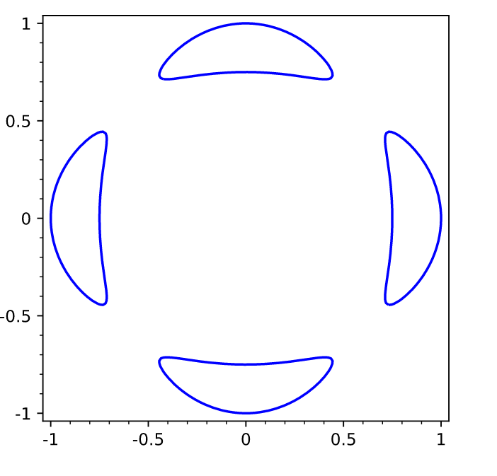

- $f_1 \cdot f_1 = 0$
- $f_1 \cdot f_2 = 1$
- $f_2 \cdot f_2 = 0$

This is because we can perturb these to be transverse:

[figure not shown]

Since $f_2 \cap f_2 ' = \emptyset$, we have $f_2 \cdot f_2' = f_2 \cdot f_2 = 0$, and similarly with 1. So the Gram matrix is
$$\begin{align*}
G =
\begin{bmatrix}
0 & 1
\\
1 & 0
\end{bmatrix}
.\end{align*}$$

So setting $C = {\mathbb{P}}^1 \times{\mathbb{P}}^1 = V(f_{2, 3})$, a function of bidegree $(2, 3)$, writing the coordinates as $[x: y], [z: w]$, we can write this as $x^2 z^3 + y^2 z^2 w + xy w^3 = 0$. We get
$$\begin{align*}
2g(C) - 2 = (K_{{\mathbb{P}}^1 \times{\mathbb{P}}^1} + 2f_1 + 3f_2) \cdot (2f_1 + 3f_2) = f_2 \cdot (2f_1 + 3f_2) = 2
,\end{align*}
since \(K_{{\mathbb{P}}^1} \circ = -2f_1 - 2f_2\) and so \(g(C) = 2\).$$

# 35 Friday, April 09

Recall that line bundles on ${\mathbb{CP}}^n$ were in bijection with ${\mathbb{Z}}$, where send $d$ to a bundle ${\mathcal{O}}(d) \mathrel{\vcenter{:}}={\mathcal{O}}_{{\mathbb{CP}}^N}(d)$. We produced the tautological line bundle ${\mathcal{O}}(-1)$ whose fiber over $\mathbf{x} \subseteq {\mathbb{CP}}^n$ is the line in ${\mathbb{C}}^n$ spanned by its coordinates. We have ${\mathcal{O}}(-1)^\vee\mathrel{\vcenter{:}}={\mathcal{O}}(1)$, and ${\mathcal{O}}(n)\mathrel{\vcenter{:}}={\mathcal{O}}(1)^{\otimes n}$. Alternatively, it was characterized in terms of homogeneous functions, where the fiber ${\mathcal{O}}(n)_{\mathbf{x}}$ are the linear functions $L$ on lines $\left\{{\lambda \mathbf{x}}\right\} \to {\mathbb{C}}$ such that $L(\lambda p) = \lambda^n L(p)$. Noting that these are linear functions, such $L$ form a 1-dimensional ${\mathbb{C}}{\hbox{-}}$vector space.

The classic example is $x_0 \in {\mathcal{O}}(1)_{\mathbf{x}}$ since $x_0( \lambda p) = \lambda x_0 (p)$. Similarly, $x_0^2 + x_1 x_2 \in {\mathcal{O}}(2)_{\mathbf{x}}$ since
$$\begin{align*}
x_0^2 + x_1 x_2 (\lambda p) = \lambda^2 (x_0^2 + x_1 x_2(p))
.\end{align*}$$

Note that the global sections were given by $\Gamma^0({\mathbb{P}}^n, {\mathcal{O}}(d)) = H^0({\mathbb{P}}^n; {\mathcal{O}}(d))$ was the span of degree $d$ monomials in $x_0, \cdots, x_n$. For example $x_0^2 + x_1 x_2$ is a well-defined element of ${\mathcal{O}}(2)_p$ which varies holomorphically with $p$, yielding a section:

[figure not shown]

For a K3 surface, consider $S = \left\{{ \sum_{i=0}^4 x_i^4 = 0 }\right\} \subset {\mathbb{CP}}^3$. By the adjunction formula,
$$\begin{align*}
K_S = { \left.{{\qty{ K_{{\mathbb{CP}}^3} \otimes{\mathcal{O}}_{{\mathbb{CP}}^3}(S) }}} \right|_{{S}} }
.\end{align*}
Note that if \(s\in H^0(\mathcal{L})\), we can recover \({\mathcal{O}}(\operatorname{Div}S) = \mathcal{L}\). Moreover, \(K_{{\mathbb{CP}}^3} = {\mathcal{O}}(-4)\) and \({\mathcal{O}}_{{\mathbb{CP}}^3}(S) = {\mathcal{O}}(4)\) since we can view the formula as a function on the tautological line, which yields a section. So we get \(K_S = {\mathcal{O}}(-4) \otimes{\mathcal{O}}(4) = {\mathcal{O}}(0) = {\mathcal{O}}\), i.e. these yield actual functions on \({\mathbb{CP}}^n\) since they’re products of functions that scale by \(\lambda^{-4}\) and functions that scale by \(\lambda^4\). We’re using the fact that \({\mathcal{O}}_{\mathbf{p} = [x_0: \cdots : x_n]}\) are functions \(L\) such that \(L(\lambda p) = \lambda^0 L(p) = L(p)\), which yields a well-defined function on \({\mathbb{CP}}^n\). So quartics in \({\mathbb{P}}^3\) have trivial canonical bundle, i.e. \(K_S = {\mathcal{O}}_S\) for \(S = V(x_0^4 + x_1^4 + x_2^4 + x_3^4)\).$$

We know that $H^o(S, K_S)$ are the globally holomorphic 2-forms on $S$, and here this is isomorphic to $H^0(S, {\mathcal{O}}_S) = {\mathbb{C}}\Omega_S$ for some single holomorphic 2-form. Moreover $\operatorname{Div}(\Omega_S) = 0$ since ${\mathcal{O}}( \operatorname{Div}( \Omega_S)) = K_S = {\mathcal{O}}_S$. So these are the analogs of elliptic curves in dimension 2, since for example $E \mathrel{\vcenter{:}}={\mathbb{C}}/ \Lambda$ has a nonvanishing section $\,dz\in H^0(E, K_E)$, and we can write $E = V(f)$ for $f$ a cubic in ${\mathbb{P}}^3$, and we computed the genus of cubics. Moreover, every genus 1 curve is ${\mathbb{C}}$ mod a lattice.

Recall an exercise from the notes: computing the Hodge diamond of a genus 5 curve. We’ll compute the diamond for a K3 surface:

[figure not shown]

> Link to Diagram

We know $h^{2, 0} = H^0( S, \Omega_S^2)$, which yields 1s:

[figure not shown]

> [Link to Diagram](https://q.uiver.app/?q=WzAsOSxbMiwwLCIxIl0sWzEsMSwiaF57MywgMX0iXSxbMywxLCJoXnsxLCAzfSJdLFswLDIsIjEiXSxbMiwyLCJoXnsxLCAxfSJdLFs0LDIsIjEiXSxbMSwzLCJoXnsxLCAwfSJdLFszLDMsImheezAsIDF9Il0sWzIsNCwiMSJdXQ==)

We’ll use the following theorem:

Let $X \subset {\mathbb{P}}^n$ with $\dim X > 3$. Then $\pi_1(X) \cong \pi_1(X \cap H)$ for $H$ a hypersurface intersection $X$ at a smooth codimension 1 complex manifold.

Applying this to $X = {\mathbb{P}}^3$, we have $V(x_0^4 + \cdots + x_3^4) = S$, we have $\pi_1({\mathbb{P}}^3) = \pi_1(S)$. We can write ${\mathbb{P}}^3 = {\mathbb{C}}\cup{\mathbb{C}}^2 \cup{\mathbb{C}}^4$, which is a cell decomposition with cells only in degrees 0,2,4, and so in fact $\pi_1({\mathbb{P}}^n) = 0$.

K3 surfaces are simply connected, and $h^1(S; {\mathbb{C}}) = 0$.

Note that anything embedded in projective space as a complex submanifold is Kähler by restricting the Fubini-Study form. Using simple connectedness and Serre duality, we have

[figure not shown]

> [Link to Diagram](https://q.uiver.app/?q=WzAsOSxbMiwwLCIxIl0sWzEsMSwiMCJdLFszLDEsIjAiXSxbMCwyLCIxIl0sWzIsMiwiaF57MSwgMX0iXSxbNCwyLCIxIl0sWzEsMywiMCJdLFszLDMsIjAiXSxbMiw0LCIxIl1d)

We know $\chi({\mathcal{O}}_S) = (1/12)(K^2+\chi_{\mathsf{Top}})$, and since $K_S = {\mathcal{O}}_S$ is trivial, we have $c_1({\mathcal{O}}_S) = 0$. Noting that $h^{p, q} = H^( \Omega^p)$, so we can sum the lower-right part of the diamond to get $\chi({\mathcal{O}}_S) = 1 - 0 + 1 = 2$, since we take $p=0$ to get $\Omega^p = {\mathcal{O}}$. Computing $\chi_{\mathsf{Top}}$, we get $h_{1, 1} = 20$.

# 36 Monday, April 12

Last time: the Lefschetz hyperplane theorem. Intersecting a projective variety of dimension $d\geq 3$ with a hypersurface $S$, the map $\pi_1({\mathbb{P}}^3) \to \pi_1(S)$ is an isomorphism. We saw that K3 surfaces were thus simply connected, and $h^1(S; {\mathbb{C}}) = 0$, so we could compute the Hodge diamond.

What is the Hodge diamond for a cubic surface $S \subseteq {\mathbb{P}}^3$, such as $\sum x_i^3 = 0$? We first need to compute the canonical bundle $K$, for which we have a useful tool: the adjunction formula. This say $K_S = \qty{K_{{\mathbb{P}}^3} \otimes{\mathbb{P}}_{{\mathbb{P}}^3}(S) } { \left.{{}} \right|_{{S}} } = \qty{ {\mathcal{O}}(-4) \otimes{\mathcal{O}}(3) }{ \left.{{}} \right|_{{S}} } = { \left.{{ {\mathcal{O}}(-1)}} \right|_{{S}} }$.

Let $\mathcal{L} \to X$ be a holomorphic line bundle. If $h^0( \mathcal{L} ^{-1}) > 0$, then either $\mathcal{L} = {\mathcal{O}}$ or $h^0(\mathcal{L}) = 0$.

If a line bundle has a section, its inverse does not.

Suppose that both $\mathcal{L}, \mathcal{L}^{-1}$ have a section, so $h^0(\mathcal{L}), h^0( \mathcal{L} ) > 0$. Let $s, t$ be sections of each, then $st\in H^0( \mathcal{L} \otimes\mathcal{L}^{-1}) = H^0({\mathcal{O}}) = {\mathbb{C}}$. So taking zero loci yields $\operatorname{Div}(s) + \operatorname{Div}(t) = 0$ Writing these as $\operatorname{Div}(s) \mathrel{\vcenter{:}}=\sum n_D D, \operatorname{Div}(t) \mathrel{\vcenter{:}}=\sum n_C C$, we have $n_D, n_C \geq 0$, which implies that $\operatorname{Div}(s) = \operatorname{Div}(t) = 0$. So $s, t$ are nowhere vanishing, making ${\mathcal{O}}\xrightarrow{\cdot s} \mathcal{L}$ is an isomorphism.

For $S$ a cubic surface, $H^0(S; K_S) = 0$.

This follows because $K_S = {\mathcal{O}}_S(-1)$, so $K_S^{-1}= {\mathcal{O}}_S(1)$ which has a nontrivial section: namely ${\mathcal{O}}_{{\mathbb{CP}}^1}(1)$ which has sections vanishing along hyperplanes.

[figure not shown]

Letting $H$ be a hyperplane containing $S$, there exists an $f\in H^0({\mathbb{P}}^3; {\mathcal{O}}_{{\mathbb{CP}}^3}(1))$. Since $\operatorname{Div}(f) = H$, the restriction ${ \left.{{f}} \right|_{{S}} }$ is a section of ${\mathcal{O}}_S(-1) = K_S^{-1}$ which is not identically zero and vanishes along $H \cap S$.

We now know $h^0(S; K_S) = 0$, and this equals $h^0(S, \Omega^2) = h^{2, 0}(S)$, so we have the following Hodge diamond:

[figure not shown]

> [Link to Diagram](https://q.uiver.app/?q=WzAsOSxbMiwwLCIxIl0sWzEsMSwiMCJdLFszLDEsIjAiXSxbMCwyLCIwIl0sWzIsMiwiaF57MSwgMX0iXSxbNCwyLCIwIl0sWzEsMywiMCJdLFszLDMsIjAiXSxbMiw0LCIxIl1d)

We have $h^{0, 1} + h^{1, 0} = h^1 = 0$ since $S$ is simply connected. We can now apply Noether’s formula as before: $\chi({\mathcal{O}}_S) = {1\over 12} (K_S^2 + \chi_{\mathsf{Top}}(S))$. We have $K_S = {\mathcal{O}}_S(-1)$, so $K_S^2 = c_1( {\mathcal{O}}(-1))^2$, and $\chi({\mathcal{O}}_S) = 1-0+1 = 1$. We now want to compute $\int_S \qty{- c_1({\mathcal{O}}_S(1)) }^2$. We know $c_1(\mathcal{L}) = [ \operatorname{Div}s]$ where $s\in H^0( \mathcal{L} )$ is a section of a line bundle. This equals $[H \cap S]$. On the other hand, $\int_S c_1 \qty{ {\mathcal{O}}_S(1)}^2$ is the self-intersection number of $H \cap S$.

Take $H_1 \mathrel{\vcenter{:}}=\left\{{ x_0 = 0 }\right\}$ and $H_2 \mathrel{\vcenter{:}}=\left\{{ x_1 = 0 }\right\}$. Points in this intersection are of the form $[0:0:1:\zeta_6^a]$ where $a=1,3,5$ since this is in the triple intersection $H_1 \cap H_2 \cap S$. So there are exactly 3 points here, and in fact $\deg S =3$. This is the same as integrating $\int_{{\mathbb{P}}^3} c_1(S) c_1( {\mathcal{O}}(1)) c_1( {\mathcal{O}}(2))$, which contains 3 elements in $H^2$ and lands in $H^6$, so this yields a number.

We thus have $K_S = {\mathcal{O}}_S(-1) \mathrel{\vcenter{:}}={\mathcal{O}}_{{\mathbb{CP}}^3}(-1) { \left.{{}} \right|_{{S}} }$. Thus $\chi_{\mathsf{Top}}(S) = 9$ and $h^{1, 1} = 7$.

Note that a degree 5 surface (a quintic) such as $x_0^5 + x_3^5 = 0$ would be harder, since $h^{2, 0} \neq 0$. We would get $K_S = {\mathcal{O}}(-4) \otimes{\mathcal{O}}(5) { \left.{{}} \right|_{{S}} } = {\mathcal{O}}_S(1)$, and there are nontrivial sections so $h^0(K_S) = {\operatorname{span}}{x_0, x_1, x_2, x_3}$. This follows because there is a map given by restriction which turns out to be an isomorphism
$$\begin{align*}
0 \to H^0({\mathbb{P}}^3; {\mathcal{O}}(1)) & \xrightarrow{\operatorname{res}_S} H^0(S; {\mathcal{O}}(1)) \to 0 \\
f &\mapsto { \left.{{f}} \right|_{{S}} }
.\end{align*}$$

Injectivity isn’t difficult, surjectivity is harder. We have a SES
$$\begin{align*}
0 \to {\mathcal{O}}_{{\mathbb{CP}}^3}(-S) \to {\mathcal{O}}_{{\mathbb{CP}}^3} \to {\mathcal{O}}_S \to 0
.\end{align*}
Tensor all of these with \({\mathcal{O}}(1)\) to obtain
\begin{align*}
0 \to {\mathcal{O}}_{\mathbb{CP}}^3(-4) \to {\mathcal{O}}_{{\mathbb{CP}}^3}(1) \to {\mathcal{O}}_S(1) \to 0
.\end{align*}
Taking the associated LES yields$$

[figure not shown]

> Link to Diagram

This gives us a way to relate things back to the cohomology of ${\mathbb{CP}}^3$. Showing that the indicated term is zero involves computing Čech cohomology.

It turns out that $h^0(K_S) = 4$ here, and it turns out that the Hodge diamond is the following:

[figure not shown]

> [Link to Diagram](https://q.uiver.app/?q=WzAsOSxbMiwwLCIxIl0sWzEsMSwiMCJdLFszLDEsIjAiXSxbMCwyLCI0Il0sWzQsMiwiNCJdLFsxLDMsIjAiXSxbMywzLCIwIl0sWzIsNCwiMSJdLFsyLDIsImheezEsIDF9ID0gNDUiXV0=)

Here $K_S^2 = c_1({\mathcal{O}}_S(1))^2 = 5$ and $\chi_{\mathsf{Top}}= 55$.

Consider now a product of curves $C \times D$ of genera $g, h$ respectively. Computing the Hodge diamond is easy here due to the Kunneth formula:
$$\begin{align*}
H^k(S; {\mathbb{C}}) = \bigoplus_{i+j = k} H^i(C; {\mathbb{C}}) \otimes H^j(D; {\mathbb{C}})
.\end{align*}$$

What is the actual map? Take cohomology classes $[\alpha], [\beta]$, closed $i$ and $j$ forms respectively. The surface has two maps:

[figure not shown]

Here we send $[\alpha] \otimes[ \beta] \mapsto [ \pi_C^* \alpha\wedge \pi_D^* \beta]$ where we take pullbacks. Note that $\pi_D, \pi_C$ are holomorphic maps, and pullbacks of $(p, q)$ forms are still $(p, q)$ forms. Thus the Kunneth formula gives a decomposition
$$\begin{align*}
H^{p, q}(S; {\mathbb{C}})
= \sum_{\substack{ i_1 + j_1 = p \\ i_2 + j_2 = q }} H^{i_1, j_1}(C) \oplus H^{i_2, j_2}(D)
.\end{align*}
So we can “tensor” the Hodge diamonds:$$

[figure not shown]

> Link to Diagram

Check out complete intersections.

# 37 Bibliography

1.

Salamon, D.: Spin geometry and seiberg-witten invariants. (1999)

2.

Mandelbaum, R.: Four-dimensional topology: An introduction. Bull. Amer. Math. Soc. (N.S.). 2, 1–159 (1980)

3.

Calegari, D.: Notes on 4-manifolds

4.

Rudyak, Y.: Piecewise linear structures on topological manifolds

5.

Matthew, A.: The dirac operator

6.

Weston, T.: An introduction to cobordism theory

[^1]: Note that this doesn’t start at $C^0$, so topological manifolds are genuinely different! There exist topological manifolds with no smooth structure.
[^2]: Locally admits a chart to ${\mathbb{C}}^n/ \Gamma$ for $\Gamma$ a finite group.
[^3]: Or more generally a finitely-generated ${\mathcal{O}}{\hbox{-}}$module, i.e. a coherent sheaf.
[^4]: So $X$ admits an embedding into some ${\mathbb{CP}}^N$.